# Wild Card Game Analysis

davegoblue

2023-01-15

## Introduction

This file explores card games that use a standard 52-card deck, optionally modified so that one or more cards are wild, as follows:

- One or more jokers may be added (the card has no natural rank or suit but may take on the most favorable)
- One or more natural cards may also be used as a wild (in deuces wild, the deuce has a natural suit and rank and can also take on the suit and rank of a more favorable card)

The analysis treats cards 1-52 as being the standard deck, with suits being 1-13, 14-26, 27-39, and 40-52. Counting the first card of each suit as 1, ranks are 1=Ace, 2-10=same card as value, 11=Jack, 12=Queen, 13=King. The Ace almost always plays as the highest rank, but can be treated as low for making a 5432A straight

## Methodology

### Basic Parameters

Several basic parameters of the game are established:

```r
library(tidyverse) # tidyverse functionality is included throughout
```

```r
source("./Generic_Added_Utility_Functions_202105_v001.R") # Basic functions

nCards <- 53 # This is a standard 52-card deck with a joker
nRanks <- 13 # There are 13 ranks A, 2-10, J, Q, K
nSuits <- 4 # There are four suits, each of 13 cards
perHand <- 5 # Number of cards drawn per hand
idxWild <- c(2, 15, 28, 41, 53) # The indices of the cards that can be considered wild (deuces and the joker)

# Check alignment of basic parameters
if(nSuits*nRanks > nCards) stop("\nerror, misaligned parameters for number of ranks, suits, and cards\n")
if(!isTRUE(setdiff(1:nCards, 1:(nRanks*nSuits)) %in% idxWild %>% reduce(.f=`&`)))
    stop("\nError, any cards outside the standard nRanks*nSuits must be included in idxWild\n")

# Announce the number of wild cards
cat("\nThe game will be played with a", nCards, "card deck with", length(idxWild), "cards considered wild")
```

```
##
## The game will be played with a 53 card deck with 5 cards considered wild
```

```r
cat("\nWild cards are of indices", paste0(idxWild, collapse=", "))
```

```
##
## Wild cards are of indices 2, 15, 28, 41, 53
```

```r
# Announce any cards of no suit or rank
if(!isTRUE(idxWild %in% 1:(nRanks*nSuits) %>% reduce(.f=`&`))) {
    cat("\nWilds with no natural rank or suit at indices:",
        paste0(idxWild[!(idxWild %in% 1:(nRanks*nSuits))], collapse=",")
        )
} else cat("\nAll wilds have a natural suit and rank")
```

```
##
## Wilds with no natural rank or suit at indices: 53
```

```r
# Announce wilds with natural ranks and suits
if(isTRUE(idxWild %in% 1:(nRanks*nSuits) %>% reduce(.f=`|`))) {
    tmpIdxWild <- idxWild[idxWild %in% 1:(nRanks*nSuits)]
    cat("\nWilds with natural rank and suit at indices:", paste0(tmpIdxWild, collapse=", "))
    cat("\nThese are of suit-independent rank", paste0((tmpIdxWild-1)%%nRanks+1, collapse=", "), "\n")
} else cat("\nNo wilds have a natural suit and rank\n")
```

```
##
## Wilds with natural rank and suit at indices: 2, 15, 28, 41
## These are of suit-independent rank 2, 2, 2, 2
```

All choose(nCards, perHand) combinations of hands are created based on index:

```r
startTime <- proc.time()


# Create a matrix of all possible hand indices
mtxHands <- t(combn(1:nCards, perHand))
str(mtxHands)
```

```
##  int [1:2869685, 1:5] 1 1 1 1 1 1 1 1 1 1 ...
```

```r
proc.time() - startTime
```

```
##    user  system elapsed
##    3.39    0.08    4.14
```

Hands are scored for their hand type, optionally using wilds. Functions are written:

```r
# Determine if a hand is a flush
isFlush <- function(suits, useWild=4) {
    apply(suits, 1, FUN=function(x) ifelse(min(x)==max(x), TRUE, (max(x[x!=useWild])==min(x[x!=useWild]))))
}

# Determine if a hand is a straight (hard-coded for 5-card hands in a 13-card deck, Ace high or low)
isStraight <- function(rankCounts, isEligible=TRUE) {
    # Exclusion matrix for straights, currently designed only for 13-card decks and A high or low
    strMatrix <- matrix(data=0L, nrow=13, ncol=10)
    strMatrix[c(1, 10, 11, 12, 13), 1] <- 1L
    for (intCtr in 1:9) { strMatrix[intCtr:(intCtr+4), intCtr+1] <- 1L }
    apply(rankCounts, 1, max)<=1 & rowSums(rankCounts%*%(strMatrix-1)==0)>=1 & isEligible
}

# Hard-coded for 52-card deck with 1 joker
findHandTypes <- function (aHands, retAll=FALSE) {

    # Track hands that contain the joker and total number of wilds
    aJoker <- rowSums(aHands==53)>0
    nWild <- aJoker + rowSums(aHands%%13==2)

    # 1. Calculate natural values
    # 1a. Calculate ranks and suits, counting the joker as having no "rank" and being of a fifth "suit"
    aRanks <- ifelse(aHands==53, 0, 1 + (aHands-1) %% 13)
    aSuits <- ifelse(aHands==53, 0, 1 + (aHands-1) %/% 13)

    # 1b. Find the counts by rank in each hand
    aRankCount <- matrix(data=-1L, nrow=nrow(aHands), ncol=13)
    for (intCtr in 1:13) { aRankCount[, intCtr] <- rowSums(aRanks == intCtr) }

    # 1c. Find the natural flushes and straights
    nFlush <- isFlush(aSuits, useWild=-1)
    nStraight <- isStraight(aRankCount, isEligible=!aJoker)

    # 1d. Find max and count of ranks
    nQuads <- rowSums(aRankCount == 4)
    nTrips <- rowSums(aRankCount == 3)
    nPairs <- rowSums(aRankCount == 2)

    # 1e. Score the natural hand values (default is that a hand has nothing of value)
    nType <- rep(0L, nrow(aHands))
    # Five wilds (cannot exist) <- 1
    nType[nFlush==1 & nStraight==1 & aRankCount[, 1]==1 & aRankCount[, 13]==1] <- 2 # Royal
    # Five of a kind (cannot exist as natural) <- 3
    nType[nFlush==1 & nStraight==1 & (aRankCount[, 1]!=1 | aRankCount[, 13]!=1)] <- 4 # Straight flush
    nType[nQuads==1] <- 5 # Four of a kind
    nType[nTrips==1 & nPairs==1] <- 6 # Full House
    nType[nFlush==1 & nStraight==0] <- 7 # Flush
    nType[nFlush==0 & nStraight==1] <- 8 # Straight
    nType[nTrips==1 & nPairs==0] <- 9 # Three of a Kind
    nType[nPairs==2] <- 10 # Two Pair
    nType[nTrips==0 & nPairs==1] <- 11 # Pair


    # 2. Calculate wild values
    # 2a. Calculate ranks and suits, counting the joker and 2's as having no "rank" and being of a fifth "suit"
    wRanks <- ifelse(aHands==53|(aHands%%13==2), 0, 1 + (aHands-1) %% 13)
    wSuits <- ifelse(aHands==53|(aHands%%13==2), 0, 1 + (aHands-1) %/% 13)

    # 2b. Find the counts by rank in each hand
    wRankCount <- matrix(data=-1L, nrow=nrow(aHands), ncol=13)
    for (intCtr in 1:13) { wRankCount[, intCtr] <- rowSums(wRanks == intCtr) }

    # 2c. Find the wild flushes and straights
    wFlush <- isFlush(wSuits, useWild=0)
    wStraight <- isStraight(wRankCount, isEligible=TRUE)

    # 2d. Find max and count of ranks
    wQuads <- rowSums(wRankCount == 4)
    wTrips <- rowSums(wRankCount == 3)
    wPairs <- rowSums(wRankCount == 2)

    # 2e. Score the wild hand values (default is that a hand has nothing of value)
    wType <- rep(0L, nrow(aHands))

    # 2e1. Calculate number of royal cards in hand
    nRoyal <- rowSums(wRankCount[, c(1, 10, 11, 12, 13)])

    # 2e2. Five wilds (always five wilds)
    wType[nWild==5] <- 1 # Five wild

    # 2e3. Four wilds (always either royal flush or five of a kind)
    wType[nWild==4 & nRoyal==1] <- 2 # Royal
    wType[nWild==4 & nRoyal==0] <- 3 # Five of a kind

    # 2e4. Three wilds (always either royal flush or five of a kind or straight flush or four of a kind)
    wType[nWild==3 & wFlush==1 & wStraight==1 & nRoyal==2] <- 2 # Royal
    wType[nWild==3 & wPairs==1] <- 3 # Five of a kind
    wType[nWild==3 & wFlush==1 & wStraight==1 & nRoyal<2] <- 4 # Straight Flush
    wType[nWild==3 & !(wFlush==1 & wStraight==1) & wPairs==0] <- 5 # Four of a kind

    # 2e5. Two wilds (always either royal, five of a kind, straight flush, four of a kind, flush, straight, trips)
    # Cannot be a full house as any 3-2 using two wilds could instead be 5-0 or 1-4 and thus a better hand
    wType[nWild==2 & wFlush==1 & wStraight==1 & nRoyal==3] <- 2 # Royal
    wType[nWild==2 & wTrips==1] <- 3 # Five of a kind
    wType[nWild==2 & wFlush==1 & wStraight==1 & nRoyal<3] <- 4 # Straight Flush
    wType[nWild==2 & wPairs==1] <- 5 # Four of a kind
    wType[nWild==2 & wFlush==1 & wStraight==0] <- 7 # Flush
    wType[nWild==2 & wFlush==0 & wStraight==1] <- 8 # Straight
    wType[nWild==2 & !(wFlush==1 | wStraight==1) & wPairs==0 & wTrips==0] <- 9 # Three of a kind

    # 2e6. One wild (can be anything from pair to royal, with the exception of never two pair)
    wType[nWild==1 & wFlush==1 & wStraight==1 & nRoyal==4] <- 2 # Royal
    wType[nWild==1 & wQuads==1] <- 3 # Five of a kind
    wType[nWild==1 & wFlush==1 & wStraight==1 & nRoyal<4] <- 4 # Straight Flush
    wType[nWild==1 & wTrips==1] <- 5 # Four of a kind
    wType[nWild==1 & wPairs==2] <- 6 # Full House
    wType[nWild==1 & wFlush==1 & wStraight==0] <- 7 # Flush
    wType[nWild==1 & wFlush==0 & wStraight==1] <- 8 # Straight
    wType[nWild==1 & wPairs==1] <- 9 # Three of a kind
    wType[nWild==1 & !(wFlush==1 | wStraight==1) & wPairs==0 & wTrips==0 & wQuads==0] <- 11 # Pair

    # 2e7. No wild (is identical to natural)
    wType[nWild==0] <- nType[nWild==0]

    # Return the requested data
    if (isTRUE(retAll)) {
        list(nType=nType,
             wType=wType,
             nWild=nWild,
             wRankCount=wRankCount,
             aRankCount=aRankCount
             )
    } else {
        list(nType=nType, wType=wType, nWild=nWild)
    }

}
```

```r
# Calculate hands
tmpTime <- proc.time(); tmpHandTypes<-findHandTypes(mtxHands, retAll=TRUE); proc.time()-tmpTime
```

```
##    user  system elapsed
##   66.01    4.00   70.33
```

Hand types are evaluated:

```r
# Create tibble
tblAllTypes <- tibble::tibble(wType=tmpHandTypes$wType,
                              nType=tmpHandTypes$nType,
                              nWild=tmpHandTypes$nWild
                              ) %>%
    mutate(wType=ifelse(wType==0, 99, wType),
           nType=ifelse(nType==0, 99, nType)
           )
tblAllTypes
```

```
## # A tibble: 2,869,685 × 3
##    wType nType nWild
##    <dbl> <dbl> <dbl>
##  1     4     4     1
##  2     7     7     1
##  3     7     7     1
##  4     7     7     1
##  5     7     7     1
##  6     7     7     1
##  7     7     7     1
##  8     7     7     1
##  9     7     7     1
## 10     9    11     1
## # … with 2,869,675 more rows
```

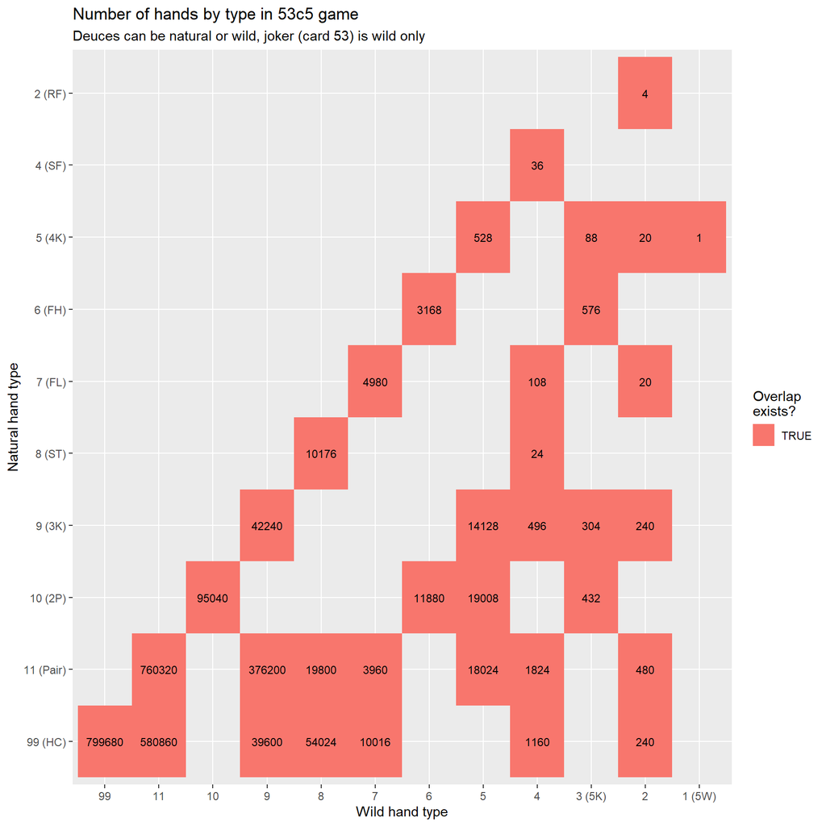

```r
# Plot the overlaps
tblAllTypes %>%
    count(wType, nType) %>%
    mutate(wType=ifelse(wType %in% c(1, 3), case_when(wType==3 ~ "3 (5K)", wType==1 ~ "1 (5W)"), wType),
           nType=case_when(nType==2 ~ "2 (RF)", nType==4 ~ "4 (SF)", nType==5 ~ "5 (4K)", nType==6 ~ "6 (FH)",
                           nType==7 ~ "7 (FL)", nType==8 ~ "8 (ST)", nType==9 ~ "9 (3K)", nType==10 ~ "10 (2P)",
                           nType==11 ~ "11 (Pair)", nType==99 ~ "99 (HC)", TRUE ~ "Error"
                           )
           ) %>%
    mutate(wType=factor(wType,
                        levels=c("99", "11", "10", "9", "8", "7", "6", "5", "4", "3 (5K)", "2", "1 (5W)")
                        ),
           nType=factor(nType,
                        levels=c("99 (HC)", "11 (Pair)", "10 (2P)", "9 (3K)", "8 (ST)", "7 (FL)",
                                 "6 (FH)", "5 (4K)", "4 (SF)", "2 (RF)"
                                 )
                        )
           ) %>%
    ggplot(aes(x=wType, y=nType)) +
    geom_tile(aes(fill=(n>0))) +
    geom_text(aes(label=n), size=3) +
    scale_fill_discrete("Overlap\nexists?") +
    labs(title="Number of hands by type in 53c5 game",
         subtitle="Deuces can be natural or wild, joker (card 53) is wild only",
         y="Natural hand type",
         x="Wild hand type"
         )
```

Hands can be scored based on a paytable for both wild-type hands and natural-type hands (only the highest payout applies). An example from the game “DJ Wild” is assessed:

```r
# Hand values
handValues <- tibble::tibble(handRank=c(1:11, 99),
                             handDesc=c("5W", "RF", "5K", "SF", "4K", "FH", "FL", "ST", "3K", "2P", "1P", "HC"),
                             handLabel=paste0(handRank, " (", handDesc, ")"),
                             blindPay=c(2000, 100, 40, 25, 5, 4, 3, 2, 0, 0, 0, 0),
                             wildPay=c(2000, 90, 70, 25, 6, 5, 4, 3, 1, -1, -1, -1),
                             naturalPay=c(NA, 1000, NA, 200, 60, 30, 25, 20, 6, -1, -1, -1)
                             )
handValues
```

```
## # A tibble: 12 × 6
##    handRank handDesc handLabel blindPay wildPay naturalPay
##       <dbl> <chr>    <chr>        <dbl>   <dbl>      <dbl>
##  1        1 5W       1 (5W)        2000    2000         NA
##  2        2 RF       2 (RF)         100      90       1000
##  3        3 5K       3 (5K)          40      70         NA
##  4        4 SF       4 (SF)          25      25        200
##  5        5 4K       5 (4K)           5       6         60
##  6        6 FH       6 (FH)           4       5         30
##  7        7 FL       7 (FL)           3       4         25
##  8        8 ST       8 (ST)           2       3         20
##  9        9 3K       9 (3K)           0       1          6
## 10       10 2P       10 (2P)          0      -1         -1
## 11       11 1P       11 (1P)          0      -1         -1
## 12       99 HC       99 (HC)          0      -1         -1
```

```r
# Create a mapping vector for type to description
vecMapHands <- handValues$handLabel %>% purrr::set_names(handValues$handRank)

# Payout grid plotted for all possible values
allValueGrid <- expand.grid(wildType=c(1:11, 99), naturalType=c(1:11, 99)) %>%
    tibble::tibble() %>%
    full_join(count(tblAllTypes, wType, nType), by=c("wildType"="wType", "naturalType"="nType")) %>%
    mutate(bestType=pmin(wildType, naturalType)) %>%
    left_join(select(handValues, handRank, wildPay), by=c("wildType"="handRank")) %>%
    left_join(select(handValues, handRank, naturalPay), by=c("naturalType"="handRank")) %>%
    left_join(select(handValues, handRank, blindPay), by=c("bestType"="handRank")) %>%
    mutate(bonusPay=pmax(wildPay, naturalPay, na.rm=TRUE))
allValueGrid
```

```
## # A tibble: 144 × 8
##    wildType naturalType     n bestType wildPay naturalPay blindPay bonusPay
##       <dbl>       <dbl> <int>    <dbl>   <dbl>      <dbl>    <dbl>    <dbl>
##  1        1           1    NA        1    2000         NA     2000     2000
##  2        2           1    NA        1      90         NA     2000       90
##  3        3           1    NA        1      70         NA     2000       70
##  4        4           1    NA        1      25         NA     2000       25
##  5        5           1    NA        1       6         NA     2000        6
##  6        6           1    NA        1       5         NA     2000        5
##  7        7           1    NA        1       4         NA     2000        4
##  8        8           1    NA        1       3         NA     2000        3
##  9        9           1    NA        1       1         NA     2000        1
## 10       10           1    NA        1      -1         NA     2000       -1
## # … with 134 more rows
```

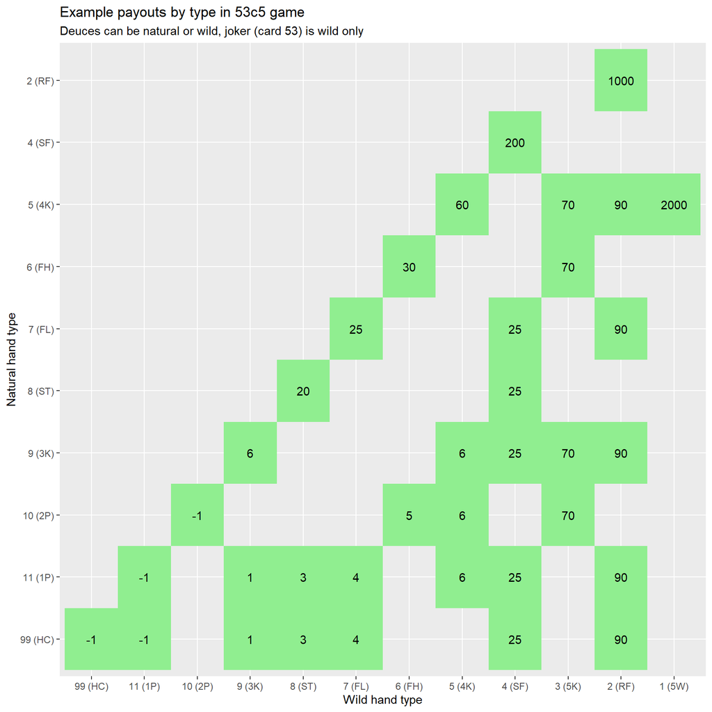

```r
# Plot of payout values
allValueGrid %>%
    filter(!is.na(n)) %>%
    ggplot(aes(x=fct_rev(factor(vecMapHands[as.character(wildType)], levels=vecMapHands)),
               y=fct_rev(factor(vecMapHands[as.character(naturalType)], levels=vecMapHands))
               )
           ) +
    geom_tile(fill="lightgreen") +
    geom_text(aes(label=bonusPay)) +
    labs(title="Example payouts by type in 53c5 game",
         subtitle="Deuces can be natural or wild, joker (card 53) is wild only",
         y="Natural hand type",
         x="Wild hand type"
         )
```

```r
# EV of payout values
allValueGrid %>%
    filter(!is.na(n)) %>%
    summarize(totPays=sum(n*bonusPay), n=sum(n)) %>%
    mutate(ev=totPays/n)
```

```
## # A tibble: 1 × 3
##   totPays       n      ev
##     <dbl>   <int>   <dbl>
## 1 -176684 2869685 -0.0616
```

```r
# Table by hand type
allValueTable <- allValueGrid %>%
    filter(!is.na(n)) %>%
    mutate(natWild=ifelse(naturalPay>wildPay, "Natural", "Wild"),
           reportBonusType=ifelse(natWild=="Natural", naturalType, wildType),
           reportBonusLabel=factor(vecMapHands[as.character(reportBonusType)], levels=vecMapHands)
           ) %>%
    group_by(natWild, reportBonusLabel, bonusPay) %>%
    summarize(n=sum(n), .groups="drop") %>%
    mutate(prob=n/sum(n), per=1/prob, ev=n*bonusPay/sum(n))
allValueTable
```

```
## # A tibble: 19 × 7
##    natWild reportBonusLabel bonusPay       n        prob        per        ev
##    <chr>   <fct>               <dbl>   <int>       <dbl>      <dbl>     <dbl>
##  1 Natural 2 (RF)               1000       4 0.00000139   717421.    0.00139
##  2 Natural 4 (SF)                200      36 0.0000125     79713.    0.00251
##  3 Natural 5 (4K)                 60     528 0.000184       5435.    0.0110
##  4 Natural 6 (FH)                 30    3168 0.00110         906.    0.0331
##  5 Natural 7 (FL)                 25    4980 0.00174         576.    0.0434
##  6 Natural 8 (ST)                 20   10176 0.00355         282.    0.0709
##  7 Natural 9 (3K)                  6   42240 0.0147           67.9   0.0883
##  8 Wild    1 (5W)               2000       1 0.000000348 2869685     0.000697
##  9 Wild    2 (RF)                 90    1000 0.000348       2870.    0.0314
## 10 Wild    3 (5K)                 70    1400 0.000488       2050.    0.0342
## 11 Wild    4 (SF)                 25    3612 0.00126         794.    0.0315
## 12 Wild    5 (4K)                  6   51160 0.0178           56.1   0.107
## 13 Wild    6 (FH)                  5   11880 0.00414         242.    0.0207
## 14 Wild    7 (FL)                  4   13976 0.00487         205.    0.0195
## 15 Wild    8 (ST)                  3   73824 0.0257           38.9   0.0772
## 16 Wild    9 (3K)                  1  415800 0.145             6.90  0.145
## 17 Wild    10 (2P)                -1   95040 0.0331           30.2  -0.0331
## 18 Wild    11 (1P)                -1 1341180 0.467             2.14 -0.467
## 19 Wild    99 (HC)                -1  799680 0.279             3.59 -0.279
```

```r
allValueTable %>% select(n, ev) %>% colSums() %>% round(4)
```

```
##            n           ev
## 2869685.0000      -0.0616
```

Convert all hands to a value with ranks for tie-breaking (Ace high, with 5432A straights treated as having first tie-breaker 5 and last tie-breaker A). Hands are first converted to counts by rank with wild cards filling the next best ranks:

```r
# Get the number of wilds in each hand
perHandNWild <- (rowSums(mtxHands==53)>0) + rowSums(mtxHands%%13==2)

# Get the ranks in each hand
perHandRanks <- ifelse(mtxHands==53, 0, 1 + (mtxHands-1) %% 13) # track joker as wild
perHandRanks[perHandRanks==2] <- 0 # track deuces as wild, ignore rank (place as best later)
perHandRanks[perHandRanks==1] <- 14 # count Aces as high

# Create the matrix of card types
perHandRankCount <- matrix(data=-1L, nrow=nrow(mtxHands), ncol=14)
for (intCtr in 1:14) { perHandRankCount[, intCtr] <- rowSums(perHandRanks == intCtr) }

# Create a tie-breaker matrix filled with 0's (column 13 is Ace)
mtxTieBreak <- matrix(data=0L, nrow=nrow(mtxHands), ncol=13)

# Function to get the cards in a straight
getStraightType <- function(x) {
    if(min(x[x>0]) >= 10) c(10, 11, 12, 13, 14)
    else if(min(x[x>0]) <= 5 & max(x)==14) c(2, 3, 4, 5, 14) # this treats Ace as the last card to resolve (Ace low)
    else seq(min(x[x>0]), min(x[x>0])+4)
}

# Function to get the cards in a flush
getFlushType <- function(x) {
    # Wild cards should be added as highest rank not already in hand (try A then K then Q then J then T)
    numAdd <- sum(x==0)
    if(numAdd > 0) {
        notThere <- (14:10)[!((14:10) %in% x)][1:numAdd]
        x <- c(x[x!=0], notThere)
    }
    sort(x, decreasing=TRUE)
}

# Function to get the cards in a four of a kind, full house, three of a kind, two pair, pair, or high card
getHighTypes <- function(rks, idx=1:14, outNum=c(1, 1, 1, 1, 1)) {
    vecOut <- rep(0L, length(outNum))
    for(x in seq_along(outNum)) {
        vecOut[x]<-max((rks==max(rks)) * idx)
        rks[match(vecOut[x], idx)] <- 0
    }
    rep(vecOut, times=outNum)
}

# 1. Five wild (nothing to do)
# 2. Royal flush (make the ranks 1 in the last 5 columns)
perHandRanks[tmpHandTypes$wType==2, ] <- t(apply(perHandRanks[tmpHandTypes$wType==2, ], 1, FUN=getStraightType))
# 3. Five of a kind (make the ranks all the same as the only rank)
perHandRanks[tmpHandTypes$wType==3, ] <- t(apply(perHandRankCount[tmpHandTypes$wType==3, ],
                                           1,
                                           FUN=getHighTypes,
                                           outNum=c(5)
                                           )
                                     )
# 4. Straight flush (make the ranks all the best straight possible)
perHandRanks[tmpHandTypes$wType==4, ] <- t(apply(perHandRanks[tmpHandTypes$wType==4, ], 1, FUN=getStraightType))
# 5. Four of a kind (make the ranks four of the most frequent card or the highest card, one of the other)
perHandRanks[tmpHandTypes$wType==5, ] <- t(apply(perHandRankCount[tmpHandTypes$wType==5, ],
                                           1,
                                           FUN=getHighTypes,
                                           outNum=c(4, 1)
                                           )
                                     )
# 6. Full house (make the ranks three of the most frequent card, two of the other)
perHandRanks[tmpHandTypes$wType==6, ] <- t(apply(perHandRankCount[tmpHandTypes$wType==6, ],
                                           1,
                                           FUN=getHighTypes,
                                           outNum=c(3, 2)
                                           )
                                     )
# 7. Flush (need to implement)
perHandRanks[tmpHandTypes$wType==7, ] <- t(apply(perHandRanks[tmpHandTypes$wType==7, ], 1, FUN=getFlushType))
# 8. Straight (make the ranks all the best straight possible)
perHandRanks[tmpHandTypes$wType==8, ] <- t(apply(perHandRanks[tmpHandTypes$wType==8, ], 1, FUN=getStraightType))
# 9. Three of a kind (make the ranks three of the most frequent or highest card, one each of the other)
perHandRanks[tmpHandTypes$wType==9, ] <- t(apply(perHandRankCount[tmpHandTypes$wType==9, ],
                                           1,
                                           FUN=getHighTypes,
                                           outNum=c(3, 1, 1)
                                           )
                                     )
# 10. Two pair (make the ranks two of the highest pair, two of the lowest pair, one of the remainder)
perHandRanks[tmpHandTypes$wType==10, ] <- t(apply(perHandRankCount[tmpHandTypes$wType==10, ],
                                            1,
                                            FUN=getHighTypes,
                                            outNum=c(2, 2, 1)
                                            )
                                      )
# 11. One pair (make the ranks two of the pair or highest card, one each of the remainder)
perHandRanks[tmpHandTypes$wType==11, ] <- t(apply(perHandRankCount[tmpHandTypes$wType==11, ],
                                            1,
                                            FUN=getHighTypes,
                                            outNum=c(2, 1, 1, 1)
                                            )
                                      )
# 0. High card (make the ranks in order of the highest cards)
perHandRanks[tmpHandTypes$wType==0, ] <- t(apply(perHandRankCount[tmpHandTypes$wType==0, ],
                                            1,
                                            FUN=getHighTypes,
                                            outNum=c(1, 1, 1, 1, 1)
                                            )
                                      )

# Create the hand ranking table
allHandRanks <- tibble::tibble(handNum=1:nrow(mtxHands), wType=tmpHandTypes$wType) %>%
    bind_cols(perHandRanks) %>%
    set_names(c("handNum", "wType", "tb1", "tb2", "tb3", "tb4", "tb5")) %>%
    mutate(wType=ifelse(wType==0, 99, wType)) %>%
    arrange(wType, desc(tb1), desc(tb2), desc(tb3), desc(tb4), desc(tb5)) %>%
    mutate(chgRank=ifelse(row_number()==1 | wType!=lag(wType) | tb1 != lag(tb1) | tb2 != lag(tb2) | tb3 != lag(tb3) | tb4 != lag(tb4) | tb5 != lag(tb5), 1, 0),
           rank=cumsum(chgRank)
           )
allHandRanks %>%
    count(wType, rank, tb1, tb2, tb3, tb4, tb5) %>%
    arrange(-n, rank) %>%
    mutate(nvr=row_number()) %>%
    group_by(wType) %>%
    mutate(nty=row_number()) %>%
    ungroup() %>%
    filter(nvr<=10 | nty==1)
```

```
## # A tibble: 20 × 10
##    wType  rank   tb1   tb2   tb3   tb4   tb5     n   nvr   nty
##    <dbl> <dbl> <dbl> <dbl> <dbl> <dbl> <dbl> <int> <int> <int>
##  1     8  1071    10    11    12    13    14 13320     1     1
##  2     8  1072     9    10    11    12    13  9660     2     2
##  3     8  1073     8     9    10    11    12  9660     3     3
##  4     8  1074     7     8     9    10    11  9660     4     4
##  5     8  1075     6     7     8     9    10  9660     5     5
##  6     8  1076     5     6     7     8     9  9660     6     6
##  7     8  1077     4     5     6     7     8  9660     7     7
##  8     8  1078     3     4     5     6     7  9660     8     8
##  9     8  1079     2     3     4     5    14  3060     9     9
## 10    11  2402    14    14    13    12     9  1644    10     1
## 11     9  1083    14    14    14    13     9  1144   471     1
## 12    99  4380    14    13    12    11     9  1020   636     1
## 13     2     2    10    11    12    13    14  1004  1420     1
## 14     4    15     9    10    11    12    13   484  1916     1
## 15     5    27    14    14    14    14     9   484  1923     1
## 16     7   289    14    13    12    11     7   324  3574     1
## 17     6   155    14    14    14    13    13   204  3581     1
## 18    10  1740    14    14    13    13    12   144  3675     1
## 19     3     8     9     9     9     9     9   125  4335     1
## 20     1     1     0     0     0     0     0     1  5163     1
```

As expected, straight is the hand type with the greatest number of possible ties (there are only 10 types of straight and each can have 1,024 permutations of suits)

A function is written to assess probabilities associated with any given hand:

```r
# Sort allHandRanks and ensure handNum and row_number() match
sortedHandRanks <- allHandRanks %>%
    mutate(qual=ifelse(wType<=11, "Q", "N")) %>%
    arrange(handNum)
if (sum((sortedHandRanks$handNum) != (1:nrow(sortedHandRanks)))>0)
    stop("\nError in handNum order in sortedHandRanks\n")

# Function to get probabilities
findHandProbs <- function(exRank, idxExclude=NULL, df=sortedHandRanks) {
    rkData <- if(is.null(idxExclude)) df$rank else df$rank[-idxExclude]
    qualData <- if(is.null(idxExclude)) df$qual else df$qual[-idxExclude]
    pLN <- mean(rkData < exRank & qualData=="N")
    pLQ <- mean(rkData < exRank & qualData=="Q")
    pTN <- mean(rkData == exRank & qualData=="N")
    pTQ <- mean(rkData == exRank & qualData=="Q")
    pWN <- mean(rkData > exRank & qualData=="N")
    pWQ <- mean(rkData > exRank & qualData=="Q")
    pWNoTie <- (pWN+pWQ)/(1-pTN-pTQ)
    c(pLN=pLN, pLQ=pLQ, pTN=pTN, pTQ=pTQ, pWN=pWN, pWQ=pWQ, pWNoTie=pWNoTie)
}

# Example hand index
exHandNum <- 123456
exHandRank <- sortedHandRanks$rank[exHandNum]
cat("\nExample hand",
    exHandNum,
    "is of type",
    sortedHandRanks$wType[exHandNum],
    "and rank",
    exHandRank,
    "with cards",
    mtxHands[exHandNum,],
    "\n"
    )
```

```
##
## Example hand 123456 is of type 99 and rank 4509 with cards 1 9 11 44 51
```

```r
res <- findHandProbs(exHandRank)
cat("Associated probabilities (if cards in example hand available to replay):",
    "\nLoss: ", res["pLN"]+res["pLQ"],
    "\nTie: ", res["pTN"]+res["pTQ"],
    "\nWin (no qualify): ", res["pWN"],
    "\nWin (qualify): ", res["pWQ"],
    "\nWin (excluding ties):", res["pWNoTie"],
    "\np(dealer qualifies):", res["pLQ"]+res["pTQ"]+res["pWQ"],
    "\nOptimal action: ", ifelse(res["pWNoTie"]<0.25, "Fold", ifelse(res["pWNoTie"]<=0.5, "Single", "Double")),
    "\n"
    )
```

```
## Associated probabilities (if cards in example hand available to replay):
## Loss:  0.767187
## Tie:  0.0003554397
## Win (no qualify):  0.2324576
## Win (qualify):  0
## Win (excluding ties): 0.2325402
## p(dealer qualifies): 0.7213353
## Optimal action:  Fold
```

The function is run excluding unavailable cards (e.g., none of a player’s cards can appear in the dealer’s hand). First, a list of exclusions is generated:

```r
# Get all exclusion indices once
cardInHand <- lapply(1:53, FUN=function(x) which(rowSums(mtxHands==x)>0))
```

Then, the function is written and applied to the example hand:

```r
# Function to get key values
getKeyValues <- function(keyRank, exclCards=c(), lstExclude=cardInHand, dfSort=sortedHandRanks) {

    # Get the union of exclusions
    if(length(exclCards)==0) exclHands<-c()
    else exclHands <- purrr::reduce(.x=lstExclude[c(exclCards)], .f=union)

    dfSort %>%
        filter(!(handNum %in% exclHands)) %>%
        summarize(pLQ=mean(qual=="Q" & rank<keyRank),
                  pLN=mean(qual=="N" & rank<keyRank),
                  pTQ=mean(qual=="Q" & rank==keyRank),
                  pTN=mean(qual=="N" & rank==keyRank),
                  pWQ=mean(qual=="Q" & rank>keyRank),
                  pWN=mean(qual=="N" & rank>keyRank),
                  n=n()
                  ) %>%
        mutate(pWNoTie=(pWQ+pWN)/(1-pTQ-pTN), rank=keyRank)

}

smallSorted <- sortedHandRanks %>% select(handNum, rank, qual)

# Heads up probabilities
t <- proc.time(); getKeyValues(exHandRank, exclCards=mtxHands[exHandNum,], dfSort=smallSorted); proc.time() - t
```

```
## # A tibble: 1 × 9
##     pLQ    pLN   pTQ      pTN   pWQ   pWN       n pWNoTie  rank
##   <dbl>  <dbl> <dbl>    <dbl> <dbl> <dbl>   <int>   <dbl> <dbl>
## 1 0.735 0.0408     0 0.000141     0 0.224 1712304   0.224  4509
```

```
##    user  system elapsed
##    1.15    0.29    1.47
```

```r
# Heads up probabilities, dealer does not have a wild card
t <- proc.time()
getKeyValues(exHandRank, exclCards=unique(c(mtxHands[exHandNum,], 2, 15, 28, 41, 53)), dfSort=smallSorted)
```

```
## # A tibble: 1 × 9
##     pLQ    pLN   pTQ      pTN   pWQ   pWN      n pWNoTie  rank
##   <dbl>  <dbl> <dbl>    <dbl> <dbl> <dbl>  <int>   <dbl> <dbl>
## 1 0.529 0.0725     0 0.000250     0 0.398 962598   0.398  4509
```

```r
proc.time() - t
```

```
##    user  system elapsed
##    0.93    0.11    1.03
```

As expected, probabilities change slightly due to cards made unavailable (in player’s hands or otherwise). Wild cards are very important in expected value of hand quality

A function is added to run multiple hands:

```r
# Blind payouts
blindPay <- c(2000, 100, 40, 25, 5, 4, 3, 2, 0, 0, 0, 0) %>% purrr::set_names(paste0("b_", c(1:11, 99)))

# Add number of wilds
sortedHandRanks <- sortedHandRanks %>%
    mutate(nWild=perHandNWild)

calculateResults <- function(useHandNums, dfRanks=sortedHandRanks, hands=mtxHands, bPay=blindPay) {

    map_dfr(useHandNums,
            .f=function(x) {
                getKeyValues(keyRank=dfRanks$rank[x], exclCards=as.vector(hands[x,])) %>%
                    mutate(type=dfRanks$wType[x],
                           handNum=x,
                           betPlay=ifelse((4*pWQ+3*pWN+2*pTQ+2*pTN)<(pLQ+pLN), 0, ifelse(pWNoTie<0.5, 1, 2)),
                           evAnte=ifelse(betPlay==0, -1, pWQ-pLQ-pLN),
                           evPlay=betPlay*(pWQ+pWN-pLQ-pLN),
                           evBlind=ifelse(betPlay==0, -1, bPay[paste0("b_", type)]*(pWQ+pWN)-pLQ-pLN),
                           evAll=evAnte+evPlay+evBlind
                           )
                }
            )
}
```

```r
# Run for example hand of all hand types 4 (straight flush) or better
seq1a <- sortedHandRanks %>%
    filter(wType <= 4) %>%
    group_by(nWild, wType, tb1, tb2, tb3, tb4, tb5) %>%
    filter(row_number()==1) %>%
    ungroup()

# Run for select hands
t <- proc.time(); resSFPlus <- calculateResults(useHandNums=seq1a$handNum); proc.time()-t
```

```
##    user  system elapsed
##   46.34   11.69   64.90
```

```r
# Statistics for EV by hand type
resSFPlus %>%
    group_by(type) %>%
    summarize(n=n(), across(c(pWNoTie, evAll), .fns=list(min=min, mean=mean, med=median, max=max)))
```

```
## # A tibble: 4 × 10
##    type     n pWNoTie_…¹ pWNoT…² pWNoT…³ pWNoT…⁴ evAll…⁵ evAll…⁶ evAll…⁷ evAll…⁸
##   <dbl> <int>      <dbl>   <dbl>   <dbl>   <dbl>   <dbl>   <dbl>   <dbl>   <dbl>
## 1     1     1      1       1       1        1     2003.   2003.   2003.   2003.
## 2     2     5      1.00    1.00    1        1      103.    103.    103.    103.
## 3     3    43      0.999   1.00    1.00     1.00    42.6    42.7    42.7    42.7
## 4     4    31      0.997   0.999   0.999    1.00    27.6    27.7    27.7    27.7
## # … with abbreviated variable names ¹pWNoTie_min, ²pWNoTie_mean, ³pWNoTie_med,
## #   ⁴pWNoTie_max, ⁵evAll_min, ⁶evAll_mean, ⁷evAll_med, ⁸evAll_max
```

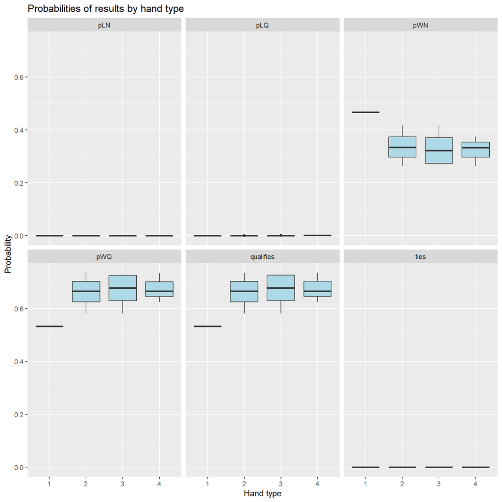

```r
# Plot for result type
resSFPlus %>%
    mutate(qualifies=pWQ+pTQ+pLQ, ties=pTQ+pTN) %>%
    select(handNum, type, pWQ, pWN, pLQ, pLN, ties, qualifies) %>%
    pivot_longer(-c(handNum, type)) %>%
    ggplot(aes(x=factor(type), y=value)) +
    geom_boxplot(fill="lightblue") +
    facet_wrap(~name) +
    labs(title="Probabilities of results by hand type", x="Hand type", y="Probability")
```

```r
# Run for example hand of all hand types 5-8 (4K thru straight) or better
seq1b <- sortedHandRanks %>%
    filter(wType <= 8 & wType >= 5) %>%
    group_by(nWild, wType, tb1, tb2, tb3, tb4, tb5) %>%
    filter(row_number()==1) %>%
    ungroup()

# Run for select hands
t <- proc.time(); resSTto4K <- calculateResults(useHandNums=seq1b$handNum); proc.time()-t
```

```
##    user  system elapsed
##  934.98  243.20 1263.75
```

```r
# Statistics for EV by hand type
resSTto4K %>%
    group_by(type) %>%
    summarize(n=n(), across(c(pWNoTie, evAll), .fns=list(min=min, mean=mean, med=median, max=max)))
```

```
## # A tibble: 4 × 10
##    type     n pWNoTie_…¹ pWNoT…² pWNoT…³ pWNoT…⁴ evAll…⁵ evAll…⁶ evAll…⁷ evAll…⁸
##   <dbl> <int>      <dbl>   <dbl>   <dbl>   <dbl>   <dbl>   <dbl>   <dbl>   <dbl>
## 1     5   462      0.974   0.991   0.993   1.00     7.44    7.60    7.60    7.73
## 2     6   198      0.968   0.974   0.972   0.984    6.40    6.45    6.44    6.53
## 3     7  1173      0.962   0.968   0.964   0.987    5.36    5.41    5.38    5.53
## 4     8    26      0.931   0.960   0.961   0.982    4.10    4.33    4.34    4.49
## # … with abbreviated variable names ¹pWNoTie_min, ²pWNoTie_mean, ³pWNoTie_med,
## #   ⁴pWNoTie_max, ⁵evAll_min, ⁶evAll_mean, ⁷evAll_med, ⁸evAll_max
```

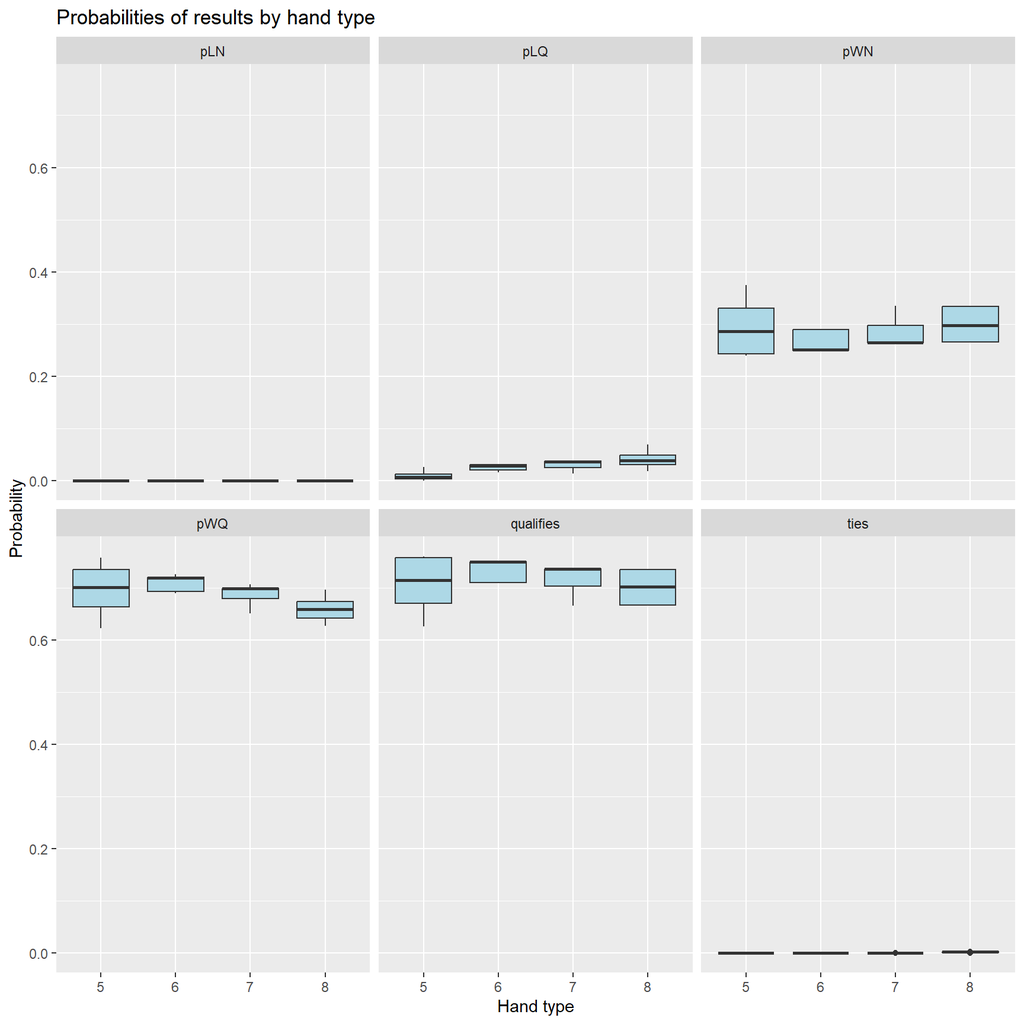

```r
# Plot for result type
resSTto4K %>%
    mutate(qualifies=pWQ+pTQ+pLQ, ties=pTQ+pTN) %>%
    select(handNum, type, pWQ, pWN, pLQ, pLN, ties, qualifies) %>%
    pivot_longer(-c(handNum, type)) %>%
    ggplot(aes(x=factor(type), y=value)) +
    geom_boxplot(fill="lightblue") +
    facet_wrap(~name) +
    labs(title="Probabilities of results by hand type", x="Hand type", y="Probability")
```

```r
# Run for example hand of all hand types 9-10 (3K thru 2P)
seq1c <- sortedHandRanks %>%
    filter(wType <= 10 & wType >= 9) %>%
    group_by(nWild, wType, tb1, tb2, tb3, tb4, tb5) %>%
    filter(row_number()==1) %>%
    ungroup()

# Run for select hands
t <- proc.time(); res3Kto2P <- calculateResults(useHandNums=seq1c$handNum); proc.time()-t
```

```
##    user  system elapsed
## 1189.44  308.09 1610.83
```

```r
# Statistics for EV by hand type
res3Kto2P %>%
    group_by(type) %>%
    summarize(n=n(), across(c(pWNoTie, evAll), .fns=list(min=min, mean=mean, med=median, max=max)))
```

```
## # A tibble: 2 × 10
##    type     n pWNoTie_…¹ pWNoT…² pWNoT…³ pWNoT…⁴ evAll…⁵ evAll…⁶ evAll…⁷ evAll…⁸
##   <dbl> <int>      <dbl>   <dbl>   <dbl>   <dbl>   <dbl>   <dbl>   <dbl>   <dbl>
## 1     9  1485      0.746   0.857   0.857   0.961   0.972   1.72    1.71     2.39
## 2    10   660      0.717   0.739   0.740   0.755   0.761   0.913   0.919    1.03
## # … with abbreviated variable names ¹pWNoTie_min, ²pWNoTie_mean, ³pWNoTie_med,
## #   ⁴pWNoTie_max, ⁵evAll_min, ⁶evAll_mean, ⁷evAll_med, ⁸evAll_max
```

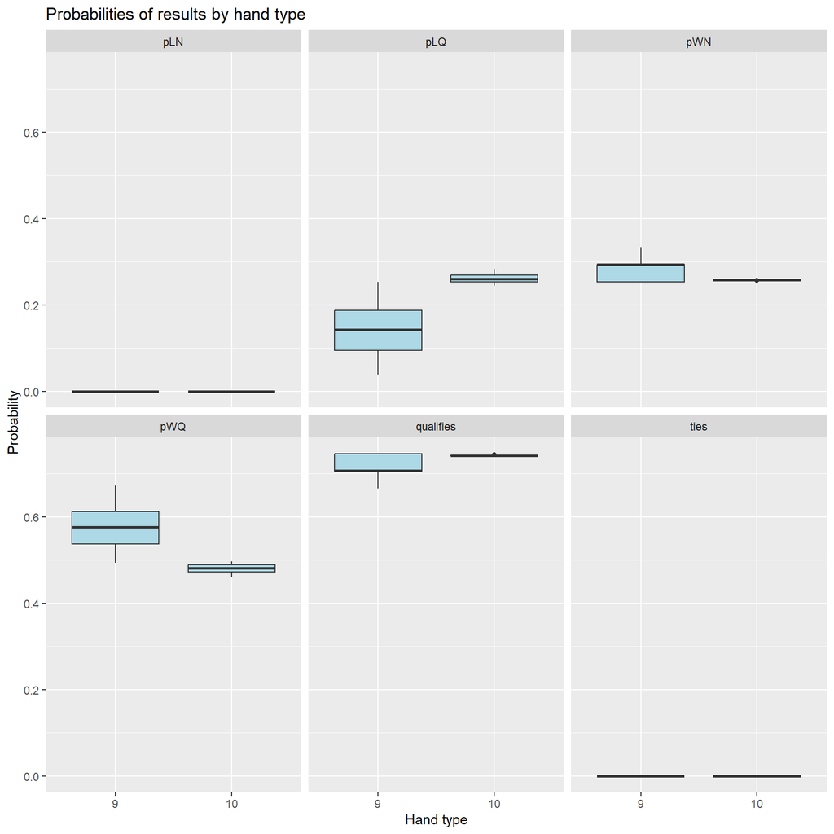

```r
# Plot for result type
res3Kto2P %>%
    mutate(qualifies=pWQ+pTQ+pLQ, ties=pTQ+pTN) %>%
    select(handNum, type, pWQ, pWN, pLQ, pLN, ties, qualifies) %>%
    pivot_longer(-c(handNum, type)) %>%
    ggplot(aes(x=factor(type), y=value)) +
    geom_boxplot(fill="lightblue") +
    facet_wrap(~name) +
    labs(title="Probabilities of results by hand type", x="Hand type", y="Probability")
```

```r
# Run for example hand of all hand types 11 with no wild (pair)
seq1d <- sortedHandRanks %>%
    filter(wType == 11 & nWild==0) %>%
    group_by(nWild, wType, tb1, tb2, tb3, tb4, tb5) %>%
    filter(row_number()==1) %>%
    ungroup()

# Run for select hands
t <- proc.time(); resPairNoWild <- calculateResults(useHandNums=seq1d$handNum); proc.time()-t
```

```
##    user  system elapsed
## 1048.64  280.61 1421.57
```

```r
resPairNoWild
```

```
## # A tibble: 1,980 × 16
##      pLQ   pLN       pTQ   pTN     pWQ   pWN       n pWNoTie  rank  type handNum
##    <dbl> <dbl>     <dbl> <dbl>   <dbl> <dbl>   <int>   <dbl> <dbl> <dbl>   <int>
##  1 0.331     0 0.0000158     0 0.409   0.260 1712304   0.669  2564    11   20834
##  2 0.736     0 0.0000158     0 0.00383 0.260 1712304   0.264  4259    11   20836
##  3 0.722     0 0.0000158     0 0.0176  0.260 1712304   0.278  4094    11   20837
##  4 0.708     0 0.0000158     0 0.0314  0.260 1712304   0.292  3929    11   20838
##  5 0.330     0 0.000168      0 0.409   0.260 1712304   0.670  2563    11   20881
##  6 0.736     0 0.0000158     0 0.00385 0.260 1712304   0.264  4258    11   20883
##  7 0.722     0 0.0000158     0 0.0176  0.260 1712304   0.278  4093    11   20884
##  8 0.683     0 0.0000158     0 0.0569  0.261 1712304   0.317  3764    11   20886
##  9 0.329     0 0.000168      0 0.411   0.260 1712304   0.671  2560    11   20927
## 10 0.736     0 0.0000158     0 0.00390 0.260 1712304   0.264  4256    11   20929
## # … with 1,970 more rows, and 5 more variables: betPlay <dbl>, evAnte <dbl>,
## #   evPlay <dbl>, evBlind <dbl>, evAll <dbl>
```

```r
# Statistics for EV by hand type
resPairNoWild %>%
    full_join(select(seq1d, handNum, tb1), by="handNum") %>%
    group_by(tb1) %>%
    summarize(n=n(), across(c(pWNoTie, evAll), .fns=list(min=min, mean=mean, med=median, max=max)))
```

```
## # A tibble: 12 × 10
##      tb1     n pWNoTie…¹ pWNoT…² pWNoT…³ pWNoT…⁴ evAll…⁵ evAll…⁶ evAll…⁷ evAll…⁸
##    <dbl> <int>     <dbl>   <dbl>   <dbl>   <dbl>   <dbl>   <dbl>   <dbl>   <dbl>
##  1     3   165     0.260   0.263   0.263   0.265  -1.96  -1.94   -1.95    -1.93
##  2     4   165     0.274   0.286   0.288   0.291  -1.89  -1.83   -1.82    -1.81
##  3     5   165     0.288   0.308   0.313   0.317  -1.82  -1.72   -1.70    -1.68
##  4     6   165     0.302   0.331   0.329   0.343  -1.75  -1.61   -1.62    -1.55
##  5     7   165     0.328   0.353   0.354   0.368  -1.62  -1.50   -1.49    -1.42
##  6     8   165     0.353   0.377   0.381   0.396  -1.49  -1.38   -1.36    -1.28
##  7     9   165     0.382   0.406   0.402   0.429  -1.35  -1.23   -1.25    -1.11
##  8    10   165     0.414   0.440   0.440   0.472  -1.19  -1.06   -1.06    -0.901
##  9    11   165     0.455   0.484   0.490   0.528  -0.987 -0.837  -0.813   -0.567
## 10    12   165     0.508   0.540   0.534   0.580  -0.708 -0.481  -0.525   -0.199
## 11    13   165     0.577   0.610   0.605   0.645  -0.221  0.0118 -0.0275   0.253
## 12    14   165     0.669   0.698   0.698   0.723   0.421  0.624   0.624    0.797
## # … with abbreviated variable names ¹pWNoTie_min, ²pWNoTie_mean, ³pWNoTie_med,
## #   ⁴pWNoTie_max, ⁵evAll_min, ⁶evAll_mean, ⁷evAll_med, ⁸evAll_max
```

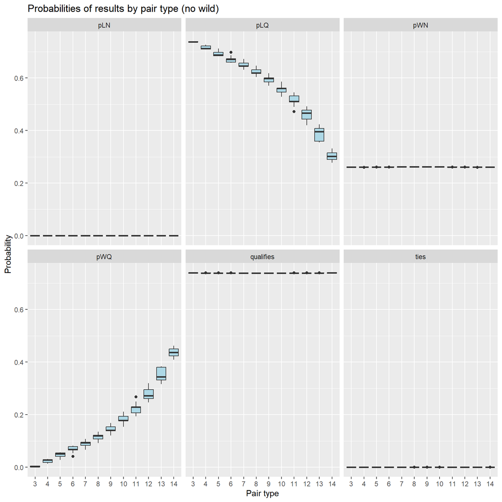

```r
# Plot for result type
resPairNoWild %>%
    full_join(select(seq1d, handNum, tb1), by="handNum") %>%
    mutate(qualifies=pWQ+pTQ+pLQ, ties=pTQ+pTN) %>%
    select(handNum, tb1, pWQ, pWN, pLQ, pLN, ties, qualifies) %>%
    pivot_longer(-c(handNum, tb1)) %>%
    ggplot(aes(x=factor(tb1), y=value)) +
    geom_boxplot(fill="lightblue") +
    facet_wrap(~name) +
    labs(title="Probabilities of results by pair type (no wild)", x="Pair type", y="Probability")
```

```r
# Run for example hand of all hand types 11 with wild (pair) and type 99 (no pair)
seq1e <- sortedHandRanks %>%
    filter(wType==99 | (wType == 11 & nWild==1)) %>%
    group_by(nWild, wType, tb1, tb2, tb3, tb4, tb5) %>%
    filter(row_number()==1) %>%
    ungroup()

# Run for select hands
t <- proc.time(); resWildPairNoPair <- calculateResults(useHandNums=seq1e$handNum); proc.time()-t
```

```
##    user  system elapsed
##  698.46  189.06  984.62
```

```r
resWildPairNoPair
```

```
## # A tibble: 1,245 × 16
##      pLQ   pLN      pTQ   pTN   pWQ   pWN       n pWNoTie  rank  type handNum
##    <dbl> <dbl>    <dbl> <dbl> <dbl> <dbl>   <int>   <dbl> <dbl> <dbl>   <int>
##  1 0.306     0 0.000232     0 0.397 0.297 1712304   0.694  2563    11      15
##  2 0.304     0 0.000232     0 0.399 0.297 1712304   0.696  2560    11      16
##  3 0.301     0 0.000232     0 0.402 0.297 1712304   0.699  2554    11      17
##  4 0.297     0 0.000232     0 0.406 0.297 1712304   0.703  2544    11      18
##  5 0.290     0 0.000232     0 0.413 0.297 1712304   0.710  2529    11      19
##  6 0.281     0 0.000232     0 0.422 0.297 1712304   0.719  2508    11      20
##  7 0.268     0 0.000232     0 0.435 0.297 1712304   0.732  2480    11      21
##  8 0.251     0 0.000232     0 0.452 0.297 1712304   0.749  2444    11      22
##  9 0.305     0 0.000232     0 0.398 0.297 1712304   0.695  2562    11      63
## 10 0.303     0 0.000232     0 0.399 0.297 1712304   0.697  2559    11      64
## # … with 1,235 more rows, and 5 more variables: betPlay <dbl>, evAnte <dbl>,
## #   evPlay <dbl>, evBlind <dbl>, evAll <dbl>
```

```r
# Statistics for EV by hand type
resWildPairNoPair %>%
    full_join(select(seq1e, handNum, tb1, nWild), by="handNum") %>%
    group_by(type, nWild, tb1) %>%
    summarize(n=n(), across(c(pWNoTie, evAll), .fns=list(min=min, mean=mean, med=median, max=max)))
```

```
## # A tibble: 14 × 12
## # Groups:   type, nWild [2]
##     type nWild   tb1     n pWNoTie_min pWNoTi…¹ pWNoT…² pWNoT…³ evAll_…⁴ evAll…⁵
##    <dbl> <dbl> <dbl> <int>       <dbl>    <dbl>   <dbl>   <dbl>    <dbl>   <dbl>
##  1    11     1     8     6    0.397    0.398    3.98e-1 4.00e-1 -1.31     -1.31
##  2    11     1     9    16    0.427    0.430    4.30e-1 4.33e-1 -1.16     -1.15
##  3    11     1    10    31    0.461    0.467    4.67e-1 4.73e-1 -0.994    -0.962
##  4    11     1    11    52    0.500    0.512    5.12e-1 5.23e-1 -0.795    -0.713
##  5    11     1    12    80    0.550    0.568    5.69e-1 5.86e-1 -0.449    -0.319
##  6    11     1    13   116    0.613    0.640    6.39e-1 6.65e-1 -0.00766   0.182
##  7    11     1    14   160    0.694    0.732    7.31e-1 7.67e-1  0.563     0.823
##  8    99     0     8     4    0        0.000282 2.82e-4 5.64e-4 -2        -2
##  9    99     0     9    14    0.000939 0.00231  2.29e-3 3.76e-3 -2        -2
## 10    99     0    10    34    0.00480  0.00872  8.81e-3 1.27e-2 -2        -2
## 11    99     0    11    69    0.0154   0.0242   2.37e-2 3.30e-2 -2        -2
## 12    99     0    12   125    0.0388   0.0561   5.54e-2 7.32e-2 -2        -2
## 13    99     0    13   209    0.0843   0.115    1.14e-1 1.45e-1 -2        -2
## 14    99     0    14   329    0.165    0.215    2.14e-1 2.64e-1 -2        -1.99
## # … with 2 more variables: evAll_med <dbl>, evAll_max <dbl>, and abbreviated
## #   variable names ¹pWNoTie_mean, ²pWNoTie_med, ³pWNoTie_max, ⁴evAll_min,
## #   ⁵evAll_mean
```

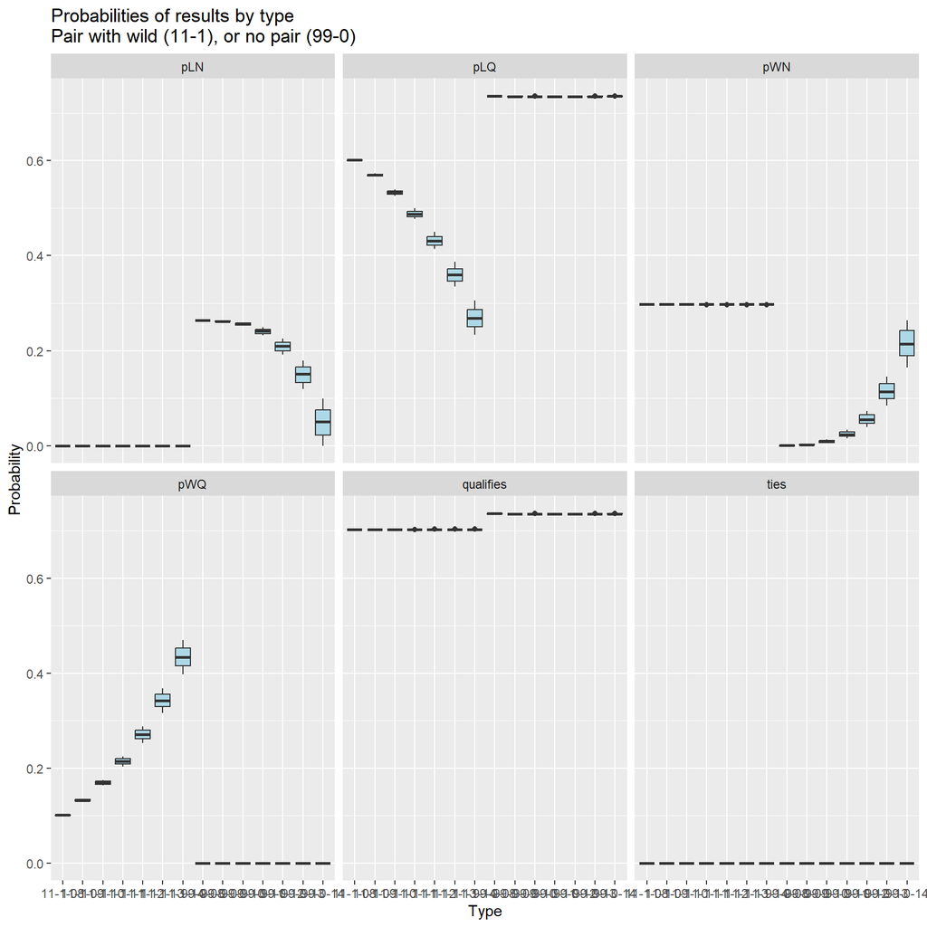

```r
# Plot for result type
resWildPairNoPair %>%
    full_join(select(seq1e, handNum, tb1, nWild), by="handNum") %>%
    mutate(qualifies=pWQ+pTQ+pLQ, ties=pTQ+pTN) %>%
    select(handNum, tb1, nWild, type, pWQ, pWN, pLQ, pLN, ties, qualifies) %>%
    pivot_longer(-c(handNum, tb1, nWild, type)) %>%
    mutate(lab=paste0(type, "-", nWild, "-", stringr::str_pad(as.character(tb1), 2, side="left", pad="0"))) %>%
    ggplot(aes(x=factor(lab), y=value)) +
    geom_boxplot(fill="lightblue") +
    facet_wrap(~name) +
    labs(title="Probabilities of results by type\nPair with wild (11-1), or no pair (99-0)",
         x="Type",
         y="Probability"
         )
```

The result files are combined and saved:

```r
resAll_202301_v001 <- bind_rows(resWildPairNoPair,
                                resPairNoWild,
                                res3Kto2P,
                                resSTto4K,
                                resSFPlus,
                                .id="src"
                                ) %>%
    mutate(src=c("1"="Wild Pair or No Paor",
                 "2"="Pair, No Wild",
                 "3"="Two Pair or Trips",
                 "4"="Straight to Quads",
                 "5"="Straight Flush or Better"
                 )[src]
           )
resAll_202301_v001
```

```
## # A tibble: 7,309 × 17
##    src            pLQ   pLN     pTQ   pTN   pWQ   pWN      n pWNoTie  rank  type
##    <chr>        <dbl> <dbl>   <dbl> <dbl> <dbl> <dbl>  <int>   <dbl> <dbl> <dbl>
##  1 Wild Pair o… 0.306     0 2.32e-4     0 0.397 0.297 1.71e6   0.694  2563    11
##  2 Wild Pair o… 0.304     0 2.32e-4     0 0.399 0.297 1.71e6   0.696  2560    11
##  3 Wild Pair o… 0.301     0 2.32e-4     0 0.402 0.297 1.71e6   0.699  2554    11
##  4 Wild Pair o… 0.297     0 2.32e-4     0 0.406 0.297 1.71e6   0.703  2544    11
##  5 Wild Pair o… 0.290     0 2.32e-4     0 0.413 0.297 1.71e6   0.710  2529    11
##  6 Wild Pair o… 0.281     0 2.32e-4     0 0.422 0.297 1.71e6   0.719  2508    11
##  7 Wild Pair o… 0.268     0 2.32e-4     0 0.435 0.297 1.71e6   0.732  2480    11
##  8 Wild Pair o… 0.251     0 2.32e-4     0 0.452 0.297 1.71e6   0.749  2444    11
##  9 Wild Pair o… 0.305     0 2.32e-4     0 0.398 0.297 1.71e6   0.695  2562    11
## 10 Wild Pair o… 0.303     0 2.32e-4     0 0.399 0.297 1.71e6   0.697  2559    11
## # … with 7,299 more rows, and 6 more variables: handNum <int>, betPlay <dbl>,
## #   evAnte <dbl>, evPlay <dbl>, evBlind <dbl>, evAll <dbl>
```

```r
saveToRDS(resAll_202301_v001, ovrWriteError=FALSE)
```

```
##
## File already exists: ./RInputFiles/Coronavirus/resAll_202301_v001.RDS
##
## Not replacing the existing file since ovrWrite=FALSE
```

Results are explored:

```r
# Create the analysis frame
dfResAll_202301_v001 <- resAll_202301_v001 %>%
    left_join(select(sortedHandRanks, handNum, nWild, wType, starts_with("tb")), by="handNum") %>%
    full_join(sortedHandRanks %>% count(nWild, wType, tb1, tb2, tb3, tb4, tb5, name="nOfType"))
```

```r
# Chart of overall probabilities by bet amount
dfResAll_202301_v001 %>%
    summarize(n=sum(nOfType),
              across(c(pWNoTie, evAnte, evPlay, evBlind, evAll), .fns=function(x) sum(x*nOfType)/sum(nOfType))
              )
```

```
## # A tibble: 1 × 6
##         n pWNoTie evAnte evPlay evBlind   evAll
##     <int>   <dbl>  <dbl>  <dbl>   <dbl>   <dbl>
## 1 2869685   0.500 -0.274  0.457  -0.259 -0.0757
```

```r
# Chart of probabilities by bet amount
dfResAll_202301_v001 %>%
    group_by(betPlay) %>%
    summarize(n=sum(nOfType),
              minPw=min(pWNoTie),
              across(c(pWNoTie, evAnte, evPlay, evBlind, evAll), .fns=function(x) sum(x*nOfType)/sum(nOfType))
              )
```

```
## # A tibble: 3 × 8
##   betPlay       n minPw pWNoTie evAnte evPlay evBlind evAll
##     <dbl>   <int> <dbl>   <dbl>  <dbl>  <dbl>   <dbl> <dbl>
## 1       0  743580 0       0.123 -1      0      -1     -2
## 2       1  683520 0.250   0.359 -0.547 -0.282  -0.641 -1.47
## 3       2 1442585 0.500   0.761  0.230  1.04    0.304  1.58
```

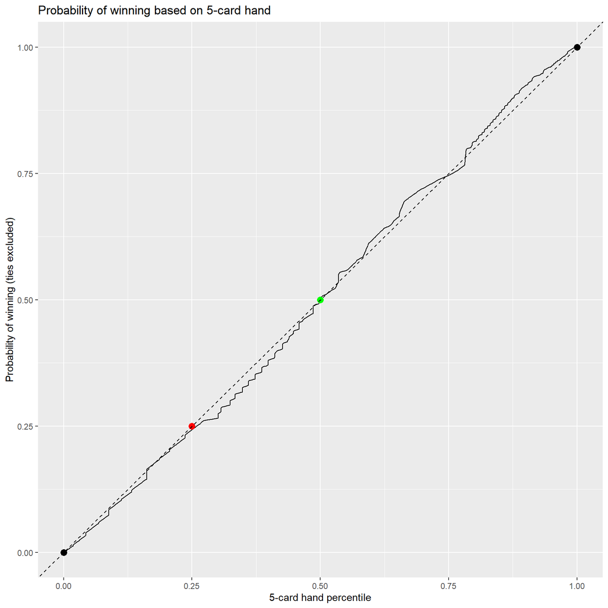

```r
# Plot of win probabilities
dfResAll_202301_v001 %>%
    arrange(pWNoTie) %>%
    mutate(cs=cumsum(nOfType)) %>%
    ggplot(aes(x=cs/choose(53, 5), y=pWNoTie)) +
    geom_line() +
    geom_point(data=tibble::tibble(x=c(0, 0.25, 0.5, 1), col=c("black", "red", "green", "black")) %>% mutate(y=x),
               aes(x=x, y=y, color=col),
               size=3
               ) +
    scale_color_identity() +
    geom_abline(slope=1, intercept=0, lty=2) +
    labs(title="Probability of winning based on 5-card hand",
         x="5-card hand percentile",
         y="Probability of winning (ties excluded)"
         )
```

Volatility of the bonus bet is explored, assuming 100 hands:

```r
nBonusPay <- allValueGrid %>%
    select(n, bonusPay) %>%
    filter(!is.na(n)) %>%
    group_by(bonusPay) %>%
    summarize(n=sum(n))
nBonusPay
```

```
## # A tibble: 15 × 2
##    bonusPay       n
##       <dbl>   <int>
##  1       -1 2235900
##  2        1  415800
##  3        3   73824
##  4        4   13976
##  5        5   11880
##  6        6   93400
##  7       20   10176
##  8       25    8592
##  9       30    3168
## 10       60     528
## 11       70    1400
## 12       90    1000
## 13      200      36
## 14     1000       4
## 15     2000       1
```

```r
# Overall metrics - mean and standard deviation
nBonusPay %>%
    summarize(evBonus=sum(bonusPay*n)/sum(n),
              evBonus2=sum(n*(bonusPay**2))/sum(n)
              ) %>%
    mutate(sdBonus=sqrt(evBonus2-evBonus**2))
```

```
## # A tibble: 1 × 3
##   evBonus evBonus2 sdBonus
##     <dbl>    <dbl>   <dbl>
## 1 -0.0616     16.0    3.99
```

```r
# Simulations of 100 hands
set.seed(23013015)
nSims <- 10000
nPerSim <- 100
simTotal <- vector("numeric", length=nSims)

for(intCtr in 1:nSims) simTotal[intCtr] <- sum(sample(nBonusPay$bonusPay,
                                                      size=nPerSim,
                                                      prob=nBonusPay$n,
                                                      replace=TRUE
                                                      )
                                               )

cat("\n",
    nSims,
    "simulations each of",
    nPerSim,
    "hands has mean:",
    round(mean(simTotal), 2),
    "with sd:",
    round(sd(simTotal), 1),
    "\n"
    )
```

```
##
##  10000 simulations each of 100 hands has mean: -5.72 with sd: 47
```

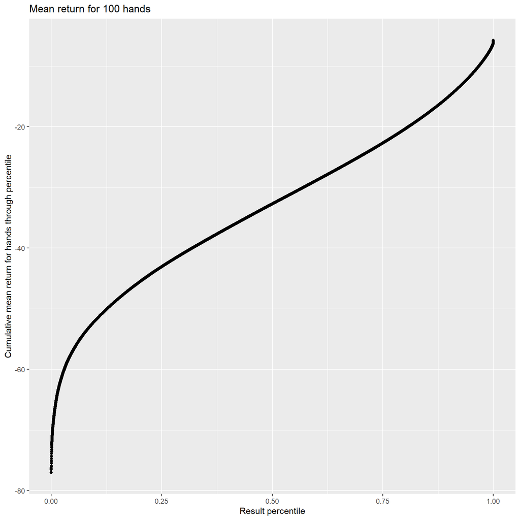

```r
# Plot of outcomes
tibble::tibble(result=simTotal) %>%
    arrange(result) %>%
    mutate(rn=row_number(), cummean=cumsum(result)/rn) %>%
    ggplot(aes(x=(rn-1)/(max(rn)-1), y=cummean)) +
    geom_point() +
    labs(title=paste0("Mean return for ", nPerSim, " hands"),
         x="Result percentile",
         y="Cumulative mean return for hands through percentile"
         )
```

```r
# Quantiles and proportion greater than zero
quantile(simTotal, c(0, 0.01, 0.025, 0.05, 0.1, 0.25, 0.5, 0.75, 0.9, 0.95, 0.975, 0.99, 1))
```

```
##      0%      1%    2.5%      5%     10%     25%     50%     75%     90%     95%
##  -77.00  -61.00  -55.00  -50.00  -44.00  -31.00  -13.00   10.00   42.00   65.00
##   97.5%     99%    100%
##   85.00  110.01 2066.00
```

```r
cat("\n",
    paste0(round(mean(simTotal>0)*100, 1), "%"),
    "of simulations are wins, with mean win per winning simulation:",
    round(mean(simTotal[simTotal>0]), 1),
    "and median win per winning simulation:",
    round(median(simTotal[simTotal>0]), 1)
    )
```

```
##
##  33.8% of simulations are wins, with mean win per winning simulation: 34.7 and median win per winning simulation: 24
```

```r
cat("\n",
    paste0(round(mean(simTotal==0)*100, 1), "%"),
    "of simulations are draws"
    )
```

```
##
##  0.8% of simulations are draws
```

```r
cat("\n",
    paste0(round(mean(simTotal<0)*100, 1), "%"),
    "of simulations are losers, with mean loss per losing simulation:",
    round(mean(simTotal[simTotal<0]), 1),
    "and median loss per losing simulation:",
    round(median(simTotal[simTotal<0]), 1),
    "\n"
    )
```

```
##
##  65.3% of simulations are losers, with mean loss per losing simulation: -26.7 and median loss per losing simulation: -26
```

Volatility of the main bet is explored, assuming 100 hands:

```r
dfHandData <- dfResAll_202301_v001 %>%
    select(wType, nOfType, betPlay, starts_with("p")) %>%
    mutate(win=pWQ+pWN, tie=pTQ+pTN, lose=pLQ+pLN, blindPay=blindPay[paste0("b_", wType)])
dfHandData
```

```
## # A tibble: 7,309 × 14
##    wType nOfType betPlay   pLQ   pLN      pTQ   pTN   pWQ   pWN pWNoTie   win
##    <dbl>   <int>   <dbl> <dbl> <dbl>    <dbl> <dbl> <dbl> <dbl>   <dbl> <dbl>
##  1    11    1260       2 0.306     0 0.000232     0 0.397 0.297   0.694 0.694
##  2    11    1260       2 0.304     0 0.000232     0 0.399 0.297   0.696 0.696
##  3    11    1260       2 0.301     0 0.000232     0 0.402 0.297   0.699 0.699
##  4    11    1260       2 0.297     0 0.000232     0 0.406 0.297   0.703 0.703
##  5    11    1260       2 0.290     0 0.000232     0 0.413 0.297   0.710 0.710
##  6    11    1260       2 0.281     0 0.000232     0 0.422 0.297   0.719 0.719
##  7    11    1260       2 0.268     0 0.000232     0 0.435 0.297   0.732 0.732
##  8    11    1260       2 0.251     0 0.000232     0 0.452 0.297   0.749 0.749
##  9    11    1260       2 0.305     0 0.000232     0 0.398 0.297   0.695 0.695
## 10    11    1260       2 0.303     0 0.000232     0 0.399 0.297   0.697 0.697
## # … with 7,299 more rows, and 3 more variables: tie <dbl>, lose <dbl>,
## #   blindPay <dbl>
```

```r
getHandOutcome <- function(pWQ, pWN, tie, lose, betPlay, blindPay) {
    if(betPlay==0) return(tibble::tibble(result="fold", ante=-1, blind=-1, play=0))
    result <- sample(c("win/qualify", "win/no qualify", "tie", "lose"),
                     size=1,
                     replace=TRUE,
                     prob=c(pWQ, pWN, tie, lose)
                     )
    return(tibble::tibble(result=result,
                          ante=case_when(result=="win/qualify" ~ 1,
                                         result %in% c("win/no qualify", "tie") ~ 0,
                                         result=="lose" ~ -1,
                                         TRUE ~ -99
                                         ),
                          blind=case_when(result %in% c("win/qualify", "win/no qualify") ~ blindPay,
                                          result=="tie" ~ 0,
                                          result=="lose" ~ -1,
                                          TRUE ~ -99
                                          ),
                          play=case_when(result %in% c("win/qualify", "win/no qualify") ~ betPlay,
                                         result=="tie" ~ 0,
                                         result=="lose" ~ -betPlay,
                                         TRUE ~ -99
                                         )
                          )
           )

}

lst200 <- lapply(1:200, FUN=function(y) {
    map_dfr(1:100,
            .f=function(x) {
                rn <- sample(1:nrow(dfHandData), size=1, replace=TRUE, prob=dfHandData$nOfType)
                rd <- dfHandData[rn,]
                getHandOutcome(pWQ=rd$pWQ,
                               pWN=rd$pWN,
                               tie=rd$tie,
                               lose=rd$lose,
                               betPlay=rd$betPlay,
                               blindPay=rd$blindPay
                               ) %>%
                    mutate(rn=rn, n=1)
                }
            )
            }
    )

res200 <- map_dfr(lst200, .f=function(x) summarize(x, across(c("ante", "blind", "play"), .fns=sum), n=n()))
res200
```

```
## # A tibble: 200 × 4
##     ante blind  play     n
##    <dbl> <dbl> <dbl> <int>
##  1   -21   -27    62   100
##  2    -6   -23    76   100
##  3   -27   -34    42   100
##  4   -31   -42    36   100
##  5   -36   -39    48   100
##  6   -28   -14    40   100
##  7   -27   -32    45   100
##  8   -35   -32    39   100
##  9   -20   -36    64   100
## 10   -20   -30    54   100
## # … with 190 more rows
```

```r
res200 %>%
    mutate(overall=ante+blind+play) %>%
    summarize(across(.fns=mean))
```

```
## # A tibble: 1 × 5
##    ante blind  play     n overall
##   <dbl> <dbl> <dbl> <dbl>   <dbl>
## 1 -28.2 -26.3  44.6   100   -9.84
```

The process is converted for parallel processing:

```r
# Simulations of 100 hands
set.seed(23020115)
nSims <- 10000
nPerSim <- 100
simTotal <- vector("numeric", length=nSims)

# Get the hand numbers for the simulation
rn <- sample(1:nrow(dfHandData), size=nPerSim*nSims, replace=TRUE, prob=dfHandData$nOfType)

# Get the outcomes for the simulation
rd <- dfHandData[rn,] %>%
    mutate(prob=runif(nPerSim*nSims),
           wintie=win+tie,
           res=case_when(prob<=pWQ ~ "winQ",
                         prob<=win ~ "winNo",
                         prob <= wintie ~ "tie",
                         prob <= wintie+lose ~ "lose",
                         TRUE ~ "ERROR"
                         )
           )

# Convert to payouts by bet
rp <- rd %>%
    mutate(resActual=ifelse(betPlay==0, "fold", res),
           resPlay=case_when(resActual %in% c("winQ", "winNo") ~ betPlay,
                             resActual %in% c("fold", "tie") ~ 0,
                             resActual %in% c("lose") ~ -betPlay,
                             TRUE ~ -Inf
                             ),
           resBlind=case_when(resActual %in% c("winQ", "winNo") ~ blindPay,
                              resActual %in% c("tie") ~ 0,
                              resActual %in% c("lose", "fold") ~ -1,
                              TRUE ~ -Inf
                              ),
           resAnte=case_when(resActual %in% c("winQ") ~ 1,
                             resActual %in% c("tie", "winNo") ~ 0,
                             resActual %in% c("lose", "fold") ~ -1,
                             TRUE ~ -Inf
                             ),
           resAll=resPlay+resBlind+resAnte
           ) %>%
    select(wType, betPlay, res, resActual, resPlay, resBlind, resAnte, resAll)
rp
```

```
## # A tibble: 1,000,000 × 8
##    wType betPlay res   resActual resPlay resBlind resAnte resAll
##    <dbl>   <dbl> <chr> <chr>       <dbl>    <dbl>   <dbl>  <dbl>
##  1    11       2 lose  lose           -2       -1      -1     -4
##  2     8       2 winQ  winQ            2        2       1      5
##  3    99       0 lose  fold            0       -1      -1     -2
##  4    11       2 winQ  winQ            2        0       1      3
##  5    10       2 winNo winNo           2        0       0      2
##  6     9       2 winNo winNo           2        0       0      2
##  7    11       2 lose  lose           -2       -1      -1     -4
##  8    11       2 lose  lose           -2       -1      -1     -4
##  9    11       1 lose  lose           -1       -1      -1     -3
## 10     9       2 winQ  winQ            2        0       1      3
## # … with 999,990 more rows
```

```r
# Get statistics by key attributes
rp %>%
    summarize(n=n(), across(c(resPlay, resBlind, resAnte, resAll), .fns=mean))
```

```
## # A tibble: 1 × 5
##         n resPlay resBlind resAnte  resAll
##     <int>   <dbl>    <dbl>   <dbl>   <dbl>
## 1 1000000   0.457   -0.254  -0.274 -0.0709
```

```r
rp %>%
    group_by(wType, betPlay) %>%
    summarize(n=n(), across(c(resPlay, resBlind, resAnte, resAll), .fns=mean), .groups="drop") %>%
    arrange(desc(wType), betPlay)
```

```
## # A tibble: 14 × 7
##    wType betPlay      n resPlay resBlind resAnte   resAll
##    <dbl>   <dbl>  <int>   <dbl>    <dbl>   <dbl>    <dbl>
##  1    99       0 259500   0       -1     -1        -2
##  2    99       1  19608  -0.495   -0.748 -0.748    -1.99
##  3    11       1 218048  -0.261   -0.630 -0.527    -1.42
##  4    11       2 248743   0.541   -0.365 -0.0166    0.159
##  5    10       2  33267   0.956   -0.261  0.222     0.917
##  6     9       2 159596   1.51    -0.123  0.455     1.84
##  7     8       2  29385   1.85     1.88   0.616     4.35
##  8     7       2   6699   1.90     2.90   0.639     5.44
##  9     6       2   5287   1.91     3.89   0.669     6.47
## 10     5       2  17688   1.98     4.97   0.660     7.61
## 11     4       2   1307   2.00    25.0    0.657    27.6
## 12     3       2    500   2       40      0.624    42.6
## 13     2       2    370   2      100      0.649   103.
## 14     1       2      2   2     2000      0.5    2002.
```

```r
rp %>%
    group_by(wType, resActual) %>%
    summarize(n=n(), across(c(resPlay, resBlind, resAnte, resAll), .fns=mean), .groups="drop") %>%
    arrange(desc(wType), resActual) %>%
    print(n=40)
```

```
## # A tibble: 37 × 7
##    wType resActual      n resPlay resBlind resAnte  resAll
##    <dbl> <chr>      <int>   <dbl>    <dbl>   <dbl>   <dbl>
##  1    99 fold      259500    0          -1      -1   -2
##  2    99 lose       14660   -1          -1      -1   -3
##  3    99 tie            3    0           0       0    0
##  4    99 winNo       4945    1           0       0    1
##  5    11 lose      228193   -1.40       -1      -1   -3.40
##  6    11 tie           67    0           0       0    0
##  7    11 winNo     129395    1.55        0       0    1.55
##  8    11 winQ      109136    1.79        0       1    2.79
##  9    10 lose        8682   -2          -1      -1   -4
## 10    10 winNo       8508    2           0       0    2
## 11    10 winQ       16077    2           0       1    3
## 12     9 lose       19582   -2          -1      -1   -4
```

[output cut: 25 more lines]

```r
rp %>%
    group_by(betPlay, resActual, res) %>%
    summarize(n=n(),
              across(c(resPlay, resBlind, resAnte, resAll), .fns=list(mean=mean)),
              .groups="drop"
              ) %>%
    arrange(betPlay)
```

```
## # A tibble: 11 × 8
##    betPlay resActual res        n resPlay_mean resBlind_mean resAnte_m…¹ resAl…²
##      <dbl> <chr>     <chr>  <int>        <dbl>         <dbl>       <dbl>   <dbl>
##  1       0 fold      lose  227552            0        -1              -1   -2
##  2       0 fold      tie       35            0        -1              -1   -2
##  3       0 fold      winNo  31913            0        -1              -1   -2
##  4       1 lose      lose  152121           -1        -1              -1   -3
##  5       1 tie       tie       16            0         0               0    0
##  6       1 winNo     winNo  62986            1         0               0    1
##  7       1 winQ      winQ   22533            1         0               1    2
##  8       2 lose      lose  120461           -2        -1              -1   -4
##  9       2 tie       tie      114            0         0               0    0
## 10       2 winNo     winNo 146965            2         0.635           0    2.64
## 11       2 winQ      winQ  235304            2         0.787           1    3.79
## # … with abbreviated variable names ¹resAnte_mean, ²resAll_mean
```

The value of holding a specific card (no other values known) is explored:

```r
# Full database of hands and outcomes
fullHandDB <- sortedHandRanks %>%
    select(handNum, rank, qual, nWild) %>%
    full_join(select(dfResAll_202301_v001, -handNum), by=c("rank", "nWild")) %>%
    mutate(nType=tblAllTypes$nType) %>%
    left_join(select(allValueGrid, wType=wildType, nType=naturalType, bonusPay), by=c("wType", "nType"))
fullHandDB
```

```
## # A tibble: 2,869,685 × 28
##    handNum  rank qual  nWild src             pLQ   pLN     pTQ   pTN   pWQ   pWN
##      <int> <dbl> <chr> <dbl> <chr>         <dbl> <dbl>   <dbl> <dbl> <dbl> <dbl>
##  1       1    22 Q         1 Straight F… 0.00156     0 5.96e-5     0 0.702 0.297
##  2       2   404 Q         1 Straight t… 0.0243      0 1.58e-5     0 0.679 0.297
##  3       3   401 Q         1 Straight t… 0.0243      0 1.58e-5     0 0.679 0.297
##  4       4   395 Q         1 Straight t… 0.0242      0 2.63e-5     0 0.679 0.297
##  5       5   385 Q         1 Straight t… 0.0240      0 2.63e-5     0 0.679 0.297
##  6       6   370 Q         1 Straight t… 0.0236      0 2.63e-5     0 0.679 0.297
##  7       7   349 Q         1 Straight t… 0.0231      0 2.63e-5     0 0.680 0.297
##  8       8   321 Q         1 Straight t… 0.0224      0 4.38e-5     0 0.681 0.297
##  9       9   321 Q         1 Straight t… 0.0224      0 4.38e-5     0 0.681 0.297
## 10      10  1134 Q         1 Two Pair o… 0.0639      0 2.10e-5     0 0.643 0.293
## # … with 2,869,675 more rows, and 17 more variables: n <int>, pWNoTie <dbl>,
## #   type <dbl>, betPlay <dbl>, evAnte <dbl>, evPlay <dbl>, evBlind <dbl>,
## #   evAll <dbl>, wType <dbl>, tb1 <dbl>, tb2 <dbl>, tb3 <dbl>, tb4 <dbl>,
## #   tb5 <dbl>, nOfType <int>, nType <dbl>, bonusPay <dbl>
```

```r
# Average bonus value given presence of card in hand
cardBonusValue <- map_dfr(.x=1:53,
                          .f=function(x) fullHandDB %>%
                              mutate(keyHand=ifelse(handNum %in% cardInHand[[x]], "Y", "N")) %>%
                              group_by(keyHand) %>%
                              summarize(n=n(), ev=mean(bonusPay), pctWin=mean(bonusPay>0)),
                          .id="cardNum"
                          )
```

```r
# Check that values are suit independent
map_dfr(.x=1:13,
        .f=function(x) cardBonusValue %>%
            filter(as.integer(cardNum) %in% (x+c(0, 13, 26, 39))) %>%
            group_by(keyHand) %>%
            summarize(across(where(is.numeric), .fns=function(x) max(x)-min(x))),
        .id="cardRank"
        ) %>%
    summary()
```

```
##    cardRank           keyHand                n           ev
##  Length:26          Length:26          Min.   :0   Min.   :0.000e+00
##  Class :character   Class :character   1st Qu.:0   1st Qu.:5.551e-17
##  Mode  :character   Mode  :character   Median :0   Median :8.327e-17
##                                        Mean   :0   Mean   :1.999e-16
##                                        3rd Qu.:0   3rd Qu.:2.064e-16
##                                        Max.   :0   Max.   :1.388e-15
##      pctWin
##  Min.   :0
##  1st Qu.:0
##  Median :0
##  Mean   :0
##  3rd Qu.:0
##  Max.   :0
```

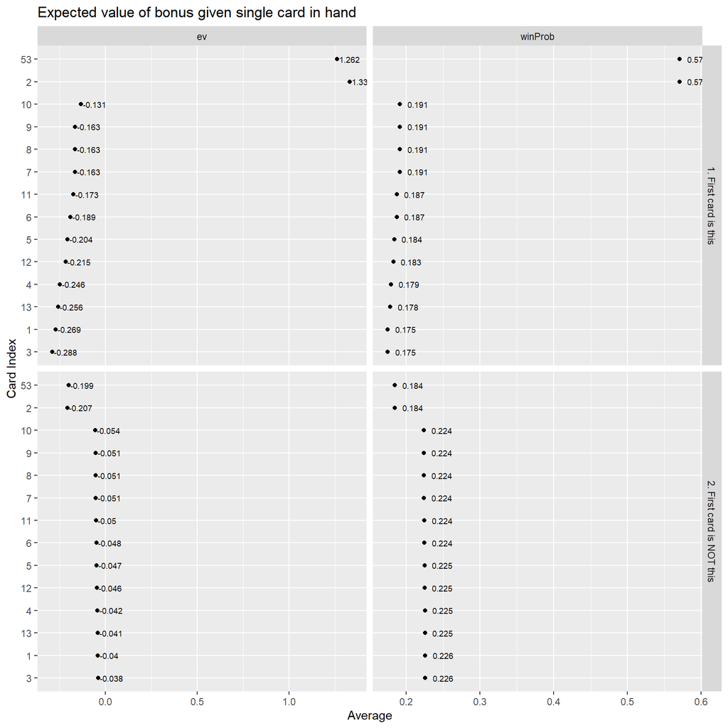

```r
# Show hand values
cardBonusValue %>%
    filter(as.integer(cardNum) %in% c(1:13, 53)) %>%
    select(haveCard=keyHand, cardNum, ev, winProb=pctWin) %>%
    pivot_longer(-c(haveCard, cardNum)) %>%
    mutate(haveCard=ifelse(haveCard=="Y", "1. First card is this", "2. First card is NOT this")) %>%
    ggplot(aes(x=fct_reorder(cardNum,
                             value,
                             .fun=function(x) x[order(x, decreasing=TRUE)[2]] + min(x)/100
                             )
               )
           ) +
    geom_point(aes(y=value)) +
    geom_text(aes(y=value+0.01, label=round(value, 3)), size=2.5, hjust=0) +
    coord_flip() +
    facet_grid(haveCard~name, scales="free_x") +
    labs(title="Expected value of bonus given single card in hand", y="Average", x="Card Index")
```

As expected, wild cards are very valuable and make bonus hands much more likely. The deuce is more valuable than the joker since it can make higher-paying natural straights and flushes. Of the non-wild cards, 10 is most valuable (can make any straight, including royal), followed by 7-8-9 (can make any straight, naturally or wild)

The value of holding a specific card (no other values known) is explored:

```r
# Average bonus value given presence of card in hand
cardMainValue <- map_dfr(.x=1:53,
                         .f=function(x) fullHandDB %>%
                             mutate(keyHand=ifelse(handNum %in% cardInHand[[x]], "Y", "N")) %>%
                             group_by(keyHand, betPlay) %>%
                             summarize(n=n(),
                                       across(c(pLQ, pLN, pTQ, pTN, pWQ, pWN, evPlay, evAll), .fns=mean),
                                       .groups="drop"
                                       ),
                         .id="cardNum"
                         )
```

```r
# Check that values are suit independent
map_dfr(.x=1:13,
        .f=function(x) cardMainValue %>%
            filter(as.integer(cardNum) %in% (x+c(0, 13, 26, 39))) %>%
            group_by(keyHand, betPlay) %>%
            summarize(across(where(is.numeric), .fns=function(x) max(x)-min(x)), .groups="drop"),
        .id="cardRank"
        ) %>%
    summary()
```

```
##    cardRank           keyHand             betPlay            n
##  Length:77          Length:77          Min.   :0.000   Min.   :0
##  Class :character   Class :character   1st Qu.:0.000   1st Qu.:0
##  Mode  :character   Mode  :character   Median :1.000   Median :0
##                                        Mean   :1.013   Mean   :0
##                                        3rd Qu.:2.000   3rd Qu.:0
##                                        Max.   :2.000   Max.   :0
##       pLQ                 pLN                 pTQ
##  Min.   :0.000e+00   Min.   :0.000e+00   Min.   :0.000e+00
##  1st Qu.:0.000e+00   1st Qu.:0.000e+00   1st Qu.:0.000e+00
##  Median :0.000e+00   Median :0.000e+00   Median :0.000e+00
##  Mean   :9.012e-18   Mean   :1.094e-18   Mean   :3.344e-21
##  3rd Qu.:0.000e+00   3rd Qu.:0.000e+00   3rd Qu.:0.000e+00
##  Max.   :1.110e-16   Max.   :2.776e-17   Max.   :2.711e-20
##       pTN                 pWQ                 pWN
##  Min.   :0.000e+00   Min.   :0.000e+00   Min.   :0.000e+00
##  1st Qu.:0.000e+00   1st Qu.:0.000e+00   1st Qu.:0.000e+00
##  Median :0.000e+00   Median :0.000e+00   Median :0.000e+00
##  Mean   :2.970e-22   Mean   :5.227e-18   Mean   :2.523e-18
##  3rd Qu.:0.000e+00   3rd Qu.:0.000e+00   3rd Qu.:0.000e+00
##  Max.   :1.355e-20   Max.   :5.551e-17   Max.   :5.551e-17
##      evPlay              evAll
##  Min.   :0.000e+00   Min.   :0.000e+00
##  1st Qu.:0.000e+00   1st Qu.:0.000e+00
##  Median :0.000e+00   Median :0.000e+00
##  Mean   :8.651e-18   Mean   :2.884e-17
##  3rd Qu.:0.000e+00   3rd Qu.:0.000e+00
##  Max.   :2.220e-16   Max.   :4.441e-16
```

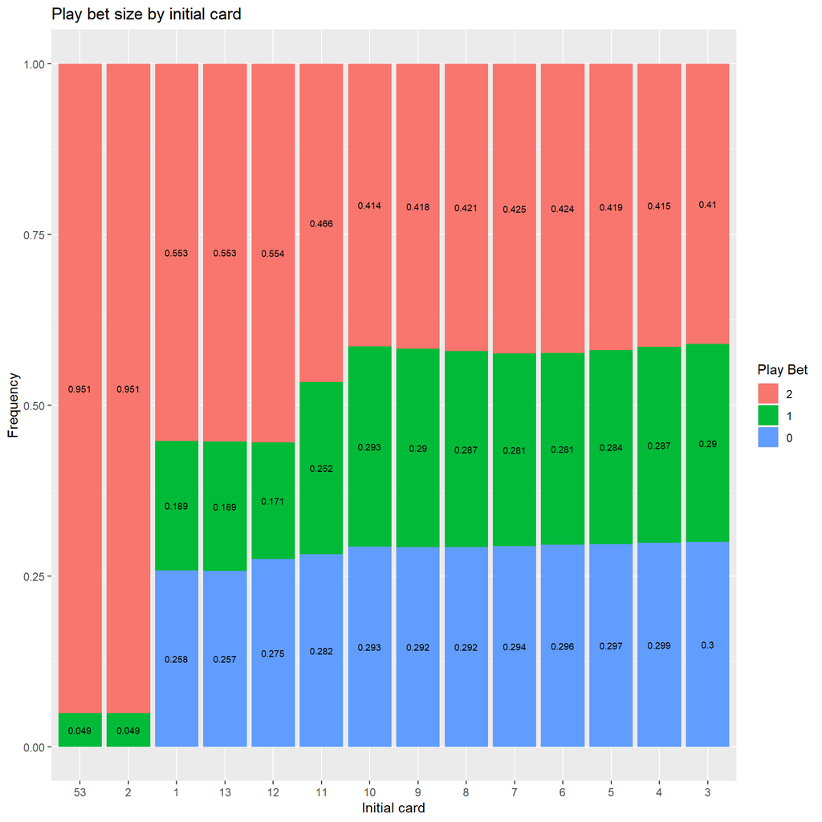

```r
# Show play bet size probabilities by initial card
cardMainValue %>%
    filter(as.integer(cardNum) %in% c(1:13, 53), keyHand=="Y") %>%
    group_by(cardNum) %>%
    mutate(pct=n/sum(n), cumpct=cumsum(pct)-pct/2) %>%
    ungroup() %>%
    ggplot(aes(x=factor(cardNum, levels=c(53, 2, 1, 13:3)))) +
    geom_col(aes(y=pct, fill=fct_rev(factor(betPlay))), position="fill") +
    geom_text(aes(y=cumpct, label=round(pct,3)), size=2.5) +
    labs(title="Play bet size by initial card", x="Initial card", y="Frequency") +
    scale_fill_discrete("Play Bet")
```

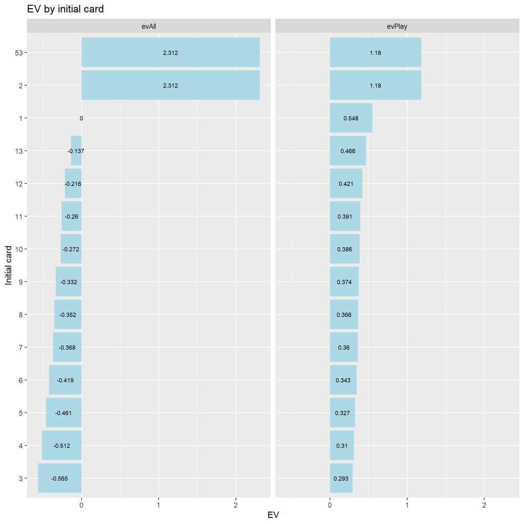

```r
# Show main bet EV by initial card and bet amount
cardMainValue %>%
    filter(as.integer(cardNum) %in% c(1:13, 53), keyHand=="Y") %>%
    group_by(cardNum) %>%
    summarize(across(c(evPlay, evAll), .fns=function(x) sum(x*n)/sum(n)), .groups="drop") %>%
    pivot_longer(-c(cardNum)) %>%
    ggplot(aes(x=factor(cardNum, levels=c(3:13, 1, 2, 53)))) +
    geom_col(aes(y=value), fill="lightblue") +
    geom_text(aes(y=value/2, label=round(value,3)), size=2.5) +
    labs(title="EV by initial card", x="Initial card", y="EV") +
    coord_flip() +
    facet_wrap(~name)
```

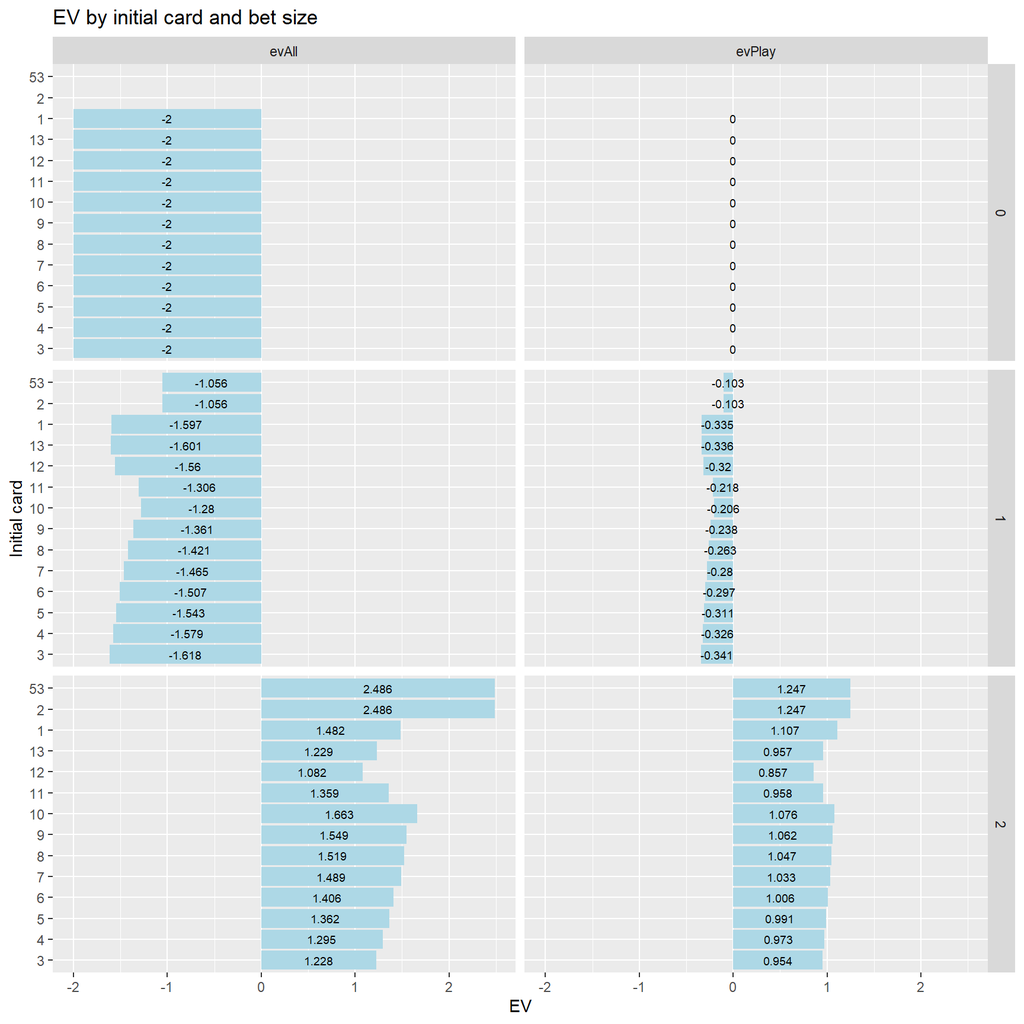

```r
# Show main bet EV by initial card and bet amount
cardMainValue %>%
    filter(as.integer(cardNum) %in% c(1:13, 53), keyHand=="Y") %>%
    select(cardNum, betPlay, evPlay, evAll) %>%
    pivot_longer(-c(cardNum, betPlay)) %>%
    ggplot(aes(x=factor(cardNum, levels=c(3:13, 1, 2, 53)))) +
    geom_col(aes(y=value), fill="lightblue") +
    geom_text(aes(y=value/2, label=round(value,3)), size=2.5) +
    labs(title="EV by initial card and bet size", x="Initial card", y="EV") +
    coord_flip() +
    facet_grid(betPlay~name)
```

The overall value of holding a specific card (no other values known) is explored:

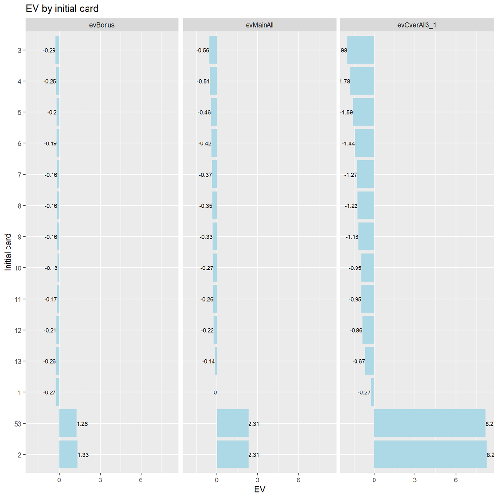

```r
# Show play bet size probabilities by initial card
cardMainValue %>%
    filter(as.integer(cardNum) %in% c(1:13, 53), keyHand=="Y") %>%
    group_by(cardNum, keyHand) %>%
    summarize(across(c(evPlay, evAll), .fns=function(x) sum(x*n)/sum(n)), .groups="drop") %>%
    full_join(filter(select(cardBonusValue, -n), keyHand=="Y", as.integer(cardNum) %in% c(1:13, 53)),
              by=c("cardNum", "keyHand")
              ) %>%
    rename(evBonus=ev, pctWinBouns=pctWin, evMainAll=evAll) %>%
    mutate(evOverAll3_1=3*evMainAll+evBonus) %>%
    select(cardNum, keyHand, evMainAll, evBonus, evOverAll3_1) %>%
    pivot_longer(-c(cardNum, keyHand)) %>%
    ggplot(aes(x=factor(cardNum, levels=c(2, 53, 1, 13:3)))) +
    geom_col(aes(y=value), fill="lightblue") +
    geom_text(aes(y=value, label=round(value,2), hjust=ifelse(value<0, 1, 0)), size=2.5) +
    labs(title="EV by initial card", x="Initial card", y="EV") +
    coord_flip() +
    facet_wrap(~name)
```

The value of holding both a wild card and a specific card (no other values known) is explored:

```r
# Average bonus value given presence of card in hand
cardWithWildValue <- map_dfr(.x=c(1:52),
                             .f=function(x) fullHandDB %>%
                                 mutate(keyHand=ifelse(handNum %in% intersect(cardInHand[[x]], cardInHand[[53]]),
                                                       "Y",
                                                       "N"
                                                       )
                                        ) %>%
                                 group_by(keyHand, betPlay) %>%
                                 summarize(n=n(),
                                           across(c(pLQ, pLN, pTQ, pTN, pWQ, pWN, evPlay, evAll), .fns=mean),
                                           .groups="drop"
                                           ),
                             .id="cardNum"
                             )
```

```r
# Check that values are suit independent
map_dfr(.x=1:13,
        .f=function(x) cardWithWildValue %>%
            filter(as.integer(cardNum) %in% (x+c(0, 13, 26, 39))) %>%
            group_by(keyHand, betPlay) %>%
            summarize(across(where(is.numeric), .fns=function(x) max(x)-min(x)), .groups="drop"),
        .id="cardRank"
        ) %>%
    summary()
```

```
##    cardRank           keyHand             betPlay            n
##  Length:60          Length:60          Min.   :0.000   Min.   :0
##  Class :character   Class :character   1st Qu.:1.000   1st Qu.:0
##  Mode  :character   Mode  :character   Median :1.000   Median :0
##                                        Mean   :1.217   Mean   :0
##                                        3rd Qu.:2.000   3rd Qu.:0
##                                        Max.   :2.000   Max.   :0
##       pLQ                 pLN         pTQ                 pTN
##  Min.   :0.000e+00   Min.   :0   Min.   :0.000e+00   Min.   :0
##  1st Qu.:0.000e+00   1st Qu.:0   1st Qu.:0.000e+00   1st Qu.:0
##  Median :0.000e+00   Median :0   Median :0.000e+00   Median :0
##  Mean   :1.388e-18   Mean   :0   Mean   :2.598e-21   Mean   :0
##  3rd Qu.:0.000e+00   3rd Qu.:0   3rd Qu.:0.000e+00   3rd Qu.:0
##  Max.   :2.776e-17   Max.   :0   Max.   :2.711e-20   Max.   :0
##       pWQ                 pWN        evPlay              evAll
##  Min.   :0.000e+00   Min.   :0   Min.   :0.000e+00   Min.   :0.000e+00
##  1st Qu.:0.000e+00   1st Qu.:0   1st Qu.:0.000e+00   1st Qu.:0.000e+00
##  Median :0.000e+00   Median :0   Median :0.000e+00   Median :0.000e+00
##  Mean   :2.776e-18   Mean   :0   Mean   :8.327e-18   Mean   :7.401e-18
##  3rd Qu.:0.000e+00   3rd Qu.:0   3rd Qu.:0.000e+00   3rd Qu.:0.000e+00
##  Max.   :5.551e-17   Max.   :0   Max.   :2.220e-16   Max.   :2.220e-16
```

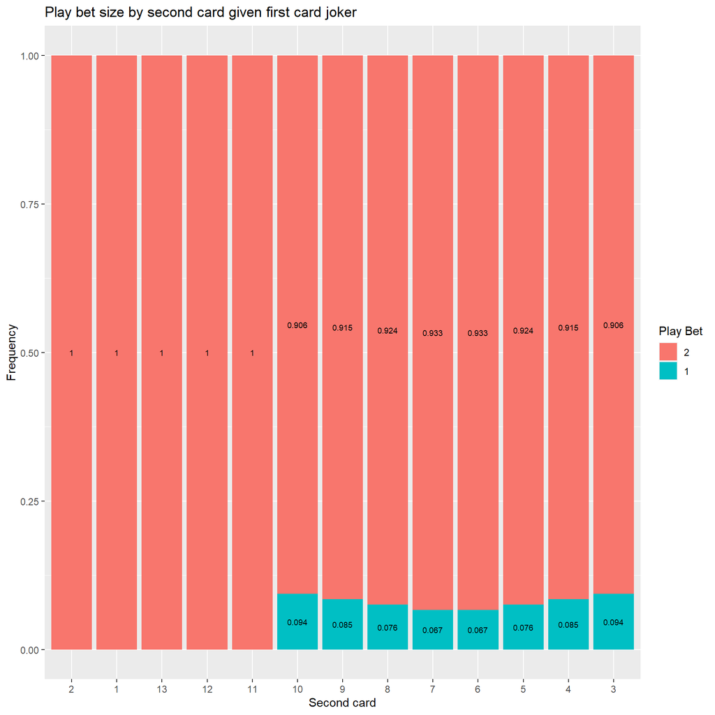

```r
# Show play bet size probabilities by second card
cardWithWildValue %>%
    filter(as.integer(cardNum) %in% c(1:13), keyHand=="Y") %>%
    group_by(cardNum) %>%
    mutate(pct=n/sum(n), cumpct=cumsum(pct)-pct/2) %>%
    ungroup() %>%
    ggplot(aes(x=factor(cardNum, levels=c(2, 1, 13:3)))) +
    geom_col(aes(y=pct, fill=fct_rev(factor(betPlay))), position="fill") +
    geom_text(aes(y=cumpct, label=round(pct,3)), size=2.5) +
    labs(title="Play bet size by second card given first card joker", x="Second card", y="Frequency") +
    scale_fill_discrete("Play Bet")
```

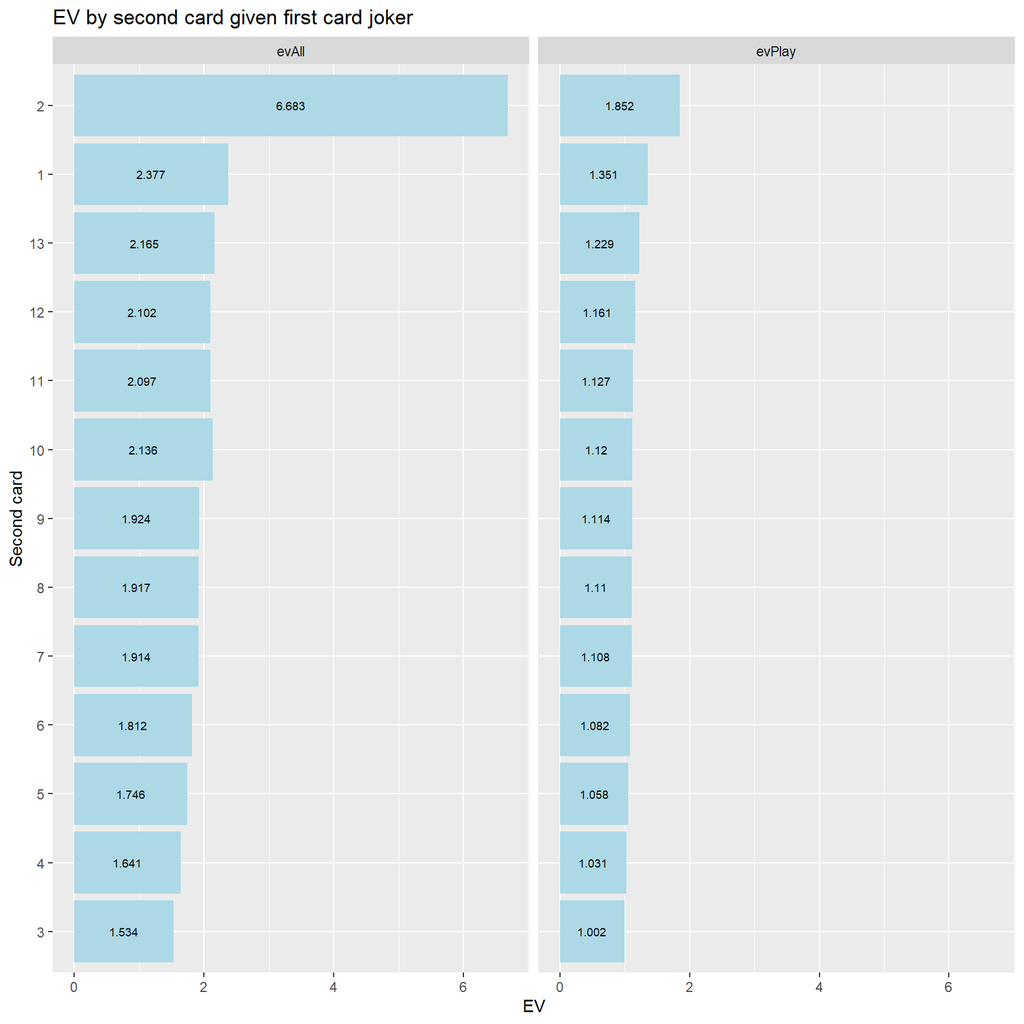

```r
# Show main bet EV by second card and bet amount
cardWithWildValue %>%
    filter(as.integer(cardNum) %in% c(1:13), keyHand=="Y") %>%
    group_by(cardNum) %>%
    summarize(across(c(evPlay, evAll), .fns=function(x) sum(x*n)/sum(n)), .groups="drop") %>%
    pivot_longer(-c(cardNum)) %>%
    ggplot(aes(x=factor(cardNum, levels=c(3:13, 1, 2)))) +
    geom_col(aes(y=value), fill="lightblue") +
    geom_text(aes(y=value/2, label=round(value,3)), size=2.5) +
    labs(title="EV by second card given first card joker", x="Second card", y="EV") +
    coord_flip() +
    facet_wrap(~name)
```

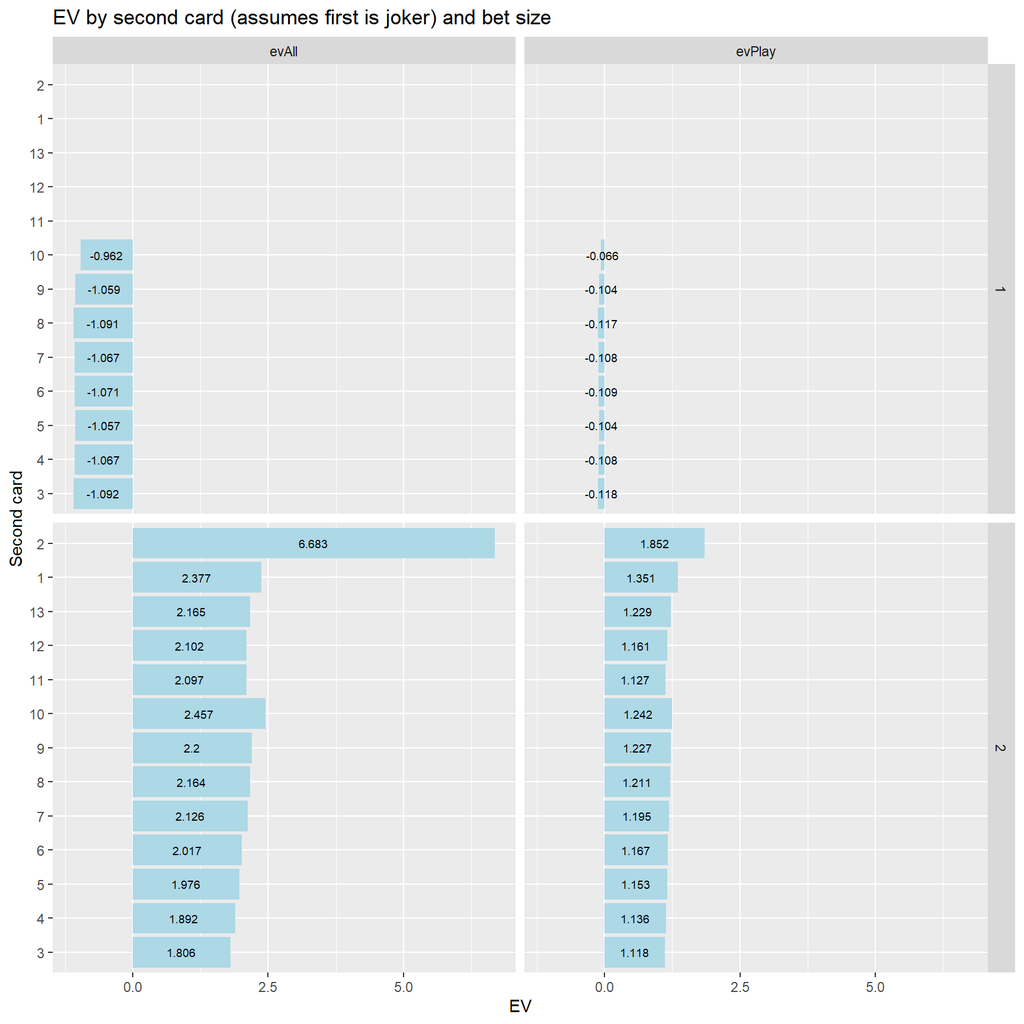

```r
# Show main bet EV by second card and bet amount
cardWithWildValue %>%
    filter(as.integer(cardNum) %in% c(1:13), keyHand=="Y") %>%
    select(cardNum, betPlay, evPlay, evAll) %>%
    pivot_longer(-c(cardNum, betPlay)) %>%
    ggplot(aes(x=factor(cardNum, levels=c(3:13, 1, 2)))) +
    geom_col(aes(y=value), fill="lightblue") +
    geom_text(aes(y=value/2, label=round(value,3)), size=2.5) +
    labs(title="EV by second card (assumes first is joker) and bet size", x="Second card", y="EV") +
    coord_flip() +
    facet_grid(betPlay~name)
```

The value of holding two cards (not each of the same suit) is explored:

```r
# Average main value given presence of two unsuited cards in hand
cardFirstTwoValue <- map2(.x=rep(1:13, each=13),
                          .y=rep(14:26, times=13),
                          .f=function(x, y) fullHandDB %>%
                              mutate(keyHand=ifelse(handNum %in% intersect(cardInHand[[x]], cardInHand[[y]]),
                                                    "Y",
                                                    "N"
                                                    ),
                                     card1=x,
                                     card2=y
                                     ) %>%
                              group_by(keyHand, betPlay, card1, card2) %>%
                              summarize(n=n(),
                                        across(c(pLQ, pLN, pTQ, pTN, pWQ, pWN, evPlay, evAll), .fns=mean),
                                        .groups="drop"
                                        )
                          )
```

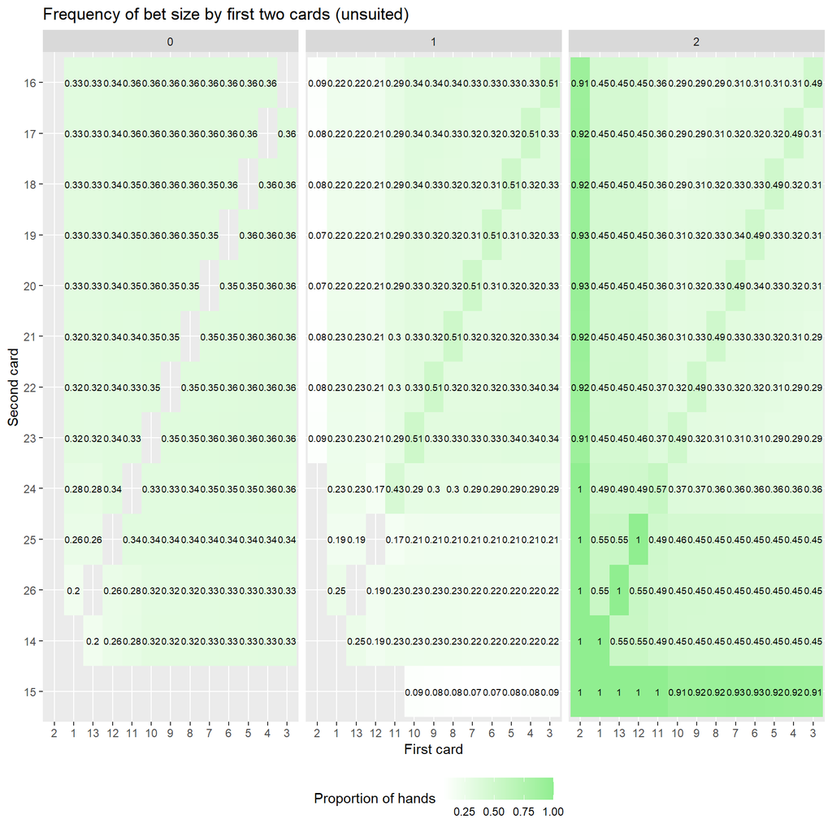

```r
# Show play bet size probabilities by first two cards
cardFirstTwoValue %>%
    list_rbind() %>%
    filter(card1 != card2, keyHand=="Y") %>%
    group_by(card1, card2) %>%
    mutate(pct=n/sum(n)) %>%
    ungroup() %>%
    ggplot(aes(x=factor(card1, levels=c(2, 1, 13:3)), y=factor(card2, levels=c(15, 14, 26:16)))) +
    geom_tile(aes(fill=pct)) +
    geom_text(aes(label=round(pct,2)), size=2.5) +
    labs(title="Frequency of bet size by first two cards (unsuited)", x="First card", y="Second card") +
    facet_wrap(~betPlay) +
    scale_fill_continuous("Proportion of hands", high="lightgreen", low="white") +
    theme(legend.position = "bottom")
```

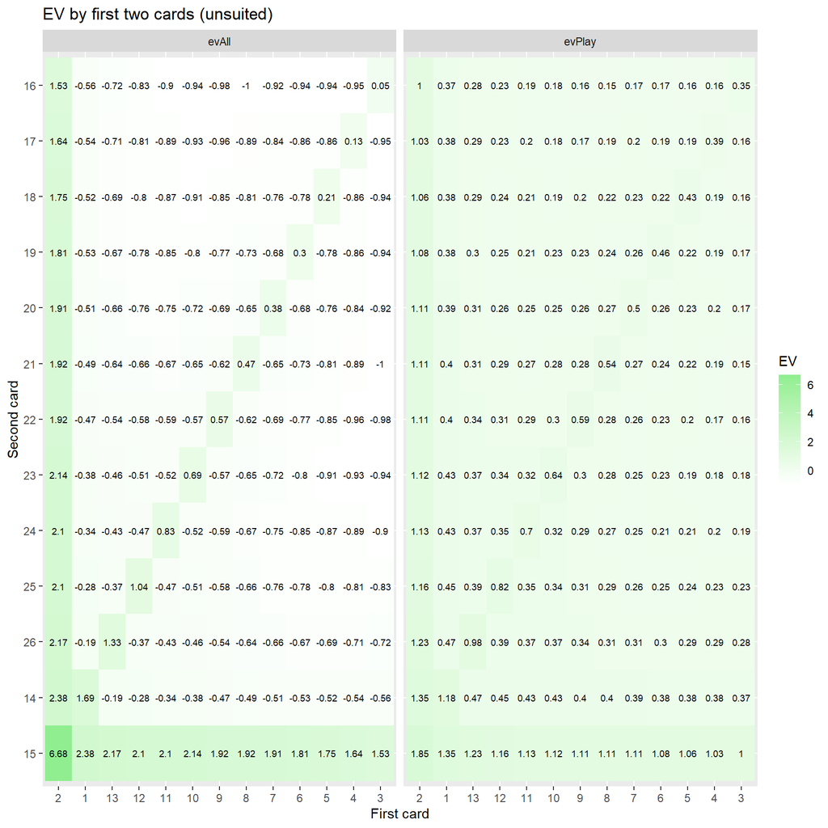

```r
# Show main bet EV by second card
cardFirstTwoValue %>%
    list_rbind() %>%
    filter(card1 != card2, keyHand=="Y") %>%
    group_by(card1, card2) %>%
    summarize(across(c(evPlay, evAll), .fns=function(x) sum(x*n)/sum(n)), .groups="drop") %>%
    pivot_longer(-c(card1, card2)) %>%
    ggplot(aes(x=factor(card1, levels=c(2, 1, 13:3)), y=factor(card2, levels=c(15, 14, 26:16)))) +
    geom_tile(aes(fill=value)) +
    geom_text(aes(label=round(value,2)), size=2.5) +
    labs(title="EV by first two cards (unsuited)", x="First card", y="Second card") +
    facet_wrap(~name) +
    scale_fill_continuous("EV", high="lightgreen", low="white")
```

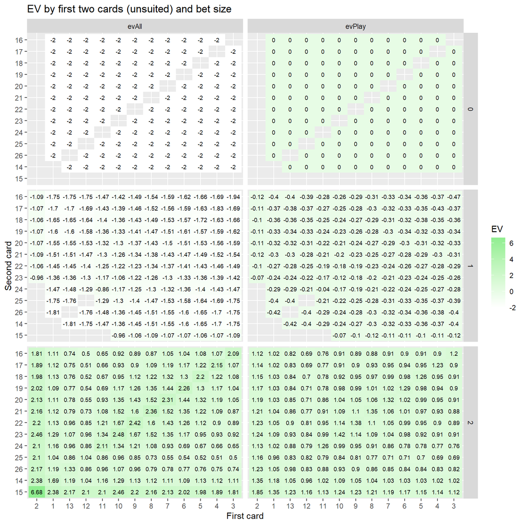

```r
# Show main bet EV by second card and bet amount
cardFirstTwoValue %>%
    list_rbind() %>%
    filter(card1 != card2, keyHand=="Y") %>%
    select(card1, card2, betPlay, evPlay, evAll) %>%
    pivot_longer(-c(card1, card2, betPlay)) %>%
    ggplot(aes(x=factor(card1, levels=c(2, 1, 13:3)), y=factor(card2, levels=c(15, 14, 26:16)))) +
    geom_tile(aes(fill=value)) +
    geom_text(aes(label=round(value,2)), size=2.5) +
    labs(title="EV by first two cards (unsuited) and bet size", x="First card", y="Second card") +
    facet_grid(betPlay~name) +
    scale_fill_continuous("EV", high="lightgreen", low="white")
```

```r
# Average main value given presence of two unsuited cards in hand
cardFirstTwoSuitedValue <- map2(.x=rep(1:13, each=13),
                                .y=rep(1:13, times=13),
                                .f=function(x, y) fullHandDB %>%
                                    mutate(keyHand=ifelse(handNum %in% intersect(cardInHand[[x]], cardInHand[[y]]),
                                                          "Y",
                                                          "N"
                                                          ),
                                           card1=x,
                                           card2=y
                                           ) %>%
                                    group_by(keyHand, betPlay, card1, card2) %>%
                                    summarize(n=n(),
                                              across(c(pLQ, pLN, pTQ, pTN, pWQ, pWN, evPlay, evAll), .fns=mean),
                                              .groups="drop"
                                              )
                                )
```

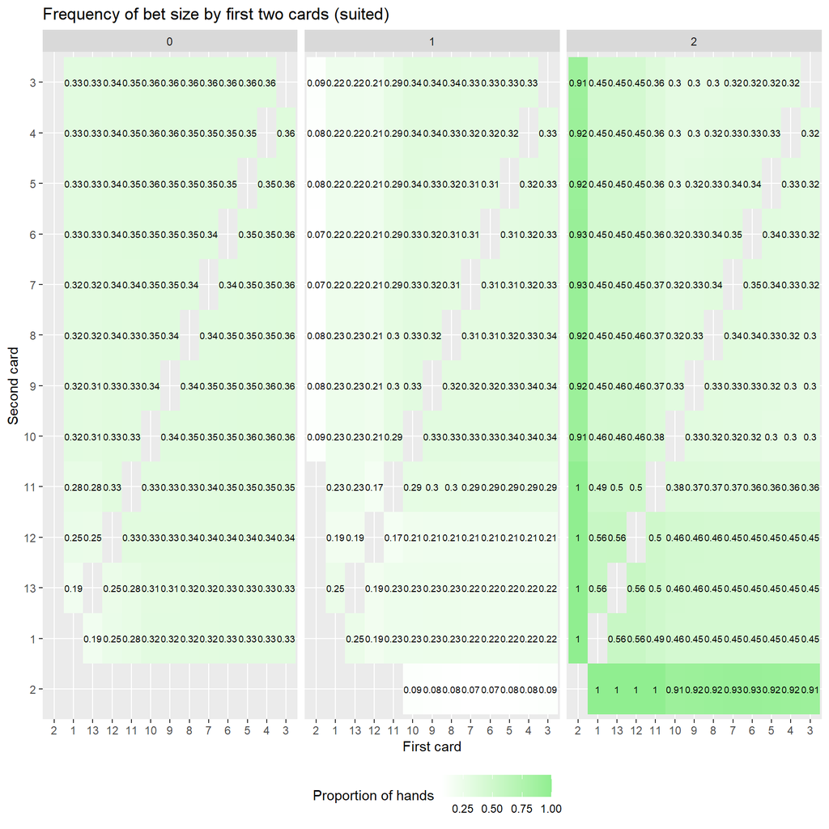

```r
# Show play bet size probabilities by first two cards (suited)
cardFirstTwoSuitedValue %>%
    list_rbind() %>%
    filter(card1 != card2, keyHand=="Y") %>%
    group_by(card1, card2) %>%
    mutate(pct=n/sum(n)) %>%
    ungroup() %>%
    ggplot(aes(x=factor(card1, levels=c(2, 1, 13:3)), y=factor(card2, levels=c(2, 1, 13:3)))) +
    geom_tile(aes(fill=pct)) +
    geom_text(aes(label=round(pct,2)), size=2.5) +
    labs(title="Frequency of bet size by first two cards (suited)", x="First card", y="Second card") +
    facet_wrap(~betPlay) +
    scale_fill_continuous("Proportion of hands", high="lightgreen", low="white") +
    theme(legend.position = "bottom")
```

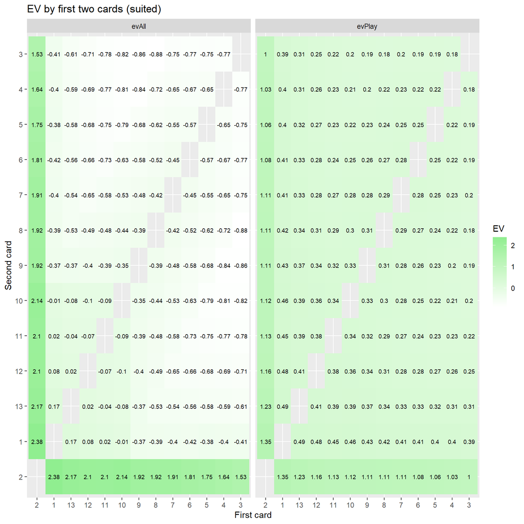

```r
# Show main bet EV by first two cards (suited)
cardFirstTwoSuitedValue %>%
    list_rbind() %>%
    filter(card1 != card2, keyHand=="Y") %>%
    group_by(card1, card2) %>%
    summarize(across(c(evPlay, evAll), .fns=function(x) sum(x*n)/sum(n)), .groups="drop") %>%
    pivot_longer(-c(card1, card2)) %>%
    ggplot(aes(x=factor(card1, levels=c(2, 1, 13:3)), y=factor(card2, levels=c(2, 1, 13:3)))) +
    geom_tile(aes(fill=value)) +
    geom_text(aes(label=round(value,2)), size=2.5) +
    labs(title="EV by first two cards (suited)", x="First card", y="Second card") +
    facet_wrap(~name) +
    scale_fill_continuous("EV", high="lightgreen", low="white")
```

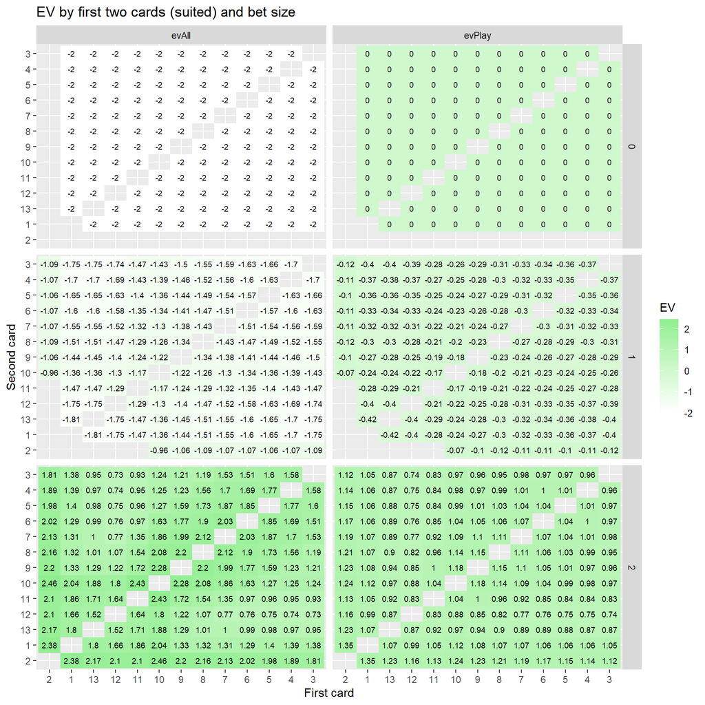

```r
# Show main bet EV by first two cards (suited) and bet amount
cardFirstTwoSuitedValue %>%
    list_rbind() %>%
    filter(card1 != card2, keyHand=="Y") %>%
    select(card1, card2, betPlay, evPlay, evAll) %>%
    pivot_longer(-c(card1, card2, betPlay)) %>%
    ggplot(aes(x=factor(card1, levels=c(2, 1, 13:3)), y=factor(card2, levels=c(2, 1, 13:3)))) +
    geom_tile(aes(fill=value)) +
    geom_text(aes(label=round(value,2)), size=2.5) +
    labs(title="EV by first two cards (suited) and bet size", x="First card", y="Second card") +
    facet_grid(betPlay~name) +
    scale_fill_continuous("EV", high="lightgreen", low="white")
```

An attempt is made to improve the hand exclusion process. The cards by hand matrix is created:

```r
# Matrix of 1/0 for whether card is in hand
fullHandMatrix <- matrix(rep(0L, 53*choose(53,5)), nrow=choose(53,5), ncol=53)
for(intCtr in 1:53) {
    fullHandMatrix[cardInHand[[intCtr]], intCtr] <- 1L
}
colSums(fullHandMatrix)
```

```
##  [1] 270725 270725 270725 270725 270725 270725 270725 270725 270725 270725
## [11] 270725 270725 270725 270725 270725 270725 270725 270725 270725 270725
## [21] 270725 270725 270725 270725 270725 270725 270725 270725 270725 270725
## [31] 270725 270725 270725 270725 270725 270725 270725 270725 270725 270725
## [41] 270725 270725 270725 270725 270725 270725 270725 270725 270725 270725
## [51] 270725 270725 270725
```

```r
# Select a subset of fullHandMatrix to be the exclusions
t <- proc.time()

set.seed(23022216)
exclMatrix <- fullHandMatrix[sample(1:nrow(fullHandMatrix), 10, replace=FALSE), ]

# Matrix math of the exclusions, run row by row of exclMatrix
map(1:10,
    .f=function(x)
        sortedHandRanks[which((fullHandMatrix %*% t(exclMatrix[x,,drop=FALSE]))>0),] %>% count(rank)
    ) %>% str
```

```
## List of 10
##  $ : tibble [4,314 × 2] (S3: tbl_df/tbl/data.frame)
##   ..$ rank: num [1:4314] 2 4 5 13 14 15 16 20 21 22 ...
##   ..$ n   : int [1:4314] 196 65 65 105 70 91 56 242 233 105 ...
##  $ : tibble [4,679 × 2] (S3: tbl_df/tbl/data.frame)
##   ..$ rank: num [1:4679] 2 6 8 9 13 14 15 16 17 18 ...
##   ..$ n   : int [1:4679] 126 65 70 70 70 70 177 233 168 112 ...
##  $ : tibble [4,678 × 2] (S3: tbl_df/tbl/data.frame)
##   ..$ rank: num [1:4678] 1 2 3 4 5 6 7 8 9 10 ...
##   ..$ n   : int [1:4678] 1 640 53 53 53 87 87 69 69 69 ...
##  $ : tibble [4,679 × 2] (S3: tbl_df/tbl/data.frame)
##   ..$ rank: num [1:4679] 2 4 6 7 9 13 15 16 17 18 ...
##   ..$ n   : int [1:4679] 322 65 65 65 70 70 147 233 168 112 ...
##  $ : tibble [4,671 × 2] (S3: tbl_df/tbl/data.frame)
##   ..$ rank: num [1:4671] 1 2 3 4 5 6 7 8 9 10 ...
##   ..$ n   : int [1:4671] 1 605 53 53 87 87 53 104 104 69 ...
##  $ : tibble [4,314 × 2] (S3: tbl_df/tbl/data.frame)
##   ..$ rank: num [1:4314] 2 6 8 11 13 15 16 17 18 19 ...
##   ..$ n   : int [1:4314] 252 95 70 70 70 177 147 147 121 91 ...
##  $ : tibble [4,310 × 2] (S3: tbl_df/tbl/data.frame)
##   ..$ rank: num [1:4310] 1 2 3 4 5 6 7 8 9 10 ...
##   ..$ n   : int [1:4310] 1 815 84 84 99 84 84 104 104 119 ...
##  $ : tibble [3,729 × 2] (S3: tbl_df/tbl/data.frame)
##   ..$ rank: num [1:3729] 1 2 3 4 5 6 7 8 9 10 ...
##   ..$ n   : int [1:3729] 1 780 84 84 84 84 84 104 104 104 ...
##  $ : tibble [4,675 × 2] (S3: tbl_df/tbl/data.frame)
##   ..$ rank: num [1:4675] 1 2 3 4 5 6 7 8 9 10 ...
##   ..$ n   : int [1:4675] 1 640 53 87 87 53 53 104 69 104 ...
##  $ : tibble [4,675 × 2] (S3: tbl_df/tbl/data.frame)
##   ..$ rank: num [1:4675] 1 2 3 4 5 6 7 8 9 10 ...
##   ..$ n   : int [1:4675] 1 605 53 53 87 53 87 104 69 104 ...
```

```r
proc.time() - t
```

```
##    user  system elapsed
##   10.00    4.14   14.95
```

```r
# Existing process
t <- proc.time()
calculateResults(useHandNums=1:10)
```

```
## # A tibble: 10 × 16
##        pLQ   pLN       pTQ   pTN   pWQ   pWN       n pWNoTie  rank  type handNum
##      <dbl> <dbl>     <dbl> <dbl> <dbl> <dbl>   <int>   <dbl> <dbl> <dbl>   <int>
##  1 0.00156     0 0.0000596     0 0.702 0.297 1712304   0.998    22     4       1
##  2 0.0243      0 0.0000158     0 0.679 0.297 1712304   0.976   404     7       2
##  3 0.0243      0 0.0000158     0 0.679 0.297 1712304   0.976   401     7       3
##  4 0.0242      0 0.0000263     0 0.679 0.297 1712304   0.976   395     7       4
##  5 0.0240      0 0.0000263     0 0.679 0.297 1712304   0.976   385     7       5
##  6 0.0236      0 0.0000263     0 0.679 0.297 1712304   0.976   370     7       6
##  7 0.0231      0 0.0000263     0 0.680 0.297 1712304   0.977   349     7       7
##  8 0.0224      0 0.0000438     0 0.681 0.297 1712304   0.978   321     7       8
##  9 0.0224      0 0.0000438     0 0.681 0.297 1712304   0.978   321     7       9
## 10 0.0639      0 0.0000210     0 0.643 0.293 1712304   0.936  1134     9      10
## # … with 5 more variables: betPlay <dbl>, evAnte <dbl>, evPlay <dbl>,
## #   evBlind <dbl>, evAll <dbl>
```

```r
proc.time() - t
```

```
##    user  system elapsed
##    4.67    1.17    5.88
```

```r
cat("\nThe existing process would take around", round(choose(53,5) * 5 / 10 / 60), "minutes for all hands\n")
```

```
##
## The existing process would take around 23914 minutes for all hands
```

While slow, the existing process is much faster than the attempted conversion to matrix math. Further exploration can potentially focus on optimizing calculateResults() and downstream functions:

```r
# Timing impact for union of cards in hand (9 hands per second, 0.11 seconds per hand)
t <- proc.time()
for(intCtr in 1:100) tmp <- purrr::reduce(.x=cardInHand[c(1, 2, 3, 4, 5)], .f=union)
proc.time() - t
```

```
##    user  system elapsed
##    9.28    2.23   11.53
```

```r
# Timing impact for finding hand values (2.5 hands per second, 0.4 seconds per hand)
tmpRank <- sortedHandRanks$rank[1]
t <- proc.time()
for(intCtr in 1:100) {
    sortedHandRanks %>%
        filter(!(handNum %in% tmp)) %>%
        summarize(pLQ=mean(qual=="Q" & rank<tmpRank),
                  pLN=mean(qual=="N" & rank<tmpRank),
                  pTQ=mean(qual=="Q" & rank==tmpRank),
                  pTN=mean(qual=="N" & rank==tmpRank),
                  pWQ=mean(qual=="Q" & rank>tmpRank),
                  pWN=mean(qual=="N" & rank>tmpRank),
                  n=n()
                  ) %>%
        mutate(pWNoTie=(pWQ+pWN)/(1-pTQ-pTN), rank=tmpRank)
}
proc.time() - t
```

```
##    user  system elapsed
##   32.05    8.63   40.84
```

The function for assessing probabilities of win, tie, lose, and qualify takes ~80% of the time, and is a candidate for further exploration:

```r
t <- proc.time()
for(intCtr in 1:100) {
    sortedHandRanks %>%
        filter(!(handNum %in% tmp)) %>%
        mutate(result=case_when(rank < tmpRank ~ "L",
                                rank==tmpRank ~ "T",
                                rank > tmpRank ~ "W",
                                TRUE ~ "Error"
                                )
               ) %>%
        count(qual, result)
}
proc.time() - t
```

```
##    user  system elapsed
##   34.02   10.86   44.97
```

```r
t <- proc.time()
for(intCtr in 1:100) {
    sortedHandRanks %>%
        filter(!(handNum %in% tmp))
}
proc.time() - t
```

```
##    user  system elapsed
##   16.04    6.48   22.93
```

```r
t <- proc.time()
for(intCtr in 1:100) {
    smallSorted %>%
        filter(!(handNum %in% tmp))
}
proc.time() - t
```

```
##    user  system elapsed
##   12.64    3.22   15.88
```

Creating a variable and then counting is slower than summarizing. A significant chunk of the time is in the filtering to only the relevant hands. Most of the time takes place in the actual filtering step, even if extraneous columns of the database are deleted

The total number of hands can be reduced by taking advantage of suit indifference (e.g., there are a hand has the same value if all its spades became hearts and all its hearts became spades). For hands with no wilds, there are the following combinations:

- 5-0-0-0 (flushes)
- 4-1-0-0
- 3-2-0-0
- 3-1-1-0
- 2-2-1-0
- 2-1-1-1

All hands of a given type can be simulated using the first suit for the maximum number of cards:

```r
# Get count by suit for each hand type
handSuit <- tibble::tibble(handNum=1:nrow(mtxHands),
                           nWild=mtxHands %in% c(2, 15, 28, 41, 53) %>% matrix(ncol=5, byrow=FALSE) %>% rowSums,
                           n1=mtxHands %in% c(1, 3:13) %>% matrix(ncol=5, byrow=FALSE) %>% rowSums,
                           n2=mtxHands %in% c(14, 16:26) %>% matrix(ncol=5, byrow=FALSE) %>% rowSums,
                           n3=mtxHands %in% c(27, 29:39) %>% matrix(ncol=5, byrow=FALSE) %>% rowSums,
                           n4=mtxHands %in% c(40, 42:52) %>% matrix(ncol=5, byrow=FALSE) %>% rowSums
                           )
handSuit
```

```
## # A tibble: 2,869,685 × 6
##    handNum nWild    n1    n2    n3    n4
##      <int> <dbl> <dbl> <dbl> <dbl> <dbl>
##  1       1     1     4     0     0     0
##  2       2     1     4     0     0     0
##  3       3     1     4     0     0     0
##  4       4     1     4     0     0     0
##  5       5     1     4     0     0     0
##  6       6     1     4     0     0     0
##  7       7     1     4     0     0     0
##  8       8     1     4     0     0     0
##  9       9     1     4     0     0     0
## 10      10     1     3     1     0     0
## # … with 2,869,675 more rows
```

```r
# Filter for only descending order
handSuit %>%
    filter(n2 <= n1, n3 <= n2, n4 <= n3) %>%
    count(nWild, n1, n2, n3, n4)
```

```
## # A tibble: 18 × 6
##    nWild    n1    n2    n3    n4      n
##    <dbl> <dbl> <dbl> <dbl> <dbl>  <int>
##  1     0     2     1     1     1 114048
##  2     0     2     2     1     0  52272
##  3     0     3     1     1     0  31680
##  4     0     3     2     0     0  14520
##  5     0     4     1     0     0   5940
##  6     0     5     0     0     0    792
##  7     1     1     1     1     1 103680
##  8     1     2     1     1     0  47520
##  9     1     2     2     0     0  21780
## 10     1     3     1     0     0  13200
## 11     1     4     0     0     0   2475
## 12     2     1     1     1     0  17280
## 13     2     2     1     0     0   7920
## 14     2     3     0     0     0   2200
## 15     3     1     1     0     0   1440
## 16     3     2     0     0     0    660
## 17     4     1     0     0     0     60
## 18     5     0     0     0     0      1
```

There is still significant duplication in this data, as 4s-3s-A-K-Q and 4s-3s-K-A-Q are the same for 2-1-1-1. But just this initial filtering reduces the volume to simulate by a factor of 6-7. As an example, the natural hands with no pair that are A-K-J-x-x are explored:

```r
# Key hands to use - Filter for only descending order
handEligible <- handSuit %>%
    filter(n2 <= n1, n3 <= n2, n4 <= n3)
handEligible
```

```
## # A tibble: 437,468 × 6
##    handNum nWild    n1    n2    n3    n4
##      <int> <dbl> <dbl> <dbl> <dbl> <dbl>
##  1       1     1     4     0     0     0
##  2       2     1     4     0     0     0
##  3       3     1     4     0     0     0
##  4       4     1     4     0     0     0
##  5       5     1     4     0     0     0
##  6       6     1     4     0     0     0
##  7       7     1     4     0     0     0
##  8       8     1     4     0     0     0
##  9       9     1     4     0     0     0
## 10      10     1     3     1     0     0
## # … with 437,458 more rows
```

```r
# Eligible hands of type AKJxx
eligibleAKJxx <- allHandRanks %>%
    filter(wType==99, tb1==14, tb2==13, tb3 == 11) %>%
    semi_join(handEligible, by=c("handNum"))
eligibleAKJxx
```

```
## # A tibble: 3,500 × 9
##    handNum wType   tb1   tb2   tb3   tb4   tb5 chgRank  rank
##      <int> <dbl> <dbl> <dbl> <dbl> <dbl> <dbl>   <dbl> <dbl>
##  1  121745    99    14    13    11    10     9       1  4415
##  2  121824    99    14    13    11    10     9       0  4415
##  3  122200    99    14    13    11    10     9       0  4415
##  4  122213    99    14    13    11    10     9       0  4415
##  5  122266    99    14    13    11    10     9       0  4415
##  6  122684    99    14    13    11    10     9       0  4415
##  7  123032    99    14    13    11    10     9       0  4415
##  8  123045    99    14    13    11    10     9       0  4415
##  9  123126    99    14    13    11    10     9       0  4415
## 10  124630    99    14    13    11    10     9       0  4415
## # … with 3,490 more rows
```

```r
# Create tibble of hand types
mtxSmallTest <- mtxHands[eligibleAKJxx$handNum,]
tblSmallTest <- tibble::as_tibble(mtxSmallTest, .name_repair=make.names) %>%
    purrr::set_names(paste0("V", 1:5)) %>%
    mutate(handNum=eligibleAKJxx$handNum)
tblSmallTest
```

```
## # A tibble: 3,500 × 6
##       V1    V2    V3    V4    V5 handNum
##    <int> <int> <int> <int> <int>   <int>
##  1     1     9    10    11    26  121745
##  2     1     9    10    13    24  121824
##  3     1     9    10    24    26  122200
##  4     1     9    10    24    39  122213
##  5     1     9    10    26    37  122266
##  6     1     9    11    13    23  122684
##  7     1     9    11    23    26  123032
##  8     1     9    11    23    39  123045
##  9     1     9    11    26    36  123126
## 10     1     9    13    23    24  124630
## # … with 3,490 more rows
```

```r
# Get suit counts of descending cards
tmpCheckSuits <- tblSmallTest %>%
    pivot_longer(-c(handNum)) %>%
    mutate(rank=1 + (value-1) %% 13, rank=ifelse(rank==1, 14, rank), suit=(value-1) %/% 13) %>%
    arrange(handNum, desc(rank))
tmpCheckSuits
```

```
## # A tibble: 17,500 × 5
##    handNum name  value  rank  suit
##      <int> <chr> <int> <dbl> <dbl>
##  1   21113 V1        1    14     0
##  2   21113 V5       26    13     1
##  3   21113 V4       11    11     0
##  4   21113 V3        4     4     0
##  5   21113 V2        3     3     0
##  6   21192 V1        1    14     0
##  7   21192 V4       13    13     0
##  8   21192 V5       24    11     1
##  9   21192 V3        4     4     0
## 10   21192 V2        3     3     0
## # … with 17,490 more rows
```

```r
# Get count of hands with Ace as first suit, King as first or second suit - 1,120 hands
tmpAKJxxUse <- tmpCheckSuits %>%
    filter((rank==14 & suit==0) | (rank==13 & suit %in% c(0, 1))) %>%
    group_by(handNum) %>%
    summarize(n=n()) %>%
    filter(n==2)
tmpAKJxxUse
```

```
## # A tibble: 1,120 × 2
##    handNum     n
##      <int> <int>
##  1   21113     2
##  2   21192     2
##  3   21568     2
##  4   21634     2
##  5   22241     2
##  6   22320     2
##  7   22696     2
##  8   22762     2
##  9   23322     2
## 10   23401     2
## # … with 1,110 more rows
```

```r
# Run for example hand of AKJxx that have A as suit 1 and K as suit 1 or 2
t <- proc.time()
resAKJxx <- calculateResults(useHandNums=tmpAKJxxUse$handNum)
proc.time()-t
```

```
##    user  system elapsed
##  535.17  121.46  664.25
```

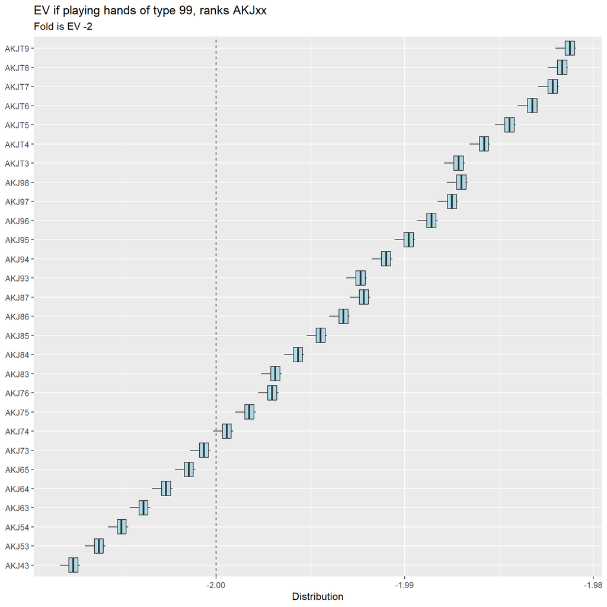

```r
# Plot of EV by hand type
resAKJxx %>%
    mutate(evAllIfPlay=2*pWQ+pWN-3*pLQ-3*pLN) %>%
    left_join(tmpCheckSuits %>%
                  filter(!(rank %in% c(14, 13, 11))) %>%
                  group_by(handNum) %>%
                  mutate(label=paste0("AKJ", max(rank), min(rank)), label=str_replace(label, "10", "T")) %>%
                  filter(row_number()==1) %>%
                  ungroup(),
              by="handNum"
              ) %>%
    ggplot(aes(x=factor(label))) +
    coord_flip() +
    labs(x=NULL,
         y="Distribution",
         title="EV if playing hands of type 99, ranks AKJxx",
         subtitle="Fold is EV -2"
         ) +
    geom_boxplot(aes(y=evAllIfPlay), fill="lightblue") +
    geom_hline(yintercept=-2, lty=2)
```

Significant reductions in processing time can be achieved through systemizing an approach like this. Additional hand types of Ace-high are also explored:

```r
# Eligible hands of type AKxxx (excluding AKJxx, already created)
eligibleAKxxx <- allHandRanks %>%
    filter(wType==99, tb1==14, tb2==13, tb3 != 11) %>%
    semi_join(handEligible, by=c("handNum"))
eligibleAKxxx
```

```
## # A tibble: 11,375 × 9
##    handNum wType   tb1   tb2   tb3   tb4   tb5 chgRank  rank
##      <int> <dbl> <dbl> <dbl> <dbl> <dbl> <dbl>   <dbl> <dbl>
##  1  122647    99    14    13    12    11     9       1  4380
##  2  122686    99    14    13    12    11     9       0  4380
##  3  123089    99    14    13    12    11     9       0  4380
##  4  123102    99    14    13    12    11     9       0  4380
##  5  123128    99    14    13    12    11     9       0  4380
##  6  123505    99    14    13    12    11     9       0  4380
##  7  123881    99    14    13    12    11     9       0  4380
##  8  123894    99    14    13    12    11     9       0  4380
##  9  123947    99    14    13    12    11     9       0  4380
## 10  124660    99    14    13    12    11     9       0  4380
## # … with 11,365 more rows
```

```r
# Create tibble of hand types
mtxSmallTest <- mtxHands[eligibleAKxxx$handNum,]
tblSmallTest <- tibble::as_tibble(mtxSmallTest, .name_repair=make.names) %>%
    purrr::set_names(paste0("V", 1:5)) %>%
    mutate(handNum=eligibleAKxxx$handNum)
tblSmallTest
```

```
## # A tibble: 11,375 × 6
##       V1    V2    V3    V4    V5 handNum
##    <int> <int> <int> <int> <int>   <int>
##  1     1     9    11    12    26  122647
##  2     1     9    11    13    25  122686
##  3     1     9    11    25    26  123089
##  4     1     9    11    25    39  123102
##  5     1     9    11    26    38  123128
##  6     1     9    12    13    24  123505
##  7     1     9    12    24    26  123881
##  8     1     9    12    24    39  123894
##  9     1     9    12    26    37  123947
## 10     1     9    13    24    25  124660
## # … with 11,365 more rows
```

```r
# Get suit counts of descending cards
tmpCheckSuits <- tblSmallTest %>%
    pivot_longer(-c(handNum)) %>%
    mutate(rank=1 + (value-1) %% 13, rank=ifelse(rank==1, 14, rank), suit=(value-1) %/% 13) %>%
    arrange(handNum, desc(rank))
tmpCheckSuits
```

```
## # A tibble: 56,875 × 5
##    handNum name  value  rank  suit
##      <int> <chr> <int> <dbl> <dbl>
##  1   20846 V1        1    14     0
##  2   20846 V5       26    13     1
##  3   20846 V4        5     5     0
##  4   20846 V3        4     4     0
##  5   20846 V2        3     3     0
##  6   20893 V1        1    14     0
##  7   20893 V5       26    13     1
##  8   20893 V4        6     6     0
##  9   20893 V3        4     4     0
## 10   20893 V2        3     3     0
## # … with 56,865 more rows
```

```r
# Get count of hands with Ace as first suit, King as first or second suit - 3,640 hands
tmpAKxxxUse <- tmpCheckSuits %>%
    filter((rank==14 & suit==0) | (rank==13 & suit %in% c(0, 1))) %>%
    group_by(handNum) %>%
    summarize(n=n()) %>%
    filter(n==2)
tmpAKxxxUse
```

```
## # A tibble: 3,640 × 2
##    handNum     n
##      <int> <int>
##  1   20846     2
##  2   20893     2
##  3   20939     2
##  4   20984     2
##  5   21028     2
##  6   21071     2
##  7   21154     2
##  8   21186     2
##  9   21187     2
## 10   21188     2
## # … with 3,630 more rows
```

```r
# Run for all hands of AKxxx (except for AKJxx, previously run)
t <- proc.time()
resAKxxx <- calculateResults(useHandNums=tmpAKxxxUse$handNum)
proc.time()-t
```

```
##    user  system elapsed
## 2027.05  453.35 2627.75
```

```r
# Save file for use later
resAK99 <- resAKJxx %>%
    bind_rows(resAKxxx)
saveToRDS(resAK99, ovrWriteError=FALSE)
```

```
##
## File already exists: ./RInputFiles/Coronavirus/resAK99.RDS
##
## Not replacing the existing file since ovrWrite=FALSE
```

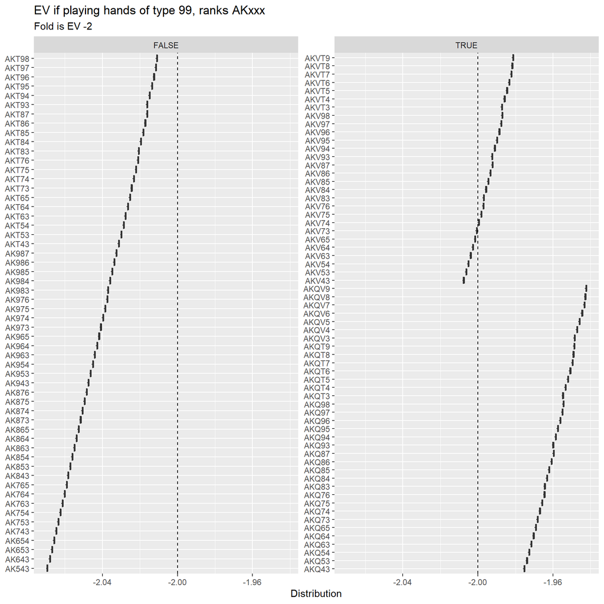

```r
tmpHR <- allHandRanks %>%
    filter(wType==99, tb1==14, tb2==13) %>%
    semi_join(handEligible, by=c("handNum")) %>%
    pull(handNum)

tmpHS <- mtxHands[tmpHR,] %>%
    tibble::as_tibble(.name_repair=make.names) %>%
    purrr::set_names(paste0("V", 1:5)) %>%
    mutate(handNum=tmpHR) %>%
    pivot_longer(-c(handNum)) %>%
    mutate(rank=1 + (value-1) %% 13, rank=ifelse(rank==1, 14, rank), suit=(value-1) %/% 13) %>%
    arrange(handNum, desc(rank))

# Plot of EV by hand type
resAK99 %>%
    mutate(evAllIfPlay=2*pWQ+pWN-3*pLQ-3*pLN) %>%
    left_join(tmpHS %>%
                  filter(!(rank %in% c(14, 13))) %>%
                  group_by(handNum) %>%
                  mutate(label=paste0("AK", max(rank), nth(rank, 2), min(rank)),
                         label=str_replace(label, "12", "Q"),
                         label=str_replace(label, "11", "V"),
                         label=str_replace(label, "10", "T"),
                         card3=str_sub(label, 3, 3)
                         ) %>%
                  filter(row_number()==1) %>%
                  ungroup(),
              by="handNum"
              ) %>%
    ggplot(aes(x=factor(label))) +
    coord_flip() +
    labs(x=NULL,
         y="Distribution",
         title="EV if playing hands of type 99, ranks AKxxx",
         subtitle="Fold is EV -2"
         ) +
    geom_boxplot(aes(y=evAllIfPlay), fill="lightblue") +
    geom_hline(yintercept=-2, lty=2) +
    facet_wrap(~(card3 %in% c("Q", "V")), scales="free_y")
```

The file is explored for hands with identical win probabilities:

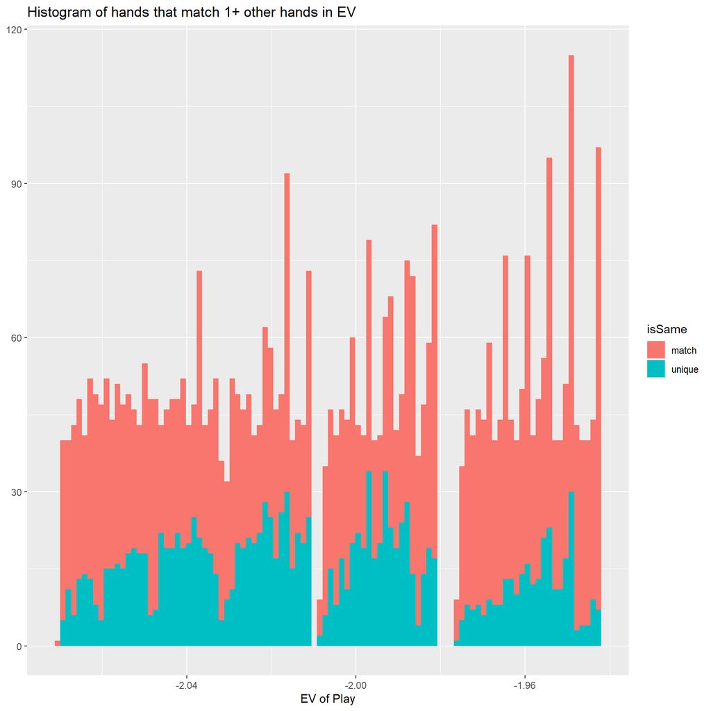

```r
testSameEV <- resAK99 %>%
    arrange(pWN, pTN, pLN, pLQ) %>%
    group_by(rank) %>%
    mutate(across(c(pWN, pTN, pLN, pLQ),
                  .fns=function(x) ifelse(row_number()==1, 0, x-lag(x)),
                  .names="{.col}_lag"
                  ),
           across(c(pWN, pTN, pLN, pLQ),
                  .fns=function(x) ifelse(row_number()==1, 0, lead(x)-x),
                  .names="{.col}_lead"
                  ),
           maxLag=pmax(abs(pWN_lag), abs(pTN_lag), abs(pLN_lag), abs(pLQ_lag)),
           maxLead=pmax(abs(pWN_lead), abs(pTN_lead), abs(pLN_lead), abs(pLQ_lead))
           ) %>%
    ungroup()

testSameEV %>%
    mutate(evPlay=2*pWQ+pWN-3*pLQ-3*pLN, isSame=ifelse(maxLag<=1e-9 | maxLead <= 1e-9, "match", "unique")) %>%
    ggplot(aes(x=evPlay)) +
    geom_histogram(aes(fill=isSame), bins=100) +
    labs(x="EV of Play", y=NULL, title="Histogram of hands that match 1+ other hands in EV")
```

```r
# Hands of same rank (4380) and EV - AKQJ9
testSameEV %>%
    filter(rank==4380) %>%
    filter(evPlay==max(evPlay)) %>%
    pull(handNum) %>%
    mtxHands[.,]
```

```
##       [,1] [,2] [,3] [,4] [,5]
##  [1,]    1   11   26   35   51
##  [2,]    1   11   26   38   48
##  [3,]    1   12   26   35   50
##  [4,]    1   12   26   37   48
##  [5,]    1   13   22   37   51
##  [6,]    1   13   22   38   50
##  [7,]    1   13   24   35   51
##  [8,]    1   13   24   38   48
##  [9,]    1   13   25   35   50
## [10,]    1   13   25   37   48
```

```r
# Hands of same rank (4380) and EV - AKQJ9
testSameEV %>%
    filter(rank==4380) %>%
    filter(evPlay!=max(evPlay)) %>%
    pull(handNum) %>%
    mtxHands[.,]
```

```
##       [,1] [,2] [,3] [,4] [,5]
##  [1,]    1    9   12   13   24
##  [2,]    1    9   11   13   25
##  [3,]    1   11   12   13   22
##  [4,]    1    9   11   12   26
##  [5,]    1    9   12   24   26
##  [6,]    1    9   13   24   25
##  [7,]    1   11   12   22   26
##  [8,]    1   11   13   22   25
##  [9,]    1    9   11   25   26
## [10,]    1   12   13   22   24
## [11,]    1    9   13   24   38
## [12,]    1    9   13   25   37
## [13,]    1    9   12   26   37
## [14,]    1   11   13   22   38
```

[output cut: 16 more lines]

As an example, AKQJ9 with suits 2-1-1-1 have identical EV provided the matching suit cards are A/K, A/Q, or A/J.

Natural hands of type JJxxx are also explored, though suit eligibility needs to be modified:

```r
# Eligible hands of type JJxxx
eligibleJJxxx <- allHandRanks %>%
    filter(wType==11, tb1==11, tb2==11) %>%
    semi_join(handSuit %>% filter(n2 <= n1, n4 <= n3, nWild==0), by=c("handNum"))
eligibleJJxxx
```

```
## # A tibble: 24,090 × 9
##    handNum wType   tb1   tb2   tb3   tb4   tb5 chgRank  rank
##      <int> <dbl> <dbl> <dbl> <dbl> <dbl> <dbl>   <dbl> <dbl>
##  1  147326    11    11    11    14    13    12       1  2895
##  2  147339    11    11    11    14    13    12       0  2895
##  3  147702    11    11    11    14    13    12       0  2895
##  4  147715    11    11    11    14    13    12       0  2895
##  5  147768    11    11    11    14    13    12       0  2895
##  6  148001    11    11    11    14    13    12       0  2895
##  7  148014    11    11    11    14    13    12       0  2895
##  8  148041    11    11    11    14    13    12       0  2895
##  9  148481    11    11    11    14    13    12       0  2895
## 10  148494    11    11    11    14    13    12       0  2895
## # … with 24,080 more rows
```

```r
# Create tibble of hand types
mtxSmallTest <- mtxHands[eligibleJJxxx$handNum,]
tblSmallTest <- tibble::as_tibble(mtxSmallTest, .name_repair=make.names) %>%
    purrr::set_names(paste0("V", 1:5)) %>%
    mutate(handNum=eligibleJJxxx$handNum)
tblSmallTest
```

```
## # A tibble: 24,090 × 6
##       V1    V2    V3    V4    V5 handNum
##    <int> <int> <int> <int> <int>   <int>
##  1     1    11    12    13    24  147326
##  2     1    11    12    13    37  147339
##  3     1    11    12    24    26  147702
##  4     1    11    12    24    39  147715
##  5     1    11    12    26    37  147768
##  6     1    11    12    37    39  148001
##  7     1    11    12    37    52  148014
##  8     1    11    12    39    50  148041
##  9     1    11    13    24    25  148481
## 10     1    11    13    24    38  148494
## # … with 24,080 more rows
```

```r
# Get suit counts of descending cards
tmpCheckSuits <- tblSmallTest %>%
    pivot_longer(-c(handNum)) %>%
    mutate(rank=1 + (value-1) %% 13, rank=ifelse(rank==1, 14, rank), suit=(value-1) %/% 13) %>%
    arrange(handNum, desc(rank))
tmpCheckSuits
```

```
## # A tibble: 120,450 × 5
##    handNum name  value  rank  suit
##      <int> <chr> <int> <dbl> <dbl>
##  1   21111 V1        1    14     0
##  2   21111 V4       11    11     0
##  3   21111 V5       24    11     1
##  4   21111 V3        4     4     0
##  5   21111 V2        3     3     0
##  6   21124 V1        1    14     0
##  7   21124 V4       11    11     0
##  8   21124 V5       37    11     2
##  9   21124 V3        4     4     0
## 10   21124 V2        3     3     0
## # … with 120,440 more rows
```

```r
# Get count of hands with Jack as first two suits
tmpJJxxxUse <- tmpCheckSuits %>%
    filter((rank==11 & suit==0) | (rank==11 & suit %in% c(1))) %>%
    group_by(handNum) %>%
    summarize(n=n()) %>%
    filter(n==2)
tmpJJxxxUse
```

```
## # A tibble: 4,290 × 2
##    handNum     n
##      <int> <int>
##  1   21111     2
##  2   22239     2
##  3   23320     2
##  4   24355     2
##  5   25345     2
##  6   26291     2
##  7   27194     2
##  8   28096     2
##  9   28136     2
## 10   28286     2
## # … with 4,280 more rows
```

```r
# Get suit counts by whether hands are used
tmpCheckSuits %>%
    group_by(handNum, suit) %>%
    summarize(n=n(), .groups="drop") %>%
    mutate(suit=paste0("V", suit)) %>%
    pivot_wider(id_cols=handNum, names_from="suit", values_from="n", values_fill=0) %>%
    full_join(tmpJJxxxUse, by=c("handNum")) %>%
    mutate(type=ifelse(is.na(n), "Ineligible", "Eligible")) %>%
    count(type, V0, V1, V2, V3) %>%
    print(n=30)
```

```
## # A tibble: 24 × 6
##    type          V0    V1    V2    V3     n
##    <chr>      <int> <int> <int> <int> <int>
##  1 Eligible       1     1     2     1   495
##  2 Eligible       1     1     3     0   165
##  3 Eligible       2     1     1     1   990
##  4 Eligible       2     1     2     0   495
##  5 Eligible       2     2     1     0   990
##  6 Eligible       3     1     1     0   495
##  7 Eligible       3     2     0     0   495
##  8 Eligible       4     1     0     0   165
##  9 Ineligible     0     0     3     2   495
## 10 Ineligible     0     0     4     1   165
## 11 Ineligible     1     0     2     2  1980
## 12 Ineligible     1     0     3     1  1155
## 13 Ineligible     1     0     4     0   165
## 14 Ineligible     1     1     2     1  3960
## 15 Ineligible     1     1     3     0   990
## 16 Ineligible     2     0     2     1  1980
## 17 Ineligible     2     0     3     0   495
## 18 Ineligible     2     1     1     1  3465
## 19 Ineligible     2     1     2     0  1485
## 20 Ineligible     2     2     1     0   990
## 21 Ineligible     3     0     1     1  1155
## 22 Ineligible     3     0     2     0   495
## 23 Ineligible     3     1     1     0   660
## 24 Ineligible     4     0     1     0   165
```

```r
# Run for all hands of JJxxx (no wild)
t1 <- proc.time()
resJJxxx <- calculateResults(useHandNums=tmpJJxxxUse$handNum)
proc.time()-t1
```

```
##    user  system elapsed
## 2437.81  513.11 3177.47
```

```r
# Save file for use later
saveToRDS(resJJxxx, ovrWriteError=FALSE)
```

```
##
## File already exists: ./RInputFiles/Coronavirus/resJJxxx.RDS
##
## Not replacing the existing file since ovrWrite=FALSE
```

Hands of type JJxxx are explored for ranges of evPlay:

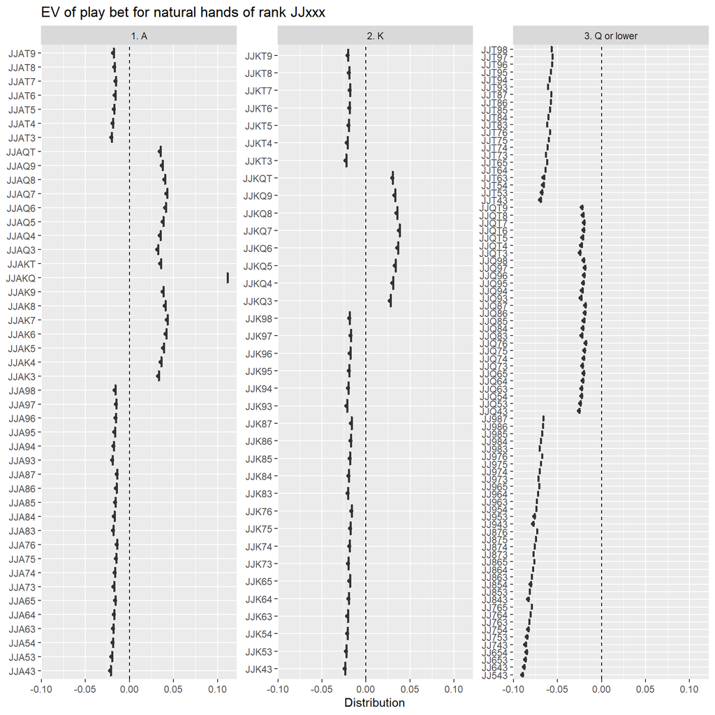

```r
tmpHR <- tmpJJxxxUse %>%
    pull(handNum)

tmpHS <- mtxHands[tmpHR,] %>%
    tibble::as_tibble(.name_repair=make.names) %>%
    purrr::set_names(paste0("V", 1:5)) %>%
    mutate(handNum=tmpHR) %>%
    pivot_longer(-c(handNum)) %>%
    mutate(rank=1 + (value-1) %% 13, rank=ifelse(rank==1, 14, rank), suit=(value-1) %/% 13) %>%
    arrange(handNum, desc(rank))

# Plot of EV by hand type
resJJxxx %>%
    mutate(evAllIfPlay=2*pWQ+pWN-3*pLQ-3*pLN) %>%
    left_join(tmpHS %>%
                  filter(!(rank %in% c(11))) %>%
                  group_by(handNum) %>%
                  mutate(label=paste0("JJ", max(rank), nth(rank, 2), min(rank)),
                         label=str_replace(label, "14", "A"),
                         label=str_replace(label, "13", "K"),
                         label=str_replace(label, "12", "Q"),
                         label=str_replace(label, "10", "T"),
                         card3=str_sub(label, 3, 3)
                         ) %>%
                  filter(row_number()==1) %>%
                  ungroup(),
              by="handNum"
              ) %>%
    mutate(bucket=case_when(card3=="A" ~ "1. A", card3=="K" ~ "2. K", TRUE ~ "3. Q or lower")) %>%
    ggplot(aes(x=factor(label))) +
    coord_flip() +
    labs(x=NULL,
         y="Distribution",
         title="EV of play bet for natural hands of rank JJxxx"
         ) +
    geom_boxplot(aes(y=evPlay), fill="lightblue") +
    geom_hline(yintercept=0, lty=2) +
    facet_wrap(~bucket, scales="free_y")
```

The JJxxx with no wilds has positive evPlay provided it contains two kickers of rank A, K, or Q.

Wild hands of type 2Jxxx (pair only) are also explored:

```r
# Eligible hands of type JJxxx
eligible2Jxxx <- allHandRanks %>%
    filter(wType==11, tb1==11, tb2==11) %>%
    semi_join(handSuit %>% filter(n2 <= n1, n4 <= n3, nWild==1), by=c("handNum"))
eligible2Jxxx
```

```
## # A tibble: 27,560 × 9
##    handNum wType   tb1   tb2   tb3   tb4   tb5 chgRank  rank
##      <int> <dbl> <dbl> <dbl> <dbl> <dbl> <dbl>   <dbl> <dbl>
##  1  328084    11    11    11    10     9     6       1  3006
##  2  328097    11    11    11    10     9     6       0  3006
##  3  328125    11    11    11    10     9     6       0  3006
##  4  328138    11    11    11    10     9     6       0  3006
##  5  328552    11    11    11    10     9     6       0  3006
##  6  328565    11    11    11    10     9     6       0  3006
##  7  328593    11    11    11    10     9     6       0  3006
##  8  328864    11    11    11    10     9     6       0  3006
##  9  328877    11    11    11    10     9     6       0  3006
## 10  328892    11    11    11    10     9     6       0  3006
## # … with 27,550 more rows
```

```r
# Create tibble of hand types
mtxSmallTest <- mtxHands[eligible2Jxxx$handNum,]
tblSmallTest <- tibble::as_tibble(mtxSmallTest, .name_repair=make.names) %>%
    purrr::set_names(paste0("V", 1:5)) %>%
    mutate(handNum=eligible2Jxxx$handNum)
tblSmallTest
```

```
## # A tibble: 27,560 × 6
##       V1    V2    V3    V4    V5 handNum
##    <int> <int> <int> <int> <int>   <int>
##  1     2     6     9    10    24  328084
##  2     2     6     9    10    37  328097
##  3     2     6     9    11    23  328125
##  4     2     6     9    11    36  328138
##  5     2     6     9    23    24  328552
##  6     2     6     9    23    37  328565
##  7     2     6     9    24    36  328593
##  8     2     6     9    36    37  328864
##  9     2     6     9    36    50  328877
## 10     2     6     9    37    49  328892
## # … with 27,550 more rows
```

```r
# Get suit counts of descending cards
tmpCheckSuits <- tblSmallTest %>%
    pivot_longer(-c(handNum)) %>%
    mutate(rank=1 + (value-1) %% 13, rank=ifelse(rank==1, 14, rank), suit=(value-1) %/% 13) %>%
    arrange(handNum, desc(rank))
tmpCheckSuits
```

```
## # A tibble: 137,800 × 5
##    handNum name  value  rank  suit
##      <int> <chr> <int> <dbl> <dbl>
##  1  270744 V5       24    11     1
##  2  270744 V4        5     5     0
##  3  270744 V3        4     4     0
##  4  270744 V2        3     3     0
##  5  270744 V1        2     2     0
##  6  270757 V5       37    11     2
##  7  270757 V4        5     5     0
##  8  270757 V3        4     4     0
##  9  270757 V2        3     3     0
## 10  270757 V1        2     2     0
## # … with 137,790 more rows
```

```r
# Get count of hands with Jack and deuce as first suit
tmp2JxxxUse <- tmpCheckSuits %>%
    filter((rank==11 & suit==0) | (rank==2 & suit %in% c(0))) %>%
    group_by(handNum) %>%
    summarize(n=n()) %>%
    filter(n==2)
tmp2JxxxUse
```

```
## # A tibble: 1,924 × 2
##    handNum     n
##      <int> <int>
##  1  271005     2
##  2  271006     2
##  3  271007     2
##  4  271008     2
##  5  271009     2
##  6  271010     2
##  7  271018     2
##  8  271019     2
##  9  271020     2
## 10  271021     2
## # … with 1,914 more rows
```

```r
# Get suit counts by whether hands are used
tmpCheckSuits %>%
    group_by(handNum, suit) %>%
    summarize(n=n(), .groups="drop") %>%
    mutate(suit=paste0("V", suit)) %>%
    pivot_wider(id_cols=handNum, names_from="suit", values_from="n", values_fill=0) %>%
    full_join(tmp2JxxxUse, by=c("handNum")) %>%
    mutate(type=ifelse(is.na(n), "Ineligible", "Eligible")) %>%
    count(type, V0, V1, V2, V3) %>%
    print(n=50)
```

```
## # A tibble: 50 × 6
##    type          V0    V1    V2    V3     n
##    <chr>      <int> <int> <int> <int> <int>
##  1 Eligible       2     0     2     1   156
##  2 Eligible       2     0     3     0    52
##  3 Eligible       2     1     1     1   312
##  4 Eligible       2     1     2     0   156
##  5 Eligible       3     0     1     1   312
##  6 Eligible       3     0     2     0   156
##  7 Eligible       3     1     1     0   312
##  8 Eligible       3     2     0     0   156
##  9 Eligible       4     0     1     0   156
## 10 Eligible       4     1     0     0   156
## 11 Ineligible     0     0     2     2   312
## 12 Ineligible     0     0     2     3   312
```

[output cut: 38 more lines]

```r
# Run for all hands of 2Jxxx (one wild, pair only)
t1 <- proc.time()
res2Jxxx <- calculateResults(useHandNums=tmp2JxxxUse$handNum)
proc.time()-t1
```

```
##    user  system elapsed
## 1055.92  236.65 1355.34
```

```r
# Save file for use later
saveToRDS(res2Jxxx, ovrWriteError=FALSE)
```

```
##
## File already exists: ./RInputFiles/Coronavirus/res2Jxxx.RDS
##
## Not replacing the existing file since ovrWrite=FALSE
```

Hands of type 2Jxxx are explored for ranges of evPlay:

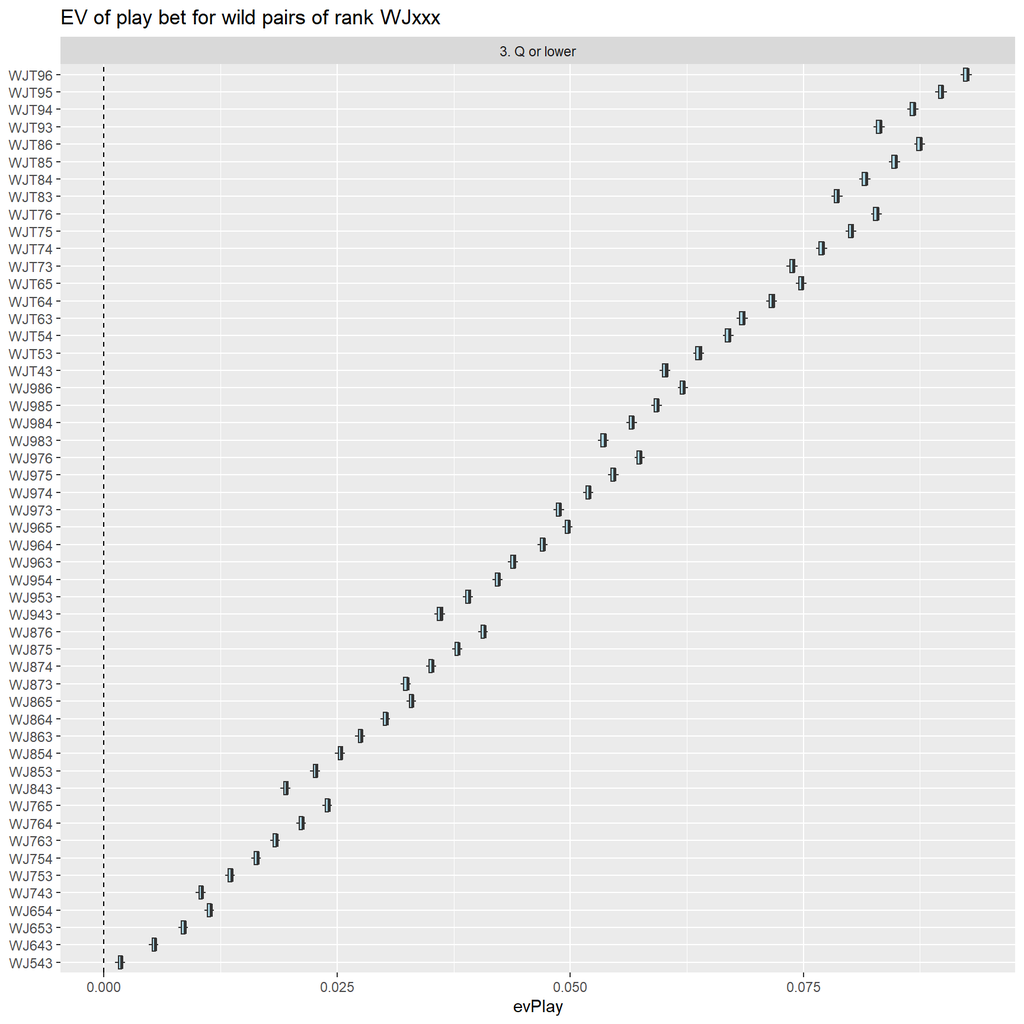

```r
tmpHR <- tmp2JxxxUse %>%
    pull(handNum)

tmpHS <- mtxHands[tmpHR,] %>%
    tibble::as_tibble(.name_repair=make.names) %>%
    purrr::set_names(paste0("V", 1:5)) %>%
    mutate(handNum=tmpHR) %>%
    pivot_longer(-c(handNum)) %>%
    mutate(rank=1 + (value-1) %% 13, rank=ifelse(rank==1, 14, rank), suit=(value-1) %/% 13) %>%
    arrange(handNum, desc(rank))

# Plot of EV by hand type
res2Jxxx %>%
    mutate(evAllIfPlay=2*pWQ+pWN-3*pLQ-3*pLN) %>%
    left_join(tmpHS %>%
                  filter(!(rank %in% c(11, 2))) %>%
                  group_by(handNum) %>%
                  mutate(label=paste0("WJ", max(rank), nth(rank, 2), min(rank)),
                         label=str_replace(label, "14", "A"),
                         label=str_replace(label, "13", "K"),
                         label=str_replace(label, "12", "Q"),
                         label=str_replace(label, "10", "T"),
                         card3=str_sub(label, 3, 3)
                         ) %>%
                  filter(row_number()==1) %>%
                  ungroup(),
              by="handNum"
              ) %>%
    mutate(bucket=case_when(card3=="A" ~ "1. A", card3=="K" ~ "2. K", TRUE ~ "3. Q or lower")) %>%
    ggplot(aes(x=factor(label))) +
    coord_flip() +
    labs(x=NULL,
         y="evPlay",
         title="EV of play bet for wild pairs of rank WJxxx"
         ) +
    geom_boxplot(aes(y=evPlay), fill="lightblue") +
    geom_hline(yintercept=0, lty=2) +
    facet_wrap(~bucket, scales="free_y")
```

All wild pairs JJ have positive evPlay. Wild hands of type 2Txxx (pair only) are also explored:

```r
# Eligible hands of type TTxxx
eligible2Txxx <- allHandRanks %>%
    filter(wType==11, tb1==10, tb2==10) %>%
    semi_join(handSuit %>% filter(n2 <= n1, n4 <= n3, nWild==1), by=c("handNum"))
eligible2Txxx
```

```
## # A tibble: 16,430 × 9
##    handNum wType   tb1   tb2   tb3   tb4   tb5 chgRank  rank
##      <int> <dbl> <dbl> <dbl> <dbl> <dbl> <dbl>   <dbl> <dbl>
##  1  310879    11    10    10     9     8     5       1  3192
##  2  310892    11    10    10     9     8     5       0  3192
##  3  310921    11    10    10     9     8     5       0  3192
##  4  310934    11    10    10     9     8     5       0  3192
##  5  311360    11    10    10     9     8     5       0  3192
##  6  311373    11    10    10     9     8     5       0  3192
##  7  311402    11    10    10     9     8     5       0  3192
##  8  311685    11    10    10     9     8     5       0  3192
##  9  311698    11    10    10     9     8     5       0  3192
## 10  311714    11    10    10     9     8     5       0  3192
## # … with 16,420 more rows
```

```r
# Create tibble of hand types
mtxSmallTest <- mtxHands[eligible2Txxx$handNum,]
tblSmallTest <- tibble::as_tibble(mtxSmallTest, .name_repair=make.names) %>%
    purrr::set_names(paste0("V", 1:5)) %>%
    mutate(handNum=eligible2Txxx$handNum)
tblSmallTest
```

```
## # A tibble: 16,430 × 6
##       V1    V2    V3    V4    V5 handNum
##    <int> <int> <int> <int> <int>   <int>
##  1     2     5     8     9    23  310879
##  2     2     5     8     9    36  310892
##  3     2     5     8    10    22  310921
##  4     2     5     8    10    35  310934
##  5     2     5     8    22    23  311360
##  6     2     5     8    22    36  311373
##  7     2     5     8    23    35  311402
##  8     2     5     8    35    36  311685
##  9     2     5     8    35    49  311698
## 10     2     5     8    36    48  311714
## # … with 16,420 more rows
```

```r
# Get suit counts of descending cards
tmpCheckSuits <- tblSmallTest %>%
    pivot_longer(-c(handNum)) %>%
    mutate(rank=1 + (value-1) %% 13, rank=ifelse(rank==1, 14, rank), suit=(value-1) %/% 13) %>%
    arrange(handNum, desc(rank))
tmpCheckSuits
```

```
## # A tibble: 82,150 × 5
##    handNum name  value  rank  suit
##      <int> <chr> <int> <dbl> <dbl>
##  1  270743 V5       23    10     1
##  2  270743 V4        5     5     0
##  3  270743 V3        4     4     0
##  4  270743 V2        3     3     0
##  5  270743 V1        2     2     0
##  6  270756 V5       36    10     2
##  7  270756 V4        5     5     0
##  8  270756 V3        4     4     0
##  9  270756 V2        3     3     0
## 10  270756 V1        2     2     0
## # … with 82,140 more rows
```

```r
# Get count of hands with Ten and deuce as first suit
tmp2TxxxUse <- tmpCheckSuits %>%
    filter((rank==10 & suit==0) | (rank==2 & suit %in% c(0))) %>%
    group_by(handNum) %>%
    summarize(n=n()) %>%
    filter(n==2)
tmp2TxxxUse
```

```
## # A tibble: 1,147 × 2
##    handNum     n
##      <int> <int>
##  1  270963     2
##  2  270964     2
##  3  270965     2
##  4  270966     2
##  5  270967     2
##  6  270976     2
##  7  270977     2
##  8  270978     2
##  9  270979     2
## 10  270980     2
## # … with 1,137 more rows
```

```r
# Get suit counts by whether hands are used
tmpCheckSuits %>%
    group_by(handNum, suit) %>%
    summarize(n=n(), .groups="drop") %>%
    mutate(suit=paste0("V", suit)) %>%
    pivot_wider(id_cols=handNum, names_from="suit", values_from="n", values_fill=0) %>%
    full_join(tmp2TxxxUse, by=c("handNum")) %>%
    mutate(type=ifelse(is.na(n), "Ineligible", "Eligible")) %>%
    count(type, V0, V1, V2, V3) %>%
    print(n=50)
```

```
## # A tibble: 50 × 6
##    type          V0    V1    V2    V3     n
##    <chr>      <int> <int> <int> <int> <int>
##  1 Eligible       2     0     2     1    93
##  2 Eligible       2     0     3     0    31
##  3 Eligible       2     1     1     1   186
##  4 Eligible       2     1     2     0    93
##  5 Eligible       3     0     1     1   186
##  6 Eligible       3     0     2     0    93
##  7 Eligible       3     1     1     0   186
##  8 Eligible       3     2     0     0    93
##  9 Eligible       4     0     1     0    93
## 10 Eligible       4     1     0     0    93
## 11 Ineligible     0     0     2     2   186
## 12 Ineligible     0     0     2     3   186
```

[output cut: 38 more lines]

```r
# Run for all hands of 2Jxxx (one wild, pair only)
t1 <- proc.time()
res2Txxx <- calculateResults(useHandNums=tmp2TxxxUse$handNum)
proc.time()-t1
```

```
##    user  system elapsed
##  709.86  162.35  923.19
```

```r
# Save file for use later
saveToRDS(res2Txxx, ovrWriteError=FALSE)
```

```
##
## File already exists: ./RInputFiles/Coronavirus/res2Txxx.RDS
##
## Not replacing the existing file since ovrWrite=FALSE
```

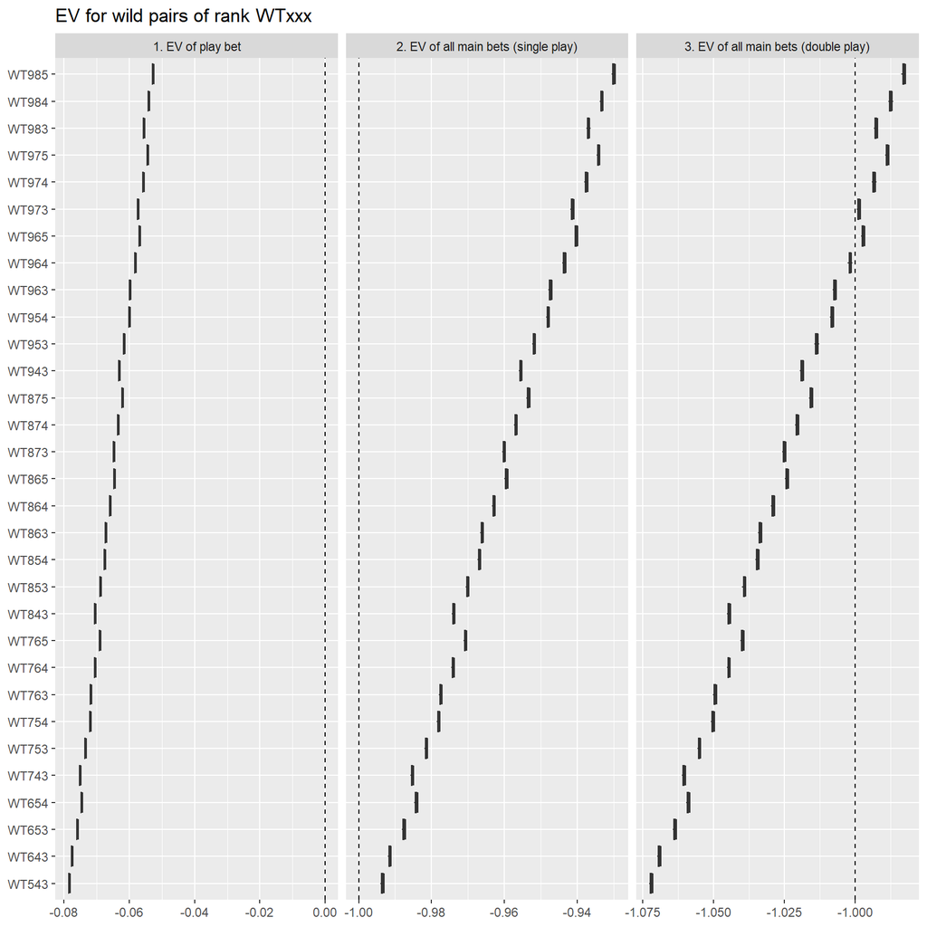

```r
tmpHR <- tmp2TxxxUse %>%
    pull(handNum)

tmpHS <- mtxHands[tmpHR,] %>%
    tibble::as_tibble(.name_repair=make.names) %>%
    purrr::set_names(paste0("V", 1:5)) %>%
    mutate(handNum=tmpHR) %>%
    pivot_longer(-c(handNum)) %>%
    mutate(rank=1 + (value-1) %% 13, rank=ifelse(rank==1, 14, rank), suit=(value-1) %/% 13) %>%
    arrange(handNum, desc(rank))

# Plot of EV by hand type
res2Txxx %>%
    mutate(evAllDouble=3*pWQ+2*pWN-4*pLQ-4*pLN,
           evAllSingle=2*pWQ+pWN-3*pLQ-3*pLN
           ) %>%
    left_join(tmpHS %>%
                  filter(!(rank %in% c(10, 2))) %>%
                  group_by(handNum) %>%
                  mutate(label=paste0("WT", max(rank), nth(rank, 2), min(rank)),
                         label=str_replace(label, "14", "A"),
                         label=str_replace(label, "13", "K"),
                         label=str_replace(label, "12", "Q"),
                         label=str_replace(label, "10", "T"),
                         card3=str_sub(label, 3, 3)
                         ) %>%
                  filter(row_number()==1) %>%
                  ungroup(),
              by="handNum"
              ) %>%
    select(handNum, label, evPlay, evAllSingle, evAllDouble) %>%
    pivot_longer(cols=-c(handNum, label)) %>%
    ggplot(aes(x=factor(label))) +
    coord_flip() +
    labs(x=NULL,
         y=NULL,
         title="EV for wild pairs of rank WTxxx"
         ) +
    geom_boxplot(aes(y=value), fill="lightblue") +
    geom_hline(aes(yintercept=ifelse(name=="evPlay", 0, -1)), lty=2) +
    facet_wrap(~c("evPlay"="1. EV of play bet",
                  "evAllSingle"="2. EV of all main bets (single play)",
                  "evAllDouble"="3. EV of all main bets (double play)"
                  )[name],
               scales="free_x"
               )
```

All wild pairs TT have negative evPlay.

Natural hands of type QQxxx are also explored:

```r
# Eligible hands of type JJxxx
eligibleQQxxx <- allHandRanks %>%
    filter(wType==11, tb1==12, tb2==12) %>%
    semi_join(handSuit %>% filter(n2 <= n1, n4 <= n3, nWild==0), by=c("handNum"))
eligibleQQxxx
```

```
## # A tibble: 24,090 × 9
##    handNum wType   tb1   tb2   tb3   tb4   tb5 chgRank  rank
##      <int> <dbl> <dbl> <dbl> <dbl> <dbl> <dbl>   <dbl> <dbl>
##  1  147327    11    12    12    14    13    11       1  2730
##  2  147340    11    12    12    14    13    11       0  2730
##  3  147730    11    12    12    14    13    11       0  2730
##  4  147743    11    12    12    14    13    11       0  2730
##  5  147769    11    12    12    14    13    11       0  2730
##  6  148016    11    12    12    14    13    11       0  2730
##  7  148029    11    12    12    14    13    11       0  2730
##  8  148042    11    12    12    14    13    11       0  2730
##  9  148522    11    12    12    14    13    11       0  2730
## 10  148808    11    12    12    14    13    11       0  2730
## # … with 24,080 more rows
```

```r
# Create tibble of hand types
mtxSmallTest <- mtxHands[eligibleQQxxx$handNum,]
tblSmallTest <- tibble::as_tibble(mtxSmallTest, .name_repair=make.names) %>%
    purrr::set_names(paste0("V", 1:5)) %>%
    mutate(handNum=eligibleQQxxx$handNum)
tblSmallTest
```

```
## # A tibble: 24,090 × 6
##       V1    V2    V3    V4    V5 handNum
##    <int> <int> <int> <int> <int>   <int>
##  1     1    11    12    13    25  147327
##  2     1    11    12    13    38  147340
##  3     1    11    12    25    26  147730
##  4     1    11    12    25    39  147743
##  5     1    11    12    26    38  147769
##  6     1    11    12    38    39  148016
##  7     1    11    12    38    52  148029
##  8     1    11    12    39    51  148042
##  9     1    11    13    25    38  148522
## 10     1    11    13    38    51  148808
## # … with 24,080 more rows
```

```r
# Get suit counts of descending cards
tmpCheckSuits <- tblSmallTest %>%
    pivot_longer(-c(handNum)) %>%
    mutate(rank=1 + (value-1) %% 13, rank=ifelse(rank==1, 14, rank), suit=(value-1) %/% 13) %>%
    arrange(handNum, desc(rank))
tmpCheckSuits
```

```
## # A tibble: 120,450 × 5
##    handNum name  value  rank  suit
##      <int> <chr> <int> <dbl> <dbl>
##  1   21153 V1        1    14     0
##  2   21153 V4       12    12     0
##  3   21153 V5       25    12     1
##  4   21153 V3        4     4     0
##  5   21153 V2        3     3     0
##  6   21166 V1        1    14     0
##  7   21166 V4       12    12     0
##  8   21166 V5       38    12     2
##  9   21166 V3        4     4     0
## 10   21166 V2        3     3     0
## # … with 120,440 more rows
```

```r
# Get count of hands with Jack as first two suits
tmpQQxxxUse <- tmpCheckSuits %>%
    filter((rank==12 & suit==0) | (rank==12 & suit %in% c(1))) %>%
    group_by(handNum) %>%
    summarize(n=n()) %>%
    filter(n==2)
tmpQQxxxUse
```

```
## # A tibble: 4,290 × 2
##    handNum     n
##      <int> <int>
##  1   21153     2
##  2   22281     2
##  3   23362     2
##  4   24397     2
##  5   25387     2
##  6   26333     2
##  7   27236     2
##  8   28097     2
##  9   28957     2
## 10   29107     2
## # … with 4,280 more rows
```

```r
# Get suit counts by whether hands are used
tmpCheckSuits %>%
    group_by(handNum, suit) %>%
    summarize(n=n(), .groups="drop") %>%
    mutate(suit=paste0("V", suit)) %>%
    pivot_wider(id_cols=handNum, names_from="suit", values_from="n", values_fill=0) %>%
    full_join(tmpQQxxxUse, by=c("handNum")) %>%
    mutate(type=ifelse(is.na(n), "Ineligible", "Eligible")) %>%
    count(type, V0, V1, V2, V3) %>%
    print(n=30)
```

```
## # A tibble: 24 × 6
##    type          V0    V1    V2    V3     n
##    <chr>      <int> <int> <int> <int> <int>
##  1 Eligible       1     1     2     1   495
##  2 Eligible       1     1     3     0   165
##  3 Eligible       2     1     1     1   990
##  4 Eligible       2     1     2     0   495
##  5 Eligible       2     2     1     0   990
##  6 Eligible       3     1     1     0   495
##  7 Eligible       3     2     0     0   495
##  8 Eligible       4     1     0     0   165
##  9 Ineligible     0     0     3     2   495
## 10 Ineligible     0     0     4     1   165
## 11 Ineligible     1     0     2     2  1980
## 12 Ineligible     1     0     3     1  1155
## 13 Ineligible     1     0     4     0   165
## 14 Ineligible     1     1     2     1  3960
## 15 Ineligible     1     1     3     0   990
## 16 Ineligible     2     0     2     1  1980
## 17 Ineligible     2     0     3     0   495
## 18 Ineligible     2     1     1     1  3465
## 19 Ineligible     2     1     2     0  1485
## 20 Ineligible     2     2     1     0   990
## 21 Ineligible     3     0     1     1  1155
## 22 Ineligible     3     0     2     0   495
## 23 Ineligible     3     1     1     0   660
## 24 Ineligible     4     0     1     0   165
```

```r
# Run for all hands of JJxxx (no wild)
t1 <- proc.time()
resQQxxx <- calculateResults(useHandNums=tmpQQxxxUse$handNum)
proc.time()-t1
```

```
##    user  system elapsed
## 2157.81  437.55 2666.48
```

```r
# Save file for use later
saveToRDS(resQQxxx, ovrWriteError=FALSE)
```

```
##
## File already exists: ./RInputFiles/Coronavirus/resQQxxx.RDS
##
## Not replacing the existing file since ovrWrite=FALSE
```

Hands of type QQxxx are explored for ranges of evPlay:

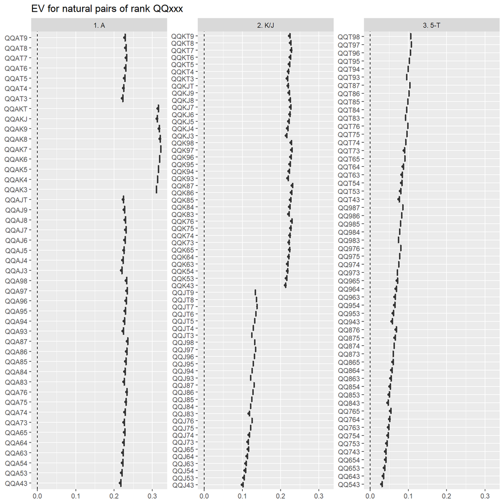

```r
tmpHR <- tmpQQxxxUse %>%
    pull(handNum)

tmpHS <- mtxHands[tmpHR,] %>%
    tibble::as_tibble(.name_repair=make.names) %>%
    purrr::set_names(paste0("V", 1:5)) %>%
    mutate(handNum=tmpHR) %>%
    pivot_longer(-c(handNum)) %>%
    mutate(rank=1 + (value-1) %% 13, rank=ifelse(rank==1, 14, rank), suit=(value-1) %/% 13) %>%
    arrange(handNum, desc(rank))

# Plot of EV by hand type
resQQxxx %>%
    mutate(evAllDouble=3*pWQ+2*pWN-4*pLQ-4*pLN,
           evAllSingle=2*pWQ+pWN-3*pLQ-3*pLN
           ) %>%
    left_join(tmpHS %>%
                  filter(!(rank %in% c(12, 2))) %>%
                  group_by(handNum) %>%
                  mutate(label=paste0("QQ", max(rank), nth(rank, 2), min(rank)),
                         label=str_replace(label, "11", "J"),
                         label=str_replace(label, "13", "K"),
                         label=str_replace(label, "14", "A"),
                         label=str_replace(label, "10", "T"),
                         card3=str_sub(label, 3, 3)
                         ) %>%
                  filter(row_number()==1) %>%
                  ungroup(),
              by="handNum"
              ) %>%
    select(handNum, label, evPlay, card3) %>%
    pivot_longer(cols=-c(handNum, label, card3)) %>%
    ggplot(aes(x=factor(label))) +
    coord_flip() +
    labs(x=NULL,
         y=NULL,
         title="EV for natural pairs of rank QQxxx"
         ) +
    geom_boxplot(aes(y=value), fill="lightblue") +
    geom_hline(aes(yintercept=ifelse(name=="evPlay", 0, -1)), lty=2) +
    facet_wrap(~c("A"="1. A",
                  "K"="2. K/J", "J"="2. K/J",
                  "T"="3. 5-T", "9"="3. 5-T", "8"="3. 5-T", "7"="3. 5-T", "6"="3. 5-T", "5"="3. 5-T"
                  )[card3],
               scales="free_y"
               )
```

All natural pairs of rank QQxxx have positive evPlay. There are step-increases as xxx includes one or two cards of rank that can outpair QQ (A or K)

A subset of hands is explored that can be analyzed:

1. Wilds, if any, are in ascending order (e.g., 2-15 is OK, but just 53 is not)
2. Number of non-wild cards by suit is non-ascending (Spades >= Hearts >= Diamonds >= Clubs)
3. If two suits have the same number of cards, the “rank is non-ascending (Spades >= Hearts >= Diamonds >= Clubs)

Code for the first two rules includes:

```r
# Eligible wild combinations
all5Wild <- purrr::reduce(.x=cardInHand[c(2, 15, 28, 41, 53)], .f=intersect)
first4Wild <- purrr::reduce(.x=cardInHand[c(2, 15, 28, 41)], .f=intersect) %>%
    setdiff(purrr::reduce(.x=cardInHand[c(53)], .f=union))
first3Wild <- purrr::reduce(.x=cardInHand[c(2, 15, 28)], .f=intersect) %>%
    setdiff(purrr::reduce(.x=cardInHand[c(41, 53)], .f=union))
first2Wild <- purrr::reduce(.x=cardInHand[c(2, 15)], .f=intersect) %>%
    setdiff(purrr::reduce(.x=cardInHand[c(28, 41, 53)], .f=union))
first1Wild <- purrr::reduce(.x=cardInHand[c(2)], .f=intersect) %>%
    setdiff(purrr::reduce(.x=cardInHand[c(15, 28, 41, 53)], .f=union))
has0Wild <- (1:nrow(mtxHands)) %>%
    setdiff(purrr::reduce(.x=cardInHand[c(2, 15, 28, 41, 53)], .f=union))
wildEligible <- tibble::tibble(handNum=c(all5Wild, first4Wild, first3Wild, first2Wild, first1Wild, has0Wild)) %>%
    arrange(handNum)
sortedHandRanks %>%
    mutate(wildEligible=ifelse(handNum %in% wildEligible$handNum, "Eligible", "Not")) %>%
    count(nWild, wildEligible) %>%
    arrange(desc(nWild), wildEligible) %>%
    pivot_wider(id_cols=c("nWild"), names_from="wildEligible", values_from="n", values_fill=0) %>%
    bind_rows(colSums(.)) %>%
    mutate(nWild=case_when(nWild<=5~as.character(nWild), TRUE~"Total"), pctOK=Eligible/(Eligible+Not))
```

```
## # A tibble: 7 × 4
##   nWild Eligible    Not pctOK
##   <chr>    <dbl>  <dbl> <dbl>
## 1 5            1      0 1
## 2 4           48    192 0.2
## 3 3         1128  10152 0.1
## 4 2        17296 155664 0.1
## 5 1       194580 778320 0.2
## 6 0      1712304      0 1
## 7 Total  1925357 944328 0.671
```

```r
# Count by suit
t <- proc.time()
uaSpades <- tibble::tibble(handNum=purrr::reduce(.x=cardInHand[c(1, 3:13)], .f=union_all))
uaHearts <- tibble::tibble(handNum=purrr::reduce(.x=cardInHand[c(14, 16:26)], .f=union_all))
uaDiamonds <- tibble::tibble(handNum=purrr::reduce(.x=cardInHand[c(27, 29:39)], .f=union_all))
uaClubs <- tibble::tibble(handNum=purrr::reduce(.x=cardInHand[c(40, 42:52)], .f=union_all))
uaAll <- bind_rows(uaSpades, uaHearts, uaDiamonds, uaClubs, .id="suit") %>%
    mutate(suit=c("1"="Spades", "2"="Hearts", "3"="Diamonds", "4"="Clubs")[suit])
nPerSuit <- uaAll %>%
    mutate(n=1) %>%
    pivot_wider(id_cols="handNum", names_from="suit", values_from="n", values_fn=sum, values_fill=0)
proc.time()-t
```

```
##    user  system elapsed
##   25.56    1.56   27.21
```

```r
# Analysis of eligibility
suitCountEligible <- nPerSuit %>%
    mutate(isOK=ifelse((Spades >= Hearts) & (Hearts >= Diamonds) & (Diamonds >= Clubs), "yes", "no"))
suitCountIneligible <- suitCountEligible %>% filter(isOK=="no") %>% pull(handNum)
sortedHandRanks %>%
    mutate(wildEligible=ifelse(handNum %in% wildEligible$handNum, "Eligible", "Not"),
           suitCountEligible=ifelse(handNum %in% suitCountIneligible, "Not", "Eligible")
           ) %>%
    count(nWild, wildEligible, suitCountEligible) %>%
    mutate(nEligible=ifelse(wildEligible=="Eligible" & suitCountEligible=="Eligible", n, 0))
```

```
## # A tibble: 19 × 5
##    nWild wildEligible suitCountEligible       n nEligible
##    <dbl> <chr>        <chr>               <int>     <dbl>
##  1     0 Eligible     Eligible           219252    219252
##  2     0 Eligible     Not               1493052         0
##  3     1 Eligible     Eligible            37731     37731
##  4     1 Eligible     Not                156849         0
##  5     1 Not          Eligible           150924         0
##  6     1 Not          Not                627396         0
##  7     2 Eligible     Eligible             2740      2740
##  8     2 Eligible     Not                 14556         0
##  9     2 Not          Eligible            24660         0
## 10     2 Not          Not                131004         0
## 11     3 Eligible     Eligible              210       210
## 12     3 Eligible     Not                   918         0
## 13     3 Not          Eligible             1890         0
## 14     3 Not          Not                  8262         0
## 15     4 Eligible     Eligible               12        12
## 16     4 Eligible     Not                    36         0
## 17     4 Not          Eligible               48         0
## 18     4 Not          Not                   144         0
## 19     5 Eligible     Eligible                1         1
```

```r
# Masks for suits
t <- proc.time()
maskSpade <- mtxHands %in% c(1, 3:13) %>% matrix(nrow=nrow(mtxHands), ncol=5, byrow=FALSE)
maskHeart <- mtxHands %in% (13+c(1, 3:13)) %>% matrix(nrow=nrow(mtxHands), ncol=5, byrow=FALSE)
maskDiamond <- mtxHands %in% (26+c(1, 3:13)) %>% matrix(nrow=nrow(mtxHands), ncol=5, byrow=FALSE)
maskClub <- mtxHands %in% (39+c(1, 3:13)) %>% matrix(nrow=nrow(mtxHands), ncol=5, byrow=FALSE)
suitCountCheck <- tibble::tibble(handNum=1:nrow(mtxHands),
                                 nSpade=rowSums(maskSpade),
                                 nHeart=rowSums(maskHeart),
                                 nDiamond=rowSums(maskDiamond),
                                 nClub=rowSums(maskClub)
                                 )
proc.time()-t
```

```
##    user  system elapsed
##    1.18    0.55    1.73
```

```r
# Confirm same results
nPerSuit %>%
    right_join(select(sortedHandRanks, handNum), by="handNum") %>%
    mutate(across(-c(handNum), .fns=function(x) ifelse(is.na(x), 0, x))) %>%
    arrange(handNum) %>%
    purrr::set_names(names(suitCountCheck)) %>%
    identical(x=., y=suitCountCheck)
```

```
## [1] TRUE
```

The suit combinations of eligible hands are explored:

```r
suitRankCountTable <- sortedHandRanks %>%
    select(handNum, nWild) %>%
    left_join(nPerSuit, by=c("handNum")) %>%
    mutate(across(-c(handNum, nWild), .fns=function(x) ifelse(is.na(x), 0, x)),
           wildEligible=ifelse(handNum %in% wildEligible$handNum, "Eligible", "Not"),
           suitEligible=ifelse((Spades>=Hearts) & (Hearts>=Diamonds) & (Diamonds>=Clubs), "yes", "no")
           ) %>%
    count(nWild, wildEligible, suitEligible, Spades, Hearts, Diamonds, Clubs) %>%
    filter(wildEligible=="Eligible", suitEligible=="yes") %>%
    arrange(-nWild, -Spades, -Hearts) %>%
    select(nWild, wildEligible, suitEligible, everything())
suitRankCountTable
```

```
## # A tibble: 18 × 8
##    nWild wildEligible suitEligible Spades Hearts Diamonds Clubs      n
##    <dbl> <chr>        <chr>         <dbl>  <dbl>    <dbl> <dbl>  <int>
##  1     5 Eligible     yes               0      0        0     0      1
##  2     4 Eligible     yes               1      0        0     0     12
##  3     3 Eligible     yes               2      0        0     0     66
##  4     3 Eligible     yes               1      1        0     0    144
##  5     2 Eligible     yes               3      0        0     0    220
##  6     2 Eligible     yes               2      1        0     0    792
##  7     2 Eligible     yes               1      1        1     0   1728
##  8     1 Eligible     yes               4      0        0     0    495
##  9     1 Eligible     yes               3      1        0     0   2640
## 10     1 Eligible     yes               2      2        0     0   4356
## 11     1 Eligible     yes               2      1        1     0   9504
## 12     1 Eligible     yes               1      1        1     1  20736
## 13     0 Eligible     yes               5      0        0     0    792
## 14     0 Eligible     yes               4      1        0     0   5940
## 15     0 Eligible     yes               3      2        0     0  14520
## 16     0 Eligible     yes               3      1        1     0  31680
## 17     0 Eligible     yes               2      2        1     0  52272
## 18     0 Eligible     yes               2      1        1     1 114048
```

```r
# Duplicated combinations of 1-1-1-1 and 2-2
tmpSingleRank <- expand.grid(spades=3:14, hearts=3:14, diamonds=3:14, clubs=3:14) %>%
    tibble::as_tibble()
tmpSingleRank
```

```
## # A tibble: 20,736 × 4
##    spades hearts diamonds clubs
##     <int>  <int>    <int> <int>
##  1      3      3        3     3
##  2      4      3        3     3
##  3      5      3        3     3
##  4      6      3        3     3
##  5      7      3        3     3
##  6      8      3        3     3
##  7      9      3        3     3
##  8     10      3        3     3
##  9     11      3        3     3
## 10     12      3        3     3
## # … with 20,726 more rows
```

```r
# Resolving ties of type 1-1 (assume spades and hearts, suits are invariant)
elig11 <- tmpSingleRank %>%
    select(spades, hearts) %>%
    unique() %>%
    mutate(eligible=ifelse(spades>=hearts, "yes", "no"))
elig11 %>% count(eligible) %>% mutate(pct=n/sum(n))
```

```
## # A tibble: 2 × 3
##   eligible     n   pct
##   <chr>    <int> <dbl>
## 1 no          66 0.458
## 2 yes         78 0.542
```

```r
# Resolving ties of type 2-2 (assume spades and hearts, suits are invariant)
elig22 <- tmpSingleRank %>%
    rename(spade2=diamonds, heart2=clubs) %>%
    filter(spades>spade2, hearts>heart2) %>%
    unique() %>%
    mutate(eligible=ifelse((spades>hearts) | (spades==hearts & spade2>=heart2), "yes", "no"))
elig22 %>% count(eligible) %>% mutate(pct=n/sum(n))
```

```
## # A tibble: 2 × 3
##   eligible     n   pct
##   <chr>    <int> <dbl>
## 1 no        2145 0.492
## 2 yes       2211 0.508
```

```r
# Resolving ties of type 1-1-1 (assume spades and hearts and diamonds, suits are invariant)
elig111 <- tmpSingleRank %>%
    select(spades, hearts, diamonds) %>%
    unique() %>%
    mutate(eligible=ifelse((spades>=hearts) & (hearts>=diamonds), "yes", "no"))
elig111 %>% count(eligible) %>% mutate(pct=n/sum(n))
```

```
## # A tibble: 2 × 3
##   eligible     n   pct
##   <chr>    <int> <dbl>
## 1 no        1364 0.789
## 2 yes        364 0.211
```

```r
# Resolving ties of type 1-1-1-1 (all suits)
elig1111 <- tmpSingleRank %>%
    select(spades, hearts, diamonds, clubs) %>%
    unique() %>%
    mutate(eligible=ifelse((spades>=hearts) & (hearts>=diamonds) & (diamonds>=clubs), "yes", "no"))
elig1111 %>% count(eligible) %>% mutate(pct=n/sum(n))
```

```
## # A tibble: 2 × 3
##   eligible     n    pct
##   <chr>    <int>  <dbl>
## 1 no       19371 0.934
## 2 yes       1365 0.0658
```

```r
# Full eligibility data
eligibleMap <- sapply(list(elig11, elig111, elig1111, elig22), FUN=function(x) mean(x$eligible=="yes")) %>%
    purrr::set_names(c("1-1", "1-1-1", "1-1-1-1", "2-2"))
eligibleMap <- c(eligibleMap, "none"=1)
eligibleMap
```

```
##        1-1      1-1-1    1-1-1-1        2-2       none
## 0.54166667 0.21064815 0.06582755 0.50757576 1.00000000
```

```r
# Expected hands after de-duplications
suitRankCountDedup <- suitRankCountTable %>%
    mutate(dupType=case_when((Spades==1 & Hearts==1 & Diamonds==0)~"1-1",
                             (Spades==1 & Hearts==1 & Diamonds==1 & Clubs==0)~"1-1-1",
                             (Spades==2 & Hearts==2)~"2-2",
                             (Spades>1 & Hearts==1 & Diamonds==1 & Clubs==0)~"1-1",
                             (Spades==1 & Hearts==1 & Diamonds==1 & Clubs==1)~"1-1-1-1",
                             (Spades>1 & Hearts==1 & Diamonds==1 & Clubs==1)~"1-1-1",
                             TRUE~"none"
                             ),
           dedupRatio=eligibleMap[dupType],
           uniqueN=n*dedupRatio
           )
suitRankCountDedup
```

```
## # A tibble: 18 × 11
##    nWild wildEligible suitE…¹ Spades Hearts Diamo…² Clubs      n dupType dedup…³
##    <dbl> <chr>        <chr>    <dbl>  <dbl>   <dbl> <dbl>  <int> <chr>     <dbl>
##  1     5 Eligible     yes          0      0       0     0      1 none     1
##  2     4 Eligible     yes          1      0       0     0     12 none     1
##  3     3 Eligible     yes          2      0       0     0     66 none     1
##  4     3 Eligible     yes          1      1       0     0    144 1-1      0.542
##  5     2 Eligible     yes          3      0       0     0    220 none     1
##  6     2 Eligible     yes          2      1       0     0    792 none     1
##  7     2 Eligible     yes          1      1       1     0   1728 1-1-1    0.211
##  8     1 Eligible     yes          4      0       0     0    495 none     1
##  9     1 Eligible     yes          3      1       0     0   2640 none     1
## 10     1 Eligible     yes          2      2       0     0   4356 2-2      0.508
## 11     1 Eligible     yes          2      1       1     0   9504 1-1      0.542
## 12     1 Eligible     yes          1      1       1     1  20736 1-1-1-1  0.0658
## 13     0 Eligible     yes          5      0       0     0    792 none     1
## 14     0 Eligible     yes          4      1       0     0   5940 none     1
## 15     0 Eligible     yes          3      2       0     0  14520 none     1
## 16     0 Eligible     yes          3      1       1     0  31680 1-1      0.542
## 17     0 Eligible     yes          2      2       1     0  52272 2-2      0.508
## 18     0 Eligible     yes          2      1       1     1 114048 1-1-1    0.211
## # … with 1 more variable: uniqueN <dbl>, and abbreviated variable names
## #   ¹suitEligible, ²Diamonds, ³dedupRatio
```

```r
suitRankCountDedup %>%
    group_by(nWild) %>%
    summarize(across(c(n, uniqueN), .fns=sum)) %>%
    arrange(desc(nWild)) %>%
    column_to_rownames("nWild") %>%
    mutate(pctUniqueN=round(uniqueN/sum(uniqueN),4)) %>%
    bind_rows(colSums(.))
```

```
##           n uniqueN pctUniqueN
## 5         1       1     0.0000
## 4        12      12     0.0001
## 3       210     144     0.0014
## 2      2740    1376     0.0134
## 1     37731   11859     0.1159
## 0    219252   88968     0.8692
## ...7 259946  102360     1.0000
```

After de-duplication, there are 102,360 unique hands that can be dealt in the game (assuming that the rank of wilds does not matter and that the highest-powered suit in order is spades, hearts, diamonds, clubs). Most of these are hands that do not contain a wild

The subset of non-duplicated hands with no wilds are extracted:

```r
# Create a tibble of hands
tblHands <- tibble::as_tibble(mtxHands) %>%
    mutate(handNum=1:nrow(.))
tblHands
```

```
## # A tibble: 2,869,685 × 6
##       V1    V2    V3    V4    V5 handNum
##    <int> <int> <int> <int> <int>   <int>
##  1     1     2     3     4     5       1
##  2     1     2     3     4     6       2
##  3     1     2     3     4     7       3
##  4     1     2     3     4     8       4
##  5     1     2     3     4     9       5
##  6     1     2     3     4    10       6
##  7     1     2     3     4    11       7
##  8     1     2     3     4    12       8
##  9     1     2     3     4    13       9
## 10     1     2     3     4    14      10
## # … with 2,869,675 more rows
```

```r
# Get the relevant last 3 cards for 2-1-1-1
tmpLast3 <- elig111 %>%
    mutate(across(c(spades, hearts, diamonds), .fns=function(x) ifelse(x==14, 1, x))) %>%
    filter(eligible=="yes") %>%
    rename(V5=diamonds, V4=hearts, V3=spades) %>%
    mutate(V3=V3+13, V4=V4+26, V5=V5+39)

# Get the set of 2-1-1-1 hands
hn2111 <- tblHands %>%
    semi_join(select(tmpLast3, V3, V4, V5), by=c("V3", "V4", "V5")) %>%
    filter(V1 %in% c(1, 3:13), V2 %in% c(1, 3:13))
hn2111
```

```
## # A tibble: 24,024 × 6
##       V1    V2    V3    V4    V5 handNum
##    <int> <int> <int> <int> <int>   <int>
##  1     1     3    14    27    40   30948
##  2     1     3    14    27    42   30950
##  3     1     3    14    27    43   30951
##  4     1     3    14    27    44   30952
##  5     1     3    14    27    45   30953
##  6     1     3    14    27    46   30954
##  7     1     3    14    27    47   30955
##  8     1     3    14    27    48   30956
##  9     1     3    14    27    49   30957
## 10     1     3    14    27    50   30958
## # … with 24,014 more rows
```

```r
# Check that hand numbers are all eligible
nPerSuit %>%
    semi_join(hn2111, by="handNum") %>%
    mutate(wildOK=ifelse(handNum %in% wildEligible$handNum, "yes", "no")) %>%
    count(wildOK, Spades, Hearts, Diamonds, Clubs)
```

```
## # A tibble: 1 × 6
##   wildOK Spades Hearts Diamonds Clubs     n
##   <chr>   <dbl>  <dbl>    <dbl> <dbl> <int>
## 1 yes         2      1        1     1 24024
```

```r
# Get the relevant first 4 cards for 2-2-1
tmpFirst4 <- elig22 %>%
    mutate(across(c(spades, spade2, hearts, heart2), .fns=function(x) ifelse(x==14, 1, x))) %>%
    filter(eligible=="yes") %>%
    mutate(V1=pmin(spades, spade2),
           V2=pmax(spades, spade2),
           V3=13+pmin(hearts, heart2),
           V4=13+pmax(hearts, heart2)
           )

# Get the set of 2-2-1 hands
hn221 <- tblHands %>%
    semi_join(select(tmpFirst4, V1, V2, V3, V4), by=c("V1", "V2", "V3", "V4")) %>%
    filter(V5 %in% c(27, 29:39))
hn221
```

```
## # A tibble: 26,532 × 6
##       V1    V2    V3    V4    V5 handNum
##    <int> <int> <int> <int> <int>   <int>
##  1     1     3    14    16    27   30594
##  2     1     3    14    16    29   30596
##  3     1     3    14    16    30   30597
##  4     1     3    14    16    31   30598
##  5     1     3    14    16    32   30599
##  6     1     3    14    16    33   30600
##  7     1     3    14    16    34   30601
##  8     1     3    14    16    35   30602
##  9     1     3    14    16    36   30603
## 10     1     3    14    16    37   30604
## # … with 26,522 more rows
```

```r
# Check that hand numbers are all eligible
nPerSuit %>%
    semi_join(hn221, by="handNum") %>%
    mutate(wildOK=ifelse(handNum %in% wildEligible$handNum, "yes", "no")) %>%
    count(wildOK, Spades, Hearts, Diamonds, Clubs)
```

```
## # A tibble: 1 × 6
##   wildOK Spades Hearts Diamonds Clubs     n
##   <chr>   <dbl>  <dbl>    <dbl> <dbl> <int>
## 1 yes         2      2        1     0 26532
```

```r
# Get the relevant last 2 cards for 3-1-1
tmpLast2 <- elig11 %>%
    mutate(across(c(spades, hearts), .fns=function(x) ifelse(x==14, 1, x))) %>%
    filter(eligible=="yes") %>%
    mutate(V4=spades+13, V5=hearts+26)

# Get the set of 3-1-1 hands
hn311 <- tblHands %>%
    semi_join(select(tmpLast2, V4, V5), by=c("V4", "V5")) %>%
    filter(V1 %in% c(1, 3:13), V2 %in% c(1, 3:13), V3 %in% c(1, 3:13))
hn311
```

```
## # A tibble: 17,160 × 6
##       V1    V2    V3    V4    V5 handNum
##    <int> <int> <int> <int> <int>   <int>
##  1     1     3     4    14    27   21234
##  2     1     3     4    14    29   21236
##  3     1     3     4    14    30   21237
##  4     1     3     4    14    31   21238
##  5     1     3     4    14    32   21239
##  6     1     3     4    14    33   21240
##  7     1     3     4    14    34   21241
##  8     1     3     4    14    35   21242
##  9     1     3     4    14    36   21243
## 10     1     3     4    14    37   21244
## # … with 17,150 more rows
```

```r
# Check that hand numbers are all eligible
nPerSuit %>%
    semi_join(hn311, by="handNum") %>%
    mutate(wildOK=ifelse(handNum %in% wildEligible$handNum, "yes", "no")) %>%
    count(wildOK, Spades, Hearts, Diamonds, Clubs)
```

```
## # A tibble: 1 × 6
##   wildOK Spades Hearts Diamonds Clubs     n
##   <chr>   <dbl>  <dbl>    <dbl> <dbl> <int>
## 1 yes         3      1        1     0 17160
```

```r
# Get the set of 3-2-0 and 4-1-0 and 5-0-0 hands
tmp3Plus <- nPerSuit %>%
    filter((Spades==5) | (Spades==4 & Hearts==1) | (Spades==3 & Hearts==2))

hn3Plus <- tblHands %>%
    semi_join(select(tmp3Plus, handNum), by=c("handNum"))
hn3Plus
```

```
## # A tibble: 21,252 × 6
##       V1    V2    V3    V4    V5 handNum
##    <int> <int> <int> <int> <int>   <int>
##  1     1     3     4     5     6   20826
##  2     1     3     4     5     7   20827
##  3     1     3     4     5     8   20828
##  4     1     3     4     5     9   20829
##  5     1     3     4     5    10   20830
##  6     1     3     4     5    11   20831
##  7     1     3     4     5    12   20832
##  8     1     3     4     5    13   20833
##  9     1     3     4     5    14   20834
## 10     1     3     4     5    16   20836
## # … with 21,242 more rows
```

```r
# Check that hand numbers are all eligible
nPerSuit %>%
    semi_join(hn3Plus, by="handNum") %>%
    mutate(wildOK=ifelse(handNum %in% wildEligible$handNum, "yes", "no")) %>%
    count(wildOK, Spades, Hearts, Diamonds, Clubs)
```

```
## # A tibble: 3 × 6
##   wildOK Spades Hearts Diamonds Clubs     n
##   <chr>   <dbl>  <dbl>    <dbl> <dbl> <int>
## 1 yes         3      2        0     0 14520
## 2 yes         4      1        0     0  5940
## 3 yes         5      0        0     0   792
```

```r
# Integrate all relevant hand numbers
hn0Wild <- bind_rows(hn2111, hn221, hn311, hn3Plus) %>%
    left_join(select(sortedHandRanks, handNum, wType, qual, nWild), by=c("handNum")) %>%
    left_join(nPerSuit, by=c("handNum"))
hn0Wild
```

```
## # A tibble: 88,968 × 13
##       V1    V2    V3    V4    V5 handNum wType qual  nWild Spades Hearts Diamo…¹
##    <int> <int> <int> <int> <int>   <int> <dbl> <chr> <dbl>  <dbl>  <dbl>   <dbl>
##  1     1     3    14    27    40   30948     5 Q         0      2      1       1
##  2     1     3    14    27    42   30950     6 Q         0      2      1       1
##  3     1     3    14    27    43   30951     9 Q         0      2      1       1
##  4     1     3    14    27    44   30952     9 Q         0      2      1       1
##  5     1     3    14    27    45   30953     9 Q         0      2      1       1
##  6     1     3    14    27    46   30954     9 Q         0      2      1       1
##  7     1     3    14    27    47   30955     9 Q         0      2      1       1
##  8     1     3    14    27    48   30956     9 Q         0      2      1       1
##  9     1     3    14    27    49   30957     9 Q         0      2      1       1
## 10     1     3    14    27    50   30958     9 Q         0      2      1       1
## # … with 88,958 more rows, 1 more variable: Clubs <dbl>, and abbreviated
## #   variable name ¹Diamonds
```

```r
# Summarize hand types and suits
hn0Wild %>% count(nWild, Spades, Hearts, Diamonds, Clubs)
```

```
## # A tibble: 6 × 6
##   nWild Spades Hearts Diamonds Clubs     n
##   <dbl>  <dbl>  <dbl>    <dbl> <dbl> <int>
## 1     0      2      1        1     1 24024
## 2     0      2      2        1     0 26532
## 3     0      3      1        1     0 17160
## 4     0      3      2        0     0 14520
## 5     0      4      1        0     0  5940
## 6     0      5      0        0     0   792
```

```r
hn0Wild %>% count(nWild, qual, wType)
```

```
## # A tibble: 10 × 4
##    nWild qual  wType     n
##    <dbl> <chr> <dbl> <int>
##  1     0 N        99 39200
##  2     0 Q         2     1
##  3     0 Q         4     7
##  4     0 Q         5   132
##  5     0 Q         6   264
##  6     0 Q         7   784
##  7     0 Q         8   400
##  8     0 Q         9  3300
##  9     0 Q        10  5280
## 10     0 Q        11 39600
```

```r
hn0Wild %>% count(nWild, qual, wType, Spades, Hearts, Diamonds, Clubs) %>% print(n=30)
```

```
## # A tibble: 28 × 8
##    nWild qual  wType Spades Hearts Diamonds Clubs     n
##    <dbl> <chr> <dbl>  <dbl>  <dbl>    <dbl> <dbl> <int>
##  1     0 N        99      2      1        1     1  7840
##  2     0 N        99      2      2        1     0 11760
##  3     0 N        99      3      1        1     0  7840
##  4     0 N        99      3      2        0     0  7840
##  5     0 N        99      4      1        0     0  3920
##  6     0 Q         2      5      0        0     0     1
##  7     0 Q         4      5      0        0     0     7
##  8     0 Q         5      2      1        1     1   132
##  9     0 Q         6      2      1        1     1   132
## 10     0 Q         6      2      2        1     0   132
## 11     0 Q         7      5      0        0     0   784
## 12     0 Q         8      2      1        1     1    80
```

[output cut: 16 more lines]

The file is split in to components for running hands:

```r
# Zero pairs (around 10k hands per sequence)
seq2a <- hn0Wild %>% filter(wType==99, V1==1)
seq2b <- hn0Wild %>% filter(wType==99, V1 %in% c(3, 4))
seq2c <- hn0Wild %>% filter(wType==99, V1 %in% c(5, 6, 7))
seq2d <- hn0Wild %>% filter(wType==99, V1 %in% c(8, 9, 10, 11, 12))

# One pair (around 10k hands per sequence)
seq2e <- hn0Wild %>% filter(wType==11, V1==1)
seq2f <- hn0Wild %>% filter(wType==11, V1 %in% c(3, 4))
seq2g <- hn0Wild %>% filter(wType==11, V1 %in% c(5, 6, 7))
seq2h <- hn0Wild %>% filter(wType==11, V1 %in% c(8, 9, 10, 11, 12))

# Two pair or better
seq2j <- hn0Wild %>% filter(!(wType %in% c(11, 99)))

# Check that data are the same
bind_rows(seq2a, seq2b, seq2c, seq2d, seq2e, seq2f, seq2g, seq2h, seq2j) %>%
    arrange(V1, V2, V3, V4, V5) %>%
    identical(arrange(hn0Wild, V1, V2, V3, V4, V5))
```

```
## [1] TRUE
```

A function is written to run a hand number sequence only if the sequence is not already saved:

```r
# Function to check if file exists and run if so
runHandSequence <- function(handNums,
                            rdsName,
                            skipIfExists=TRUE,
                            saveFile=TRUE,
                            ovrWrite=FALSE,
                            returnFile=!isTRUE(saveFile) | (!isTRUE(skipIfExists) & !isTRUE(ovrWrite))
                            ) {

    # FUNCTION ARGUMENTS:
    # handNums: sequence of hand numbers to evaluate
    # rdsName: name of the RDS file (if exists or to be saved - no directory, no .RDS extension)
    # skipIfExists: boolean, if TRUE, check whether the file is already saved, and skip running if so
    # saveFile: boolean, should the file be saved after running
    # ovrWrite: boolean, should the previous file be overwritten?
    # returnFile: boolean, should the file be returned after creation?

    # Manage the file existence and decision to run or not run
    keyLoc <- paste0(formals(readFromRDS)$dir, rdsName, formals(readFromRDS)$addSuffix)
    fileExists <- file.exists(keyLoc)
    if(isTRUE(skipIfExists) & isTRUE(fileExists)) {
        cat("\nFile", keyLoc, "already exists, exiting without running or overwriting\n")
        return(NULL)
    }

    # Run the process and report on the time
    t1 <- proc.time()
    df <- calculateResults(useHandNums=handNums)
    print(proc.time()-t1)

    # Save the file if requested (overwriting the existing file)
    if(isTRUE(saveFile)) {
        # If file is to be overwritten, delete it
        if(isTRUE(ovrWrite) & isTRUE(fileExists)) {
            cat("\nRemoving existing file", keyLoc, "so new file can be written\n")
            Sys.chmod(keyLoc, mode="0777", use_umask=FALSE)
            file.remove(keyLoc)
        }
        # Write the file
        saveToRDS(obj=df, file=paste0(rdsName, ".RDS"), ovrWriteError=FALSE)
    }

    # Return the file if requested
    if(isTRUE(returnFile)) return(df)

}
```

```r
# Run for all non-duplicate hands of type 99 (no pair, no wild), Ace high
runHandSequence(handNums=seq2a$handNum, rdsName="ICGA_v001_seq2a", skipIfExists=TRUE, saveFile=TRUE)
```

```
##    user  system elapsed
## 5189.31 1183.49 6599.25
```

```r
# Run for all non-duplicate hands of type 99 (no pair, no wild), sequence b
runHandSequence(handNums=seq2b$handNum, rdsName="ICGA_v001_seq2b", skipIfExists=TRUE, saveFile=TRUE)
```

```
##    user  system elapsed
## 5935.16 1326.14 7715.20
```

```r
# Run for all non-duplicate hands of type 99 (no pair, no wild), sequence c
runHandSequence(handNums=seq2c$handNum, rdsName="ICGA_v001_seq2c", skipIfExists=TRUE, saveFile=TRUE)
```

```
##    user  system elapsed
## 5464.62 1211.41 6932.75
```

```r
# Run for all non-duplicate hands of type 99 (no pair, no wild), sequence d
runHandSequence(handNums=seq2d$handNum, rdsName="ICGA_v001_seq2d", skipIfExists=TRUE, saveFile=TRUE)
```

```
##    user  system elapsed
## 3230.28  703.88 4098.36
```

```r
# Run for all non-duplicate hands of type 11 (one pair) with no wild, sequence e
runHandSequence(handNums=seq2e$handNum, rdsName="ICGA_v001_seq2e", skipIfExists=TRUE, saveFile=TRUE)
```

```
##    user  system elapsed
## 4895.08 1070.31 6257.23
```

```r
# Run for all non-duplicate hands of type 11 (one pair) with no wild, sequence f
runHandSequence(handNums=seq2f$handNum, rdsName="ICGA_v001_seq2f", skipIfExists=TRUE, saveFile=TRUE)
```

```
##    user  system elapsed
## 5475.38 1233.81 6993.06
```

```r
# Run for all non-duplicate hands of type 11 (one pair) with no wild, sequence g
runHandSequence(handNums=seq2g$handNum, rdsName="ICGA_v001_seq2g", skipIfExists=TRUE, saveFile=TRUE)
```

```
##    user  system elapsed
## 5613.12 1253.73 7100.91
```

```r
# Run for all non-duplicate hands of type 11 (one pair) with no wild, sequence h
runHandSequence(handNums=seq2h$handNum, rdsName="ICGA_v001_seq2h", skipIfExists=TRUE, saveFile=TRUE)
```

[output not shown]

```r
# Run for all non-duplicate hands of type 10 (two pair) or better with no wild, sequence j
runHandSequence(handNums=seq2j$handNum, rdsName="ICGA_v001_seq2j", skipIfExists=TRUE, saveFile=TRUE)
```

[output not shown]